# Simulation Study - Cremaschi

Alessandro Colombi

27/1/2023

# 00 - Empirical Bayes

We use an Empirical Bayes strategy to choose $P_0$ hyperparameters $(\mu_0,\kappa_0,\nu_0,\sigma^2_0)$. Let $\hat{y}_n$ be the sample mean of all data points and let $\hat{s}^2_n$ be their variance.

The strategy we proposed requires 3 additional parameters to be specified

- $\bar{\text{V}}_\mu$: a priori variance for $\mu$
- $\bar{\text{V}}_{\sigma^2}$: a priori variance for $\sigma^2$
- $\text{c}$: extra parameter I can not interpret

$$\text{E}[\mu] = \hat{y}_n \\
\text{Var}(\mu) = \bar{\text{V}}_\mu \\
\text{E}[\sigma^2] = \hat{s}^2_n / \text{c}\\
\text{Var}[\sigma^2] = \bar{\text{V}}_{\sigma^2}$$

# 1 - Reference example

**Dati esperimento:**

- **K = 3**
- d = 2
- $n_1 = 100$, $n_2 = 100$
- $\mu_1 = -3$, $\mu_2 = 0$, $\mu_3 = 1$
- $\sigma_1 = \sqrt{0.1}$, $\sigma_2 = \sqrt{0.5}$, $\sigma_3 = \sqrt{1.5}$
- $\pi_{11} = 2/10, \pi_{12} = 8/10, \pi_{13} = 0$
- $\pi_{21} = 0, \pi_{22} = 1/10, \pi_{23} = 9/10$

## Data Generation

```r
suppressWarnings(suppressPackageStartupMessages(library(GDFMM)))
suppressWarnings(suppressPackageStartupMessages(library(ACutils)))
suppressWarnings(suppressPackageStartupMessages(library(tidyverse)))
suppressWarnings(suppressPackageStartupMessages(library(RColorBrewer)))
suppressWarnings(suppressPackageStartupMessages(library(salso)))
suppressWarnings(suppressPackageStartupMessages(library(wesanderson)))
suppressWarnings(suppressPackageStartupMessages(library(mcclust.ext)))
```

```r
d = 2               # number of groups
K = 3               # number of global clusters
mu = c(-3,0,1)      # vectors of means
sd = c(sqrt(0.1), sqrt(0.5), sqrt(1.5) )     # vector of sd
prob <- matrix(c(0.2,0.8,  0,
                   0,0.1,0.9),nrow = d, ncol = K, byrow = T)

n_j = rep(100, d)  # set cardinality of the groups
seed = 20051131

#genD = generate_data_prob(d=d,p=prob, K=K, mu = mu, sd = sd, n_j = n_j, seed = seed)
genD = simulate_data(d=d,prob=prob, K=K, mu = mu, sd = sd, n_j = n_j, seed = seed)
data = genD$data
real_partition = genD$real_partition


#table(real_partition)
#table(real_partition[1:n_j[1]])
#table(real_partition[(n_j[1]+1):(n_j[1] + n_j[2])])


mycol = hcl.colors(n=3,palette = "Zissou1")
mycol_cluster = brewer.pal(n=K, name = "Dark2")
```

## Data Visualization

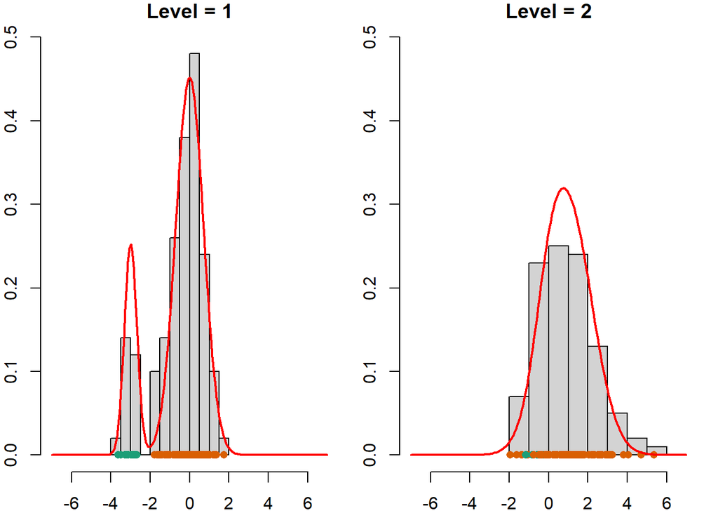

```r
idx_start = 1
idx_end = n_j[1]
xrange = c(-7,7)
l_grid = 200
grid = seq(xrange[1],xrange[2],length.out = l_grid)


par(mfrow = c(1,d), mar = c(2,2,1,1), bty = "l")
for(j in 1:d){
  mycol_cluster = brewer.pal(n=K, name = "Dark2")
  mycol_points  = as.factor(real_partition[idx_start:idx_end])
  levels(mycol_points) = unique(mycol_cluster)
  mycol_points = as.character(mycol_points)

  #dj = density(data[j,1:n_j[j]])

  hist(data[j,1:n_j[j]], freq = F, main = paste0("Level = ",j),
       xlim = xrange, ylim = c(0,0.5),
       nclass = "fd")

  points( x = data[j,1:n_j[j]], y = rep(0,n_j[j]),
          pch = 16, col = mycol_points)
  #lines(dj$x,dj$y, lwd = 2)
  points(grid, GDFMM::dmix(x = grid, w_j = prob[j,], mu_vec = mu, sigma_vec = sd),
         col = "red", lwd = 2, type = "l")

  idx_start = idx_end + 1
  if(j<d){
    idx_end = idx_end + n_j[j+1]
  }
}
```

## Iperparametri $P_0$

```r
# Calcolo anche la marginale trovata con i valori di Empirical Bayes e la plotto sopra
vardata = var(as.vector(data), na.rm = T)
P0_hyparam = empirical_bayes_normalinvgamma(data = data )

mu0 = P0_hyparam$mu0
k0 = 0.1
#k0= P0_hyparam$k0
nu0=P0_hyparam$nu0
sigma0=P0_hyparam$sigma0

c("mu0"=mu0,"k0"=k0,"nu0"=nu0,"sigma0"=sigma0)
```

```
#>       mu0        k0       nu0    sigma0
#> 0.2201906 0.1000000 4.2345566 0.4040892
```

```r
scale = sqrt( (k0 + 1)/(k0) * sigma0 )
mean_marginal = mu0
var_marginal  = nu0/(nu0-2) * scale^2

mean_marginal
```

```
#> [1] 0.2201906
```

```r
var_marginal
```

```
#> [1] 8.423383
```

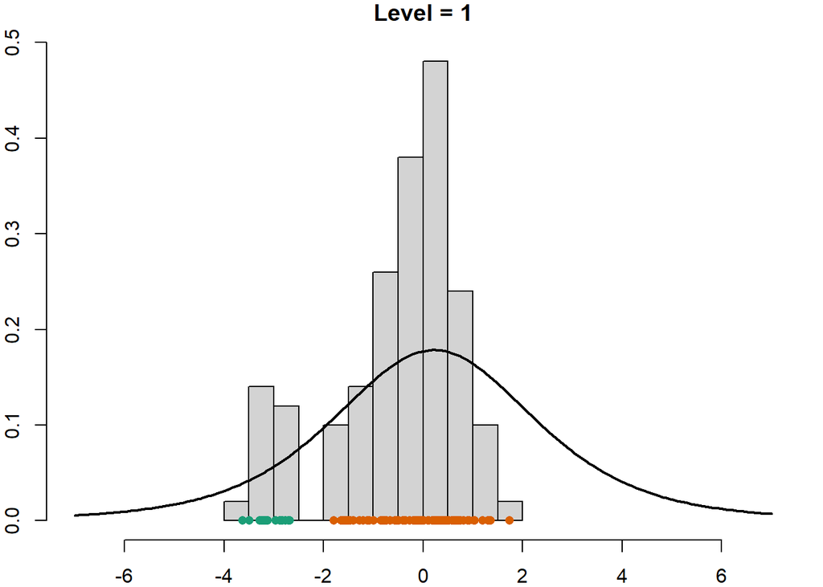

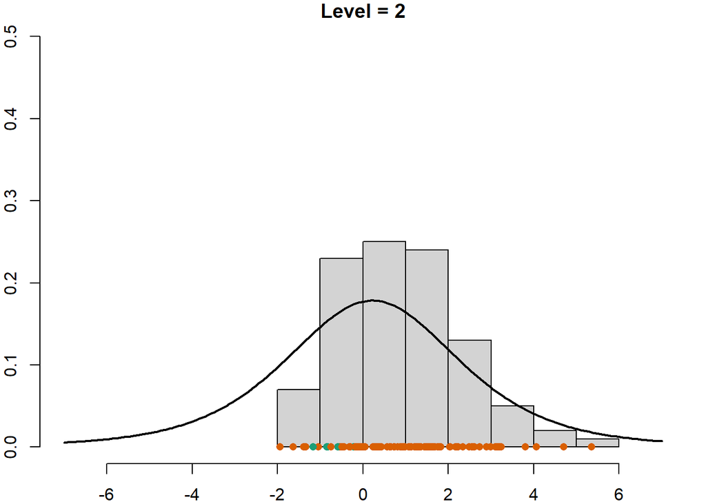

```r
xrange = c(-7,7)
l_grid = 200
grid = seq(xrange[1],xrange[2],length.out = l_grid)
# In questo plot sotto colori i pallini secondo il vero cluster.
idx_start = 1
idx_end = n_j[1]

Prior_grid = GDFMM:::dnct(x = grid, n0 = nu0, mu0 = mu0, gamma0 = scale)

for(j in 1:d){
  mycol_cluster = brewer.pal(n=K, name = "Dark2")
  mycol_points  = as.factor(real_partition[idx_start:idx_end])
  levels(mycol_points) = unique(mycol_cluster)
  mycol_points = as.character(mycol_points)

  par(mar = c(2,2,1,1), bty = "l")
  hist(data[j,1:n_j[j]], freq = F, main = paste0("Level = ",j),
       xlim = xrange, ylim = c(0,0.5),
       nclass = "fd")

  points( x = data[j,1:n_j[j]], y = rep(0,n_j[j]),
          pch = 16, col = mycol_points)
  points(grid, Prior_grid, col = "black", lwd = 2, type = "l")


  idx_start = idx_end + 1
  if(j<d){
    idx_end = idx_end + n_j[j+1]
  }
}
```

### Marginali nei cluster

Fissato il valore degli iperparametri, voglio visualizzare non solo la marginale dei dati ma anche le marginali nei cluster

Calcolo media e varianza nei cluster

```r
counter = 1
data_per_cluster = vector("list", length = K)
log_marginal_prior = vector("list", length = d)
for(j in 1:d){
  log_marginal_prior[[j]] = vector( length = n_j[j])
  for(i in 1:n_j[j]){
    c_ji = real_partition[counter]
    data_per_cluster[[c_ji]] = c(data_per_cluster[[c_ji]], data[j,i])
    log_marginal_prior[[j]][i] = log(ACutils::dnct(data[j,i], n0 = 10, mu0 = 1, gamma0 = sqrt(2)) )
    counter = counter + 1
  }

}
#data_per_cluster
mean_data_per_cluster = unlist(lapply(data_per_cluster, mean))
mean_data_per_cluster
```

```
#> [1] -3.0787398 -0.1037065  1.0407009
```

```r
var_data_per_cluster  = unlist(lapply(data_per_cluster, var))
var_data_per_cluster
```

```
#> [1] 0.08374875 0.57924380 1.93534764
```

```r
ndata_per_cluster = unlist(lapply(data_per_cluster, length))
ndata_per_cluster
```

```
#> [1] 14 93 93
```

```r
#log_marginal_prior
```

```r
dof_post = nu0 + ndata_per_cluster
k0_post  = k0 + ndata_per_cluster
location_post = (k0*mu0 + mean_data_per_cluster*ndata_per_cluster)/(k0 + ndata_per_cluster)
sigma0_post   = 1/dof_post*( (ndata_per_cluster - 1)*var_data_per_cluster +
                              nu0*sigma0 +
                              (k0*ndata_per_cluster)/(k0 + ndata_per_cluster) * (mu0 - mean_data_per_cluster)^2
                           )

scale_post = sqrt( (sigma0_post*(k0_post + 1))/(k0_post)  )

mean_marginal_per_cluster = location_post
var_marginal_per_cluster = scale_post^2 * (dof_post)/(dof_post - 2)

mean_marginal_per_cluster
```

```
#> [1] -3.0553432 -0.1033586  1.0398196
```

```r
var_marginal_per_cluster
```

```
#> [1] 0.2559760 0.5838526 1.9085714
```

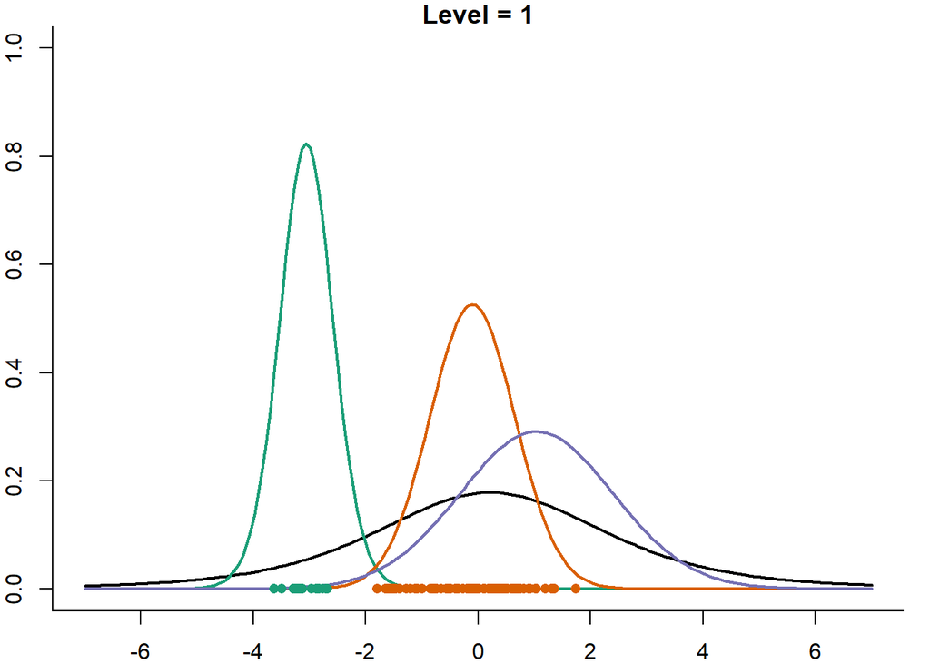

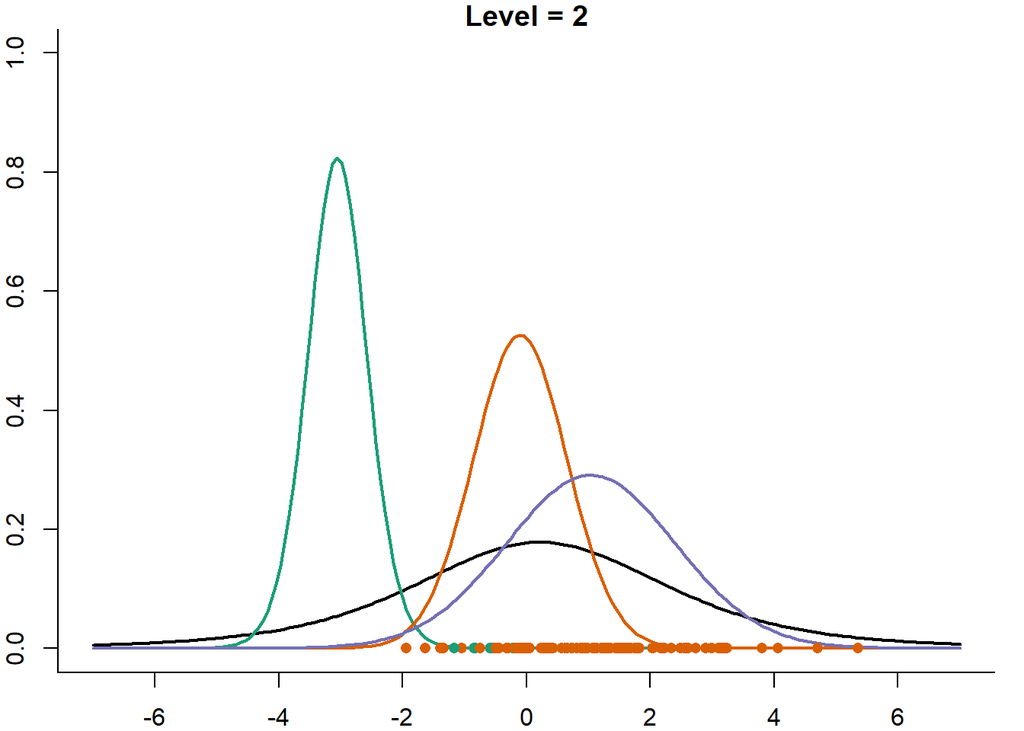

```r
xrange = c(-7,7)
l_grid = 200
grid = seq(xrange[1],xrange[2],length.out = l_grid)
idx_start = 1
idx_end = n_j[1]

Prior_grid = GDFMM:::dnct(x = grid, n0 = nu0, mu0 = mu0, gamma0 = scale)



for(j in 1:d){
  mycol_cluster = brewer.pal(n=K, name = "Dark2")
  mycol_points  = as.factor(real_partition[idx_start:idx_end])
  levels(mycol_points) = unique(mycol_cluster)
  mycol_points = as.character(mycol_points)

  par(mar = c(2,2,1,1), bty = "l")
  plot(grid, Prior_grid, col = "black", lwd = 2, type = "l",
          main = paste0("Level = ",j),
          xlim = xrange, ylim = c(0,1))

  for(kk in 1:K){
    Marginal_per_cluster_grid = GDFMM:::dnct(x = grid,
                                         n0 = dof_post[kk],
                                         mu0 = location_post[kk],
                                         gamma0 = scale_post[kk])

    points(grid, Marginal_per_cluster_grid, col = mycol_cluster[kk], lwd = 2, type = "l")

  }
  points( x = data[j,1:n_j[j]], y = rep(0,n_j[j]),
          pch = 16, col = mycol_points )

  idx_start = idx_end + 1
  if(j<d){
    idx_end = idx_end + n_j[j+1]
  }
}
```

## Run

```r
# Run  --------------------------------------------------------------------
niter  <-  10000
burnin <-  6000
thin   <-  1

# tau
a_gamma <-   1; b_gamma  <- 1
a_lambda <- 10; b_lambda <- 2

option = set_options_marginal(
             "mu0" = mu0,"sigma0"= sigma0, "k0"= k0, "nu0"=nu0,
             "Adapt_MH_hyp1"= 0.7,"Adapt_MH_hyp2"= 0.234,
             "sp_mala_U" = 0.01, "sp_mala_gamma"=0.01,
             "gamma0" = 3,"Lambda0" = 10,
             "alpha_gamma"=a_gamma, "beta_gamma"=b_gamma,
             "alpha_lambda"=a_lambda, "beta_lambda"=b_lambda,
             "init_mean_cluster" = NULL,#unlist(mean_data_per_cluster),
             "init_var_cluster" = NULL,#unlist(var_data_per_cluster),
             "UpdateU" = T, "UpdateGamma" = T, "UpdateTau" = T, "UpdateLambda" = T,
             "partition" = real_partition#seq(1,sum(n_j))
        )

# P0 Hyperparameters:
# old set: "mu0" = 0,"sigma0"= 1, "k0"= 1/10, "nu0"=10,
# new set: "mu0" = P0_hyparam$mu0, "k0"= P0_hyparam$k0, "nu0"=P0_hyparam$nu0, "sigma0"= P0_hyparam$sigma0,

# Process parameters
# old set:  "gamma0" = 1,"Lambda0" = 3,
#           "alpha_gamma"=5, "beta_gamma"=0.5, "alpha_lambda"=1, "beta_lambda"=5,


#GDFMM = GDFMM_sampler(data, niter, burnin, thin, seed = 123, option = option)
GDFMM = GDFMM_marginal_sampler(data, niter, burnin, thin, seed = 123, FixPartition = F, option = option)
```

```
#>
#>  Check that provided partition is well formed. It must start from 0 and all values must be contiguous
#> GibbsSamplerMarginal.cpp - Initialization
#> initialize_Partition with non empty partition_vec
#>  (K, Mstar, M) = (3,0,3)
#> DEVO CAMBIARE LA STRUTTURA DEI INPUT DEI DATI COME HA FATTO VEDERE BARTOLUCCI
```

### Chains

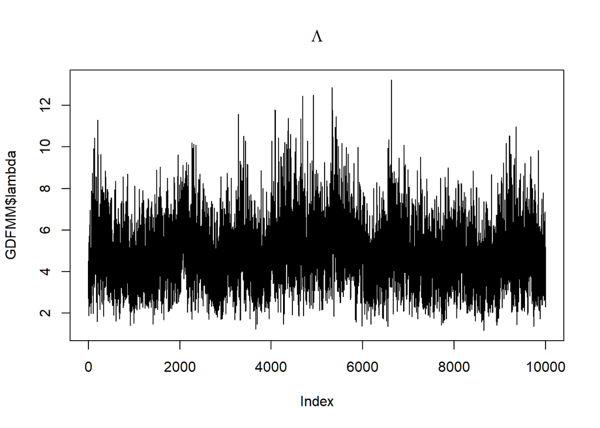

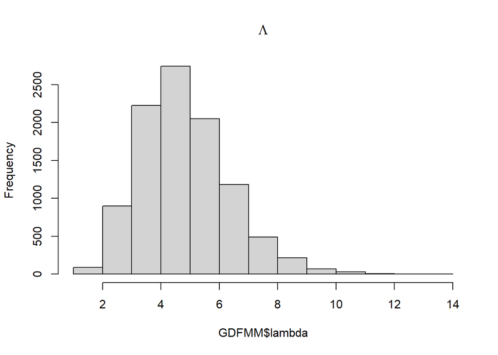

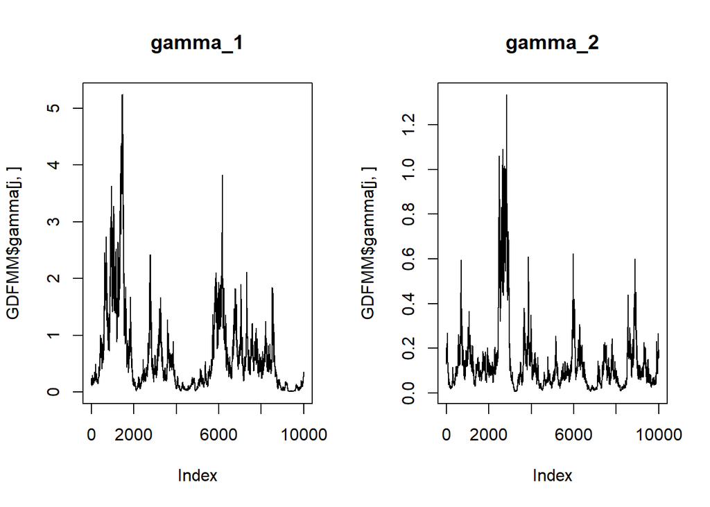

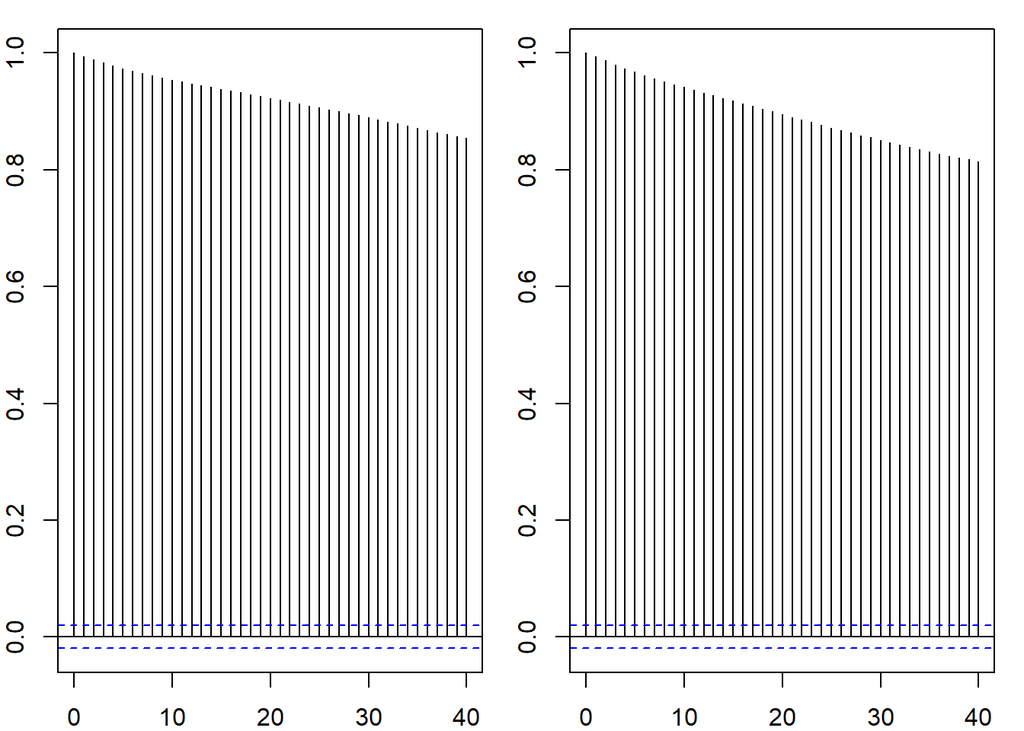

```
#> [1] 0.09787115
```

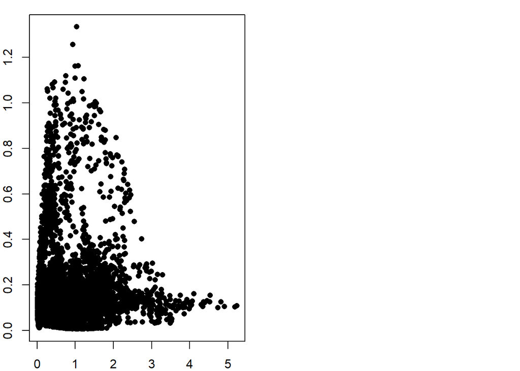

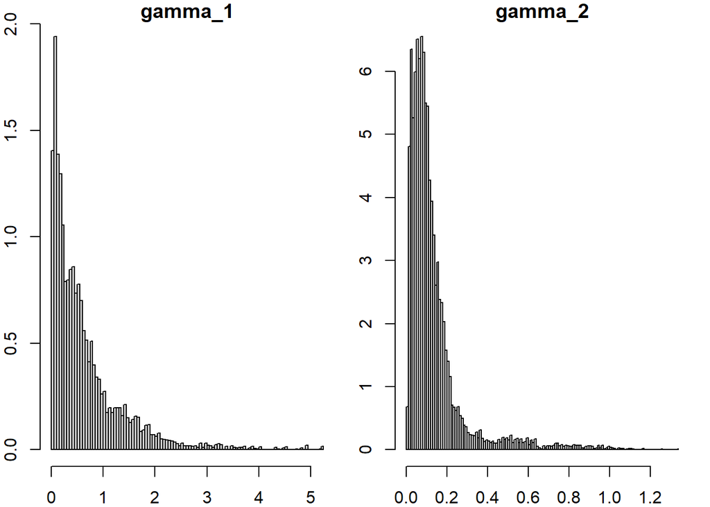

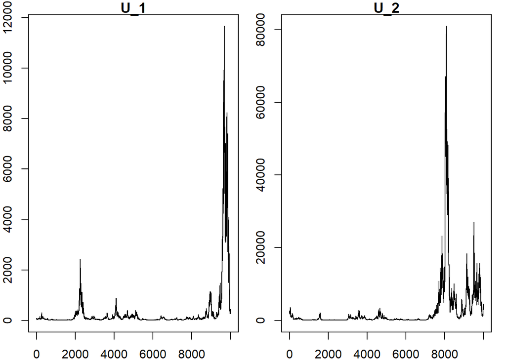

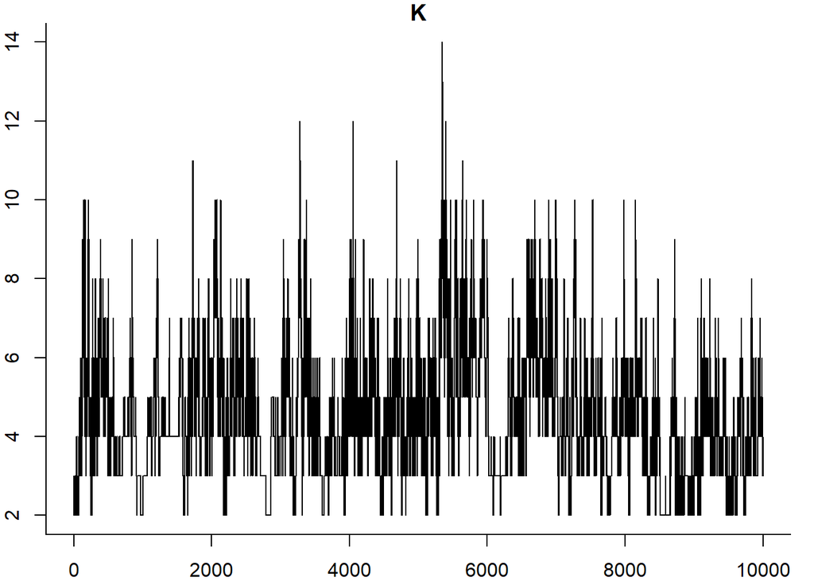

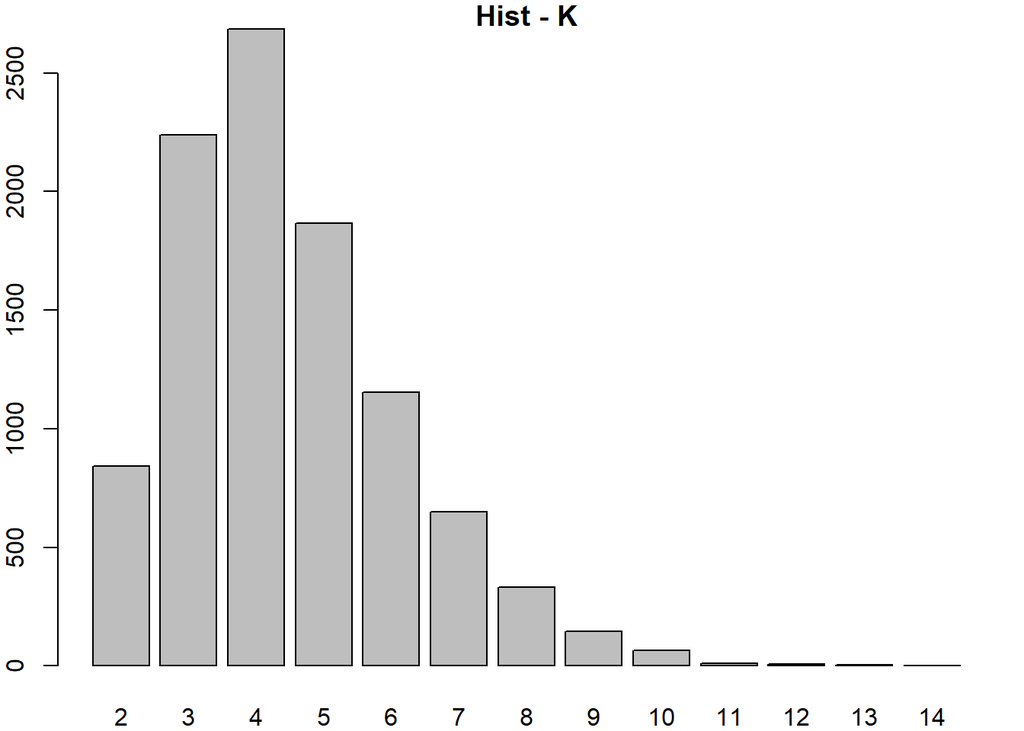

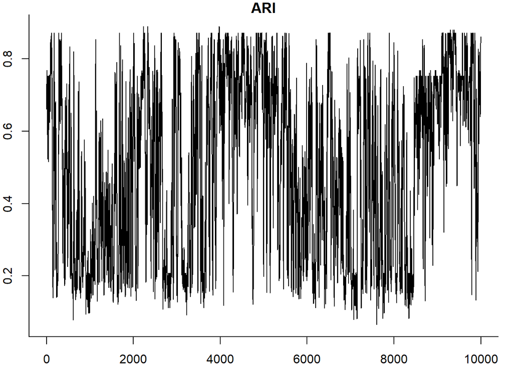

### Clustering

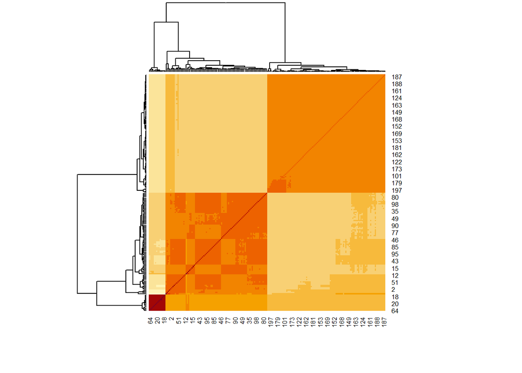

```r
# COMPUTE BINDER LOSS FUNCTION TO SELECT BEST PARTITION

# Get labels for each iterations for each data point
part_matrix <- GDFMM$Partition #GDFMM$Partition is a (n_iter x n_data) matrix

# Compute similarity matrix
sim_matrix <- psm(part_matrix)


heatmap(sim_matrix)
```

```r
binder_sara = minbinder(sim_matrix)
VI_sara = minVI(sim_matrix)

table(binder_sara$cl)
```

```
#>
#>   1   2   3
#>  86  14 100
```

```r
table(VI_sara$cl)
```

```
#>
#>   1   2   3
#>  86  14 100
```

```r
table(real_partition)
```

```
#> real_partition
#>  1  2  3
#> 14 93 93
```

```r
arandi(binder_sara$cl,real_partition)
```

```
#> [1] 0.8719571
```

```r
arandi(VI_sara$cl,real_partition)
```

```
#> [1] 0.8719571
```

### Density estimation

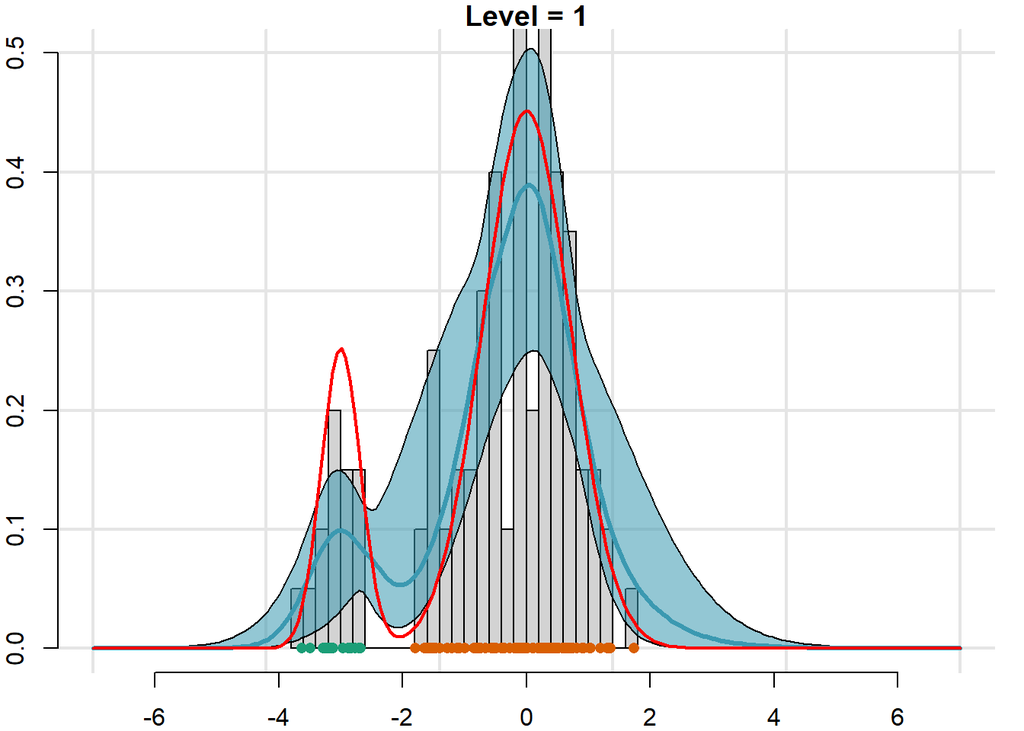

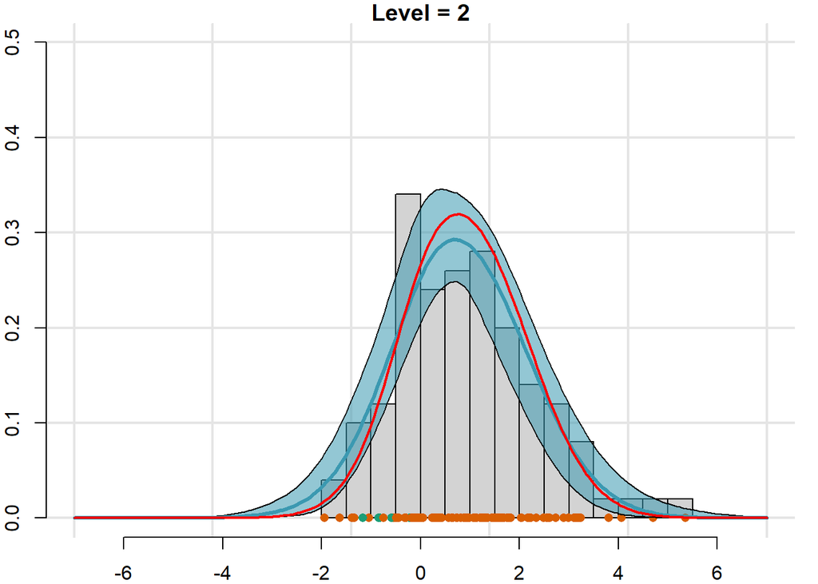

```r
xrange = c(-7,7)
l_grid = 200
grid = seq(xrange[1],xrange[2],length.out = l_grid)
# Predictive in all groups
Pred_all = predictive_marginal_all_groups(grid = grid, fit = GDFMM, burnin = 0, option = option)

# In questo plot sotto colori i pallini secondo il vero cluster.
idx_start = 1
idx_end = n_j[1]


#par(mfrow = c(1,d), mar = c(2,2,1,1))
par(mar = c(2,2,1,1), bty = "l")
for(j in 1:d){

  # set colors
  mycol_cluster = brewer.pal(n=K, name = "Dark2")
  mycol_points  = as.factor(real_partition[idx_start:idx_end])
  levels(mycol_points) = unique(mycol_cluster)
  mycol_points = as.character(mycol_points)


  # frequentist density
  dj = density(data[j,1:n_j[j]])
  yrange = range(Pred_all[[j]][3,]) + 0.001*max(Pred_all[[j]][3,])

  # Trick to add the grid below the plot
  plot.new()
  grid(lty = 1,lwd = 2,col = "gray90" )
  par(new = TRUE)

  # plot
  hist(data[j,1:n_j[j]], freq = F, breaks = n_j[j]/5,
       main = paste0("Level = ",j),
       ylim = c(0,0.5), xlim = xrange,
       ylab = "y-axis", xlab = "x-axis")
  points( x = data[j,1:n_j[j]], y = rep(0,n_j[j]),
          pch = 16, col = mycol_points)
  #lines(dj$x,dj$y, lwd = 3)
  #lines(x = grid, y = Pred_all[[j]][1,], col = "blue", lwd = 2, lty = 2) #0.025
  #lines(x = grid, y = Pred_all[[j]][3,], col = "blue", lwd = 2, lty = 2) #0.975
  polygon( c(grid, rev(grid)),
           c(Pred_all[[j]][1,], rev(Pred_all[[j]][3,])),
           col = ACutils::t_col(mycol[1], percent = 45))
  lines(x = grid, y = Pred_all[[j]][2,], col = mycol[1], lwd = 3) #0.5

  points(grid, dmix(x = grid, w_j = prob[j,], mu_vec = mu, sigma_vec = sd),
         col = "red", lwd = 2, type = "l")

  idx_start = idx_end + 1
    if(j<d){
    idx_end = idx_end + n_j[j+1]
  }
}
```

## Indexes

Compute the co-clustering errors

$$\text{CN} = \frac{1}{n} \sum_{l=1}^n\sum_{k=1}^n \ \lvert \ \pi_{lk} -
\hat{\pi}_{lk} \ \rvert$$
and the co-clustering errors star

$$\text{CN}^* = \frac{1}{n} \sum_{l=1}^n\sum_{k=1}^n \ \lvert \ \pi_{lk} -
\mathbb{I}(\hat{\pi}_{lk}>0.5) \ \rvert$$

where $\hat{\pi}_{lk}$ is the element $l,k$ of the posterior similarity matrix and $\pi_{lk}\in\{0,1\}$ is equal to 1 if $y_l$ and $y_k$ belong to the same cluster, 0 otherwise.

```r
Compute_coclust_error(real_partition, sim_matrix)
```

```
#> $coclust_err
#> [1] 0.250813
#>
#> $coclust_err_star
#> [1] 0.06525
```

Compute the $L_1$ distance

$$SC = \frac{1}{d}\ \sum_{j=1}^{d} \ \int \ \lvert f(Y_{j,n_j+1}) -
\hat{f}(Y_{j,n_j+1}\mid \mathbf{Y}) \rvert \ dY_{j,n_j+1} \$$

```r
Pred_median = vector("list", length = d)
for(j in 1:d){
  Pred_median[[j]] = Pred_all[[j]][2,]
}

Compute_L1_dist(Pred = Pred_median,
                p_mix = prob, mu = mu, sigma = sd,
                grid = grid)
```

```
#> $L1err_per_level
#> [1] 0.2827243 0.1106506
#>
#> $L1err_average
#> [1] 0.1966875
```

Casarin calcola anche mediana e varianza della catena del numero di cluster

```r
median(GDFMM$K)
```

```
#> [1] 4
```

```r
var(GDFMM$K)
```

```
#> [1] 2.836767
```

# 2 - Tests

## Iperparametri $P_0$

```r
# Calcolo anche la marginale trovata con i valori di Empirical Bayes e la plotto sopra
vardata = var(as.vector(data), na.rm = T)
P0_hyparam = empirical_bayes_normalinvgamma(data = data, varmu = 100, correction = 3, varsig2 = vardata  )

mu0 = P0_hyparam$mu0
k0= P0_hyparam$k0
nu0=P0_hyparam$nu0
sigma0=P0_hyparam$sigma0

c("mu0"=mu0,"k0"=k0,"nu0"=nu0,"sigma0"=sigma0)
```

```
#>         mu0          k0         nu0      sigma0
#> 0.220190638 0.007657621 4.510508049 0.426216255
```

```r
scale = sqrt( (k0 + 1)/(k0) * sigma0 )
mean_marginal = mu0
var_marginal  = nu0/(nu0-2) * scale^2

mean_marginal
```

```
#> [1] 0.2201906
```

```r
var_marginal
```

```
#> [1] 100.7658
```

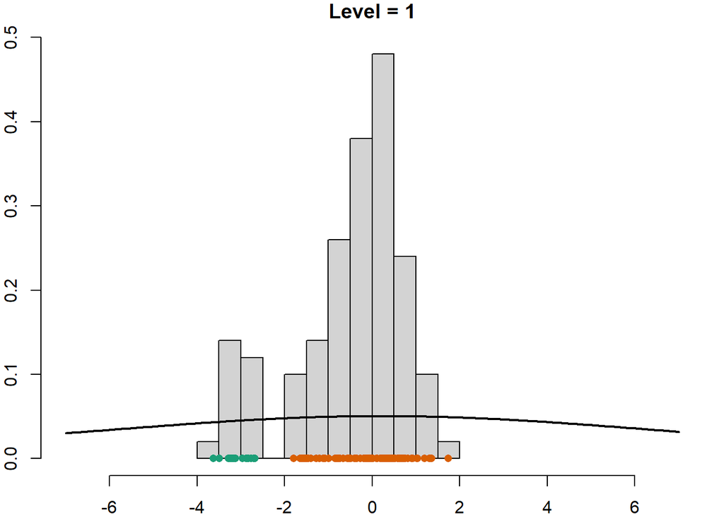

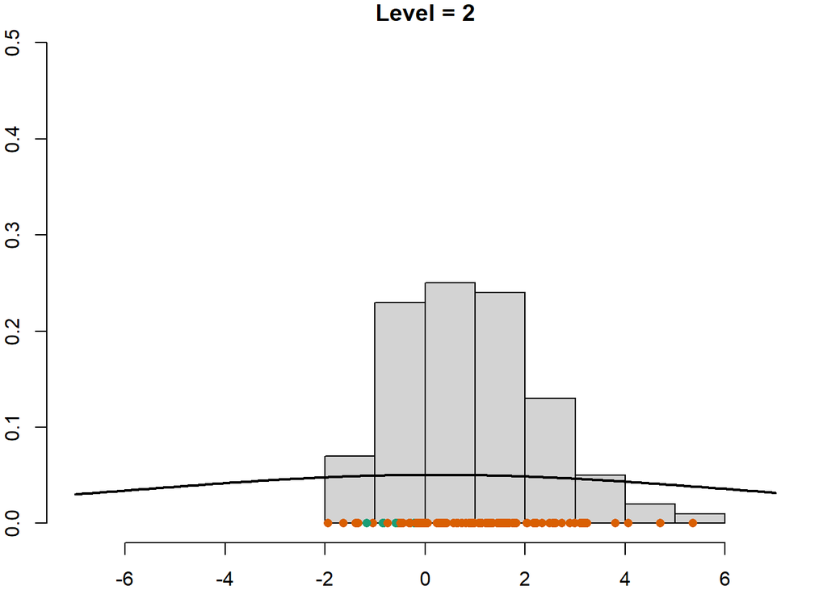

```r
xrange = c(-7,7)
l_grid = 200
grid = seq(xrange[1],xrange[2],length.out = l_grid)
# In questo plot sotto colori i pallini secondo il vero cluster.
idx_start = 1
idx_end = n_j[1]

Prior_grid = GDFMM:::dnct(x = grid, n0 = nu0, mu0 = mu0, gamma0 = scale)

for(j in 1:d){
  mycol_cluster = brewer.pal(n=K, name = "Dark2")
  mycol_points  = as.factor(real_partition[idx_start:idx_end])
  levels(mycol_points) = unique(mycol_cluster)
  mycol_points = as.character(mycol_points)

  par(mar = c(2,2,1,1), bty = "l")
  hist(data[j,1:n_j[j]], freq = F, main = paste0("Level = ",j),
       xlim = xrange, ylim = c(0,0.5),
       nclass = "fd")

  points( x = data[j,1:n_j[j]], y = rep(0,n_j[j]),
          pch = 16, col = mycol_points)
  points(grid, Prior_grid, col = "black", lwd = 2, type = "l")


  idx_start = idx_end + 1
  if(j<d){
    idx_end = idx_end + n_j[j+1]
  }
}
```

### Marginali nei cluster

Fissato il valore degli iperparametri, voglio visualizzare non solo la marginale dei dati ma anche le marginali nei cluster

Calcolo media e varianza nei cluster

```r
counter = 1
data_per_cluster = vector("list", length = K)
log_marginal_prior = vector("list", length = d)
for(j in 1:d){
  log_marginal_prior[[j]] = vector( length = n_j[j])
  for(i in 1:n_j[j]){
    c_ji = real_partition[counter]
    data_per_cluster[[c_ji]] = c(data_per_cluster[[c_ji]], data[j,i])
    log_marginal_prior[[j]][i] = log(ACutils::dnct(data[j,i], n0 = 10, mu0 = 1, gamma0 = sqrt(2)) )
    counter = counter + 1
  }

}
#data_per_cluster
mean_data_per_cluster = unlist(lapply(data_per_cluster, mean))
mean_data_per_cluster
```

```
#> [1] -3.0787398 -0.1037065  1.0407009
```

```r
var_data_per_cluster  = unlist(lapply(data_per_cluster, var))
var_data_per_cluster
```

```
#> [1] 0.08374875 0.57924380 1.93534764
```

```r
ndata_per_cluster = unlist(lapply(data_per_cluster, length))
ndata_per_cluster
```

```
#> [1] 14 93 93
```

```r
#log_marginal_prior
```

```r
dof_post = nu0 + ndata_per_cluster
k0_post  = k0 + ndata_per_cluster
location_post = (k0*mu0 + mean_data_per_cluster*ndata_per_cluster)/(k0 + ndata_per_cluster)
sigma0_post   = 1/dof_post*( (ndata_per_cluster - 1)*var_data_per_cluster +
                              nu0*sigma0 +
                              (k0*ndata_per_cluster)/(k0 + ndata_per_cluster) * (mu0 - mean_data_per_cluster)^2
                           )

scale_post = sqrt( (sigma0_post*(k0_post + 1))/(k0_post)  )

mean_marginal_per_cluster = location_post
var_marginal_per_cluster = scale_post^2 * (dof_post)/(dof_post - 2)

mean_marginal_per_cluster
```

```
#> [1] -3.0769364 -0.1036798  1.0406334
```

```r
var_marginal_per_cluster
```

```
#> [1] 0.2008049 0.5843057 1.9046563
```

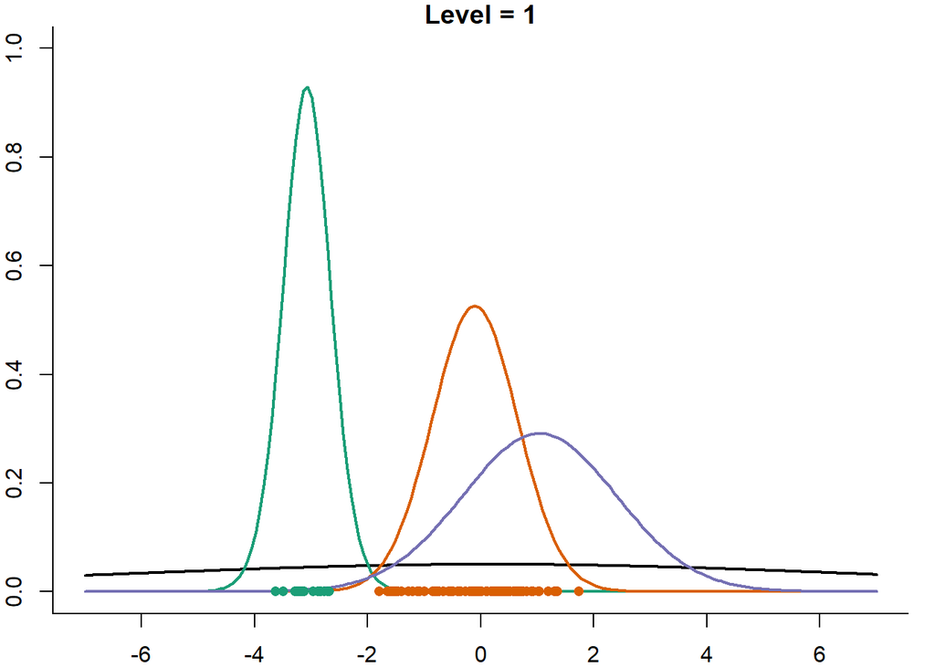

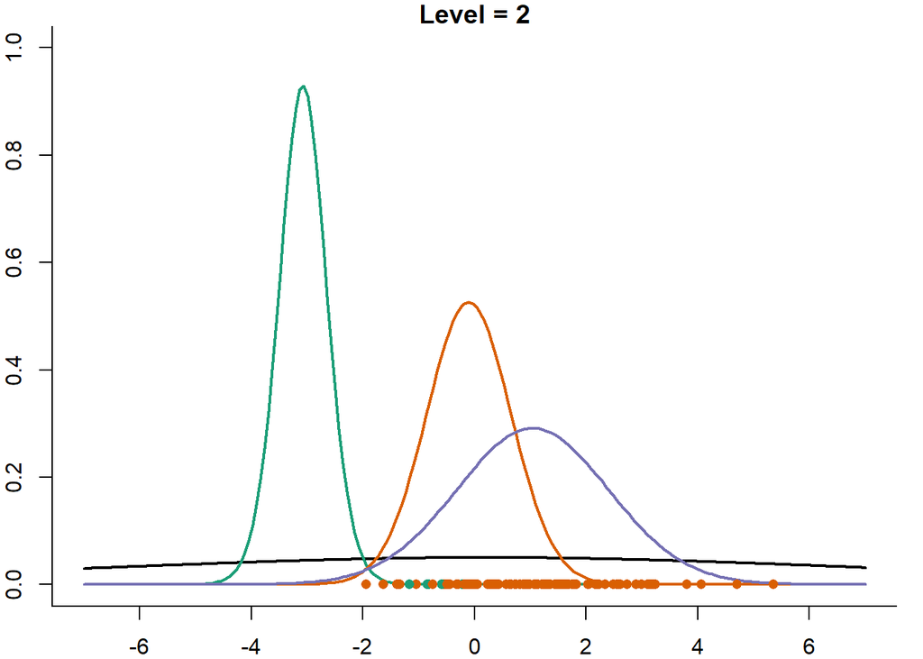

```r
xrange = c(-7,7)
l_grid = 200
grid = seq(xrange[1],xrange[2],length.out = l_grid)
idx_start = 1
idx_end = n_j[1]

Prior_grid = GDFMM:::dnct(x = grid, n0 = nu0, mu0 = mu0, gamma0 = scale)



for(j in 1:d){
  mycol_cluster = brewer.pal(n=K, name = "Dark2")
  mycol_points  = as.factor(real_partition[idx_start:idx_end])
  levels(mycol_points) = unique(mycol_cluster)
  mycol_points = as.character(mycol_points)

  par(mar = c(2,2,1,1), bty = "l")
  plot(grid, Prior_grid, col = "black", lwd = 2, type = "l",
          main = paste0("Level = ",j),
          xlim = xrange, ylim = c(0,1))

  for(kk in 1:K){
    Marginal_per_cluster_grid = GDFMM:::dnct(x = grid,
                                         n0 = dof_post[kk],
                                         mu0 = location_post[kk],
                                         gamma0 = scale_post[kk])

    points(grid, Marginal_per_cluster_grid, col = mycol_cluster[kk], lwd = 2, type = "l")

  }
  points( x = data[j,1:n_j[j]], y = rep(0,n_j[j]),
          pch = 16, col = mycol_points )

  idx_start = idx_end + 1
  if(j<d){
    idx_end = idx_end + n_j[j+1]
  }
}
```

## Run

```r
# Run  --------------------------------------------------------------------
niter  <-  10000
burnin <-   6000
thin   <-  1

# tau
a_gamma <-   1; b_gamma  <- 100

# Lambda hyperparameters
mu_lambda  = 3
var_lambda = 1
a_lambda = (mu_lambda*mu_lambda)/var_lambda
b_lambda = mu_lambda/(var_lambda)
#a_lambda <- 10; b_lambda <- 2

option = set_options_marginal(
             "mu0" = mu0,"sigma0"= sigma0, "k0"= k0, "nu0"=nu0,
             "Adapt_MH_hyp1"= 0.7,"Adapt_MH_hyp2"= 0.234,
             "sp_mala_U" = 0.01, "sp_mala_gamma"=0.01,
             "gamma0" = 3,"Lambda0" = mu_lambda,
             "alpha_gamma"=a_gamma, "beta_gamma"=b_gamma,
             "alpha_lambda"=a_lambda, "beta_lambda"=b_lambda,
             "init_mean_cluster" = NULL,#unlist(mean_data_per_cluster),
             "init_var_cluster" = NULL,#unlist(var_data_per_cluster),
             "UpdateU" = T, "UpdateGamma" = T, "UpdateTau" = T, "UpdateLambda" = T,
             "partition" = seq(1,sum(n_j))#real_partition
        )

# P0 Hyperparameters:
# old set: "mu0" = 0,"sigma0"= 1, "k0"= 1/10, "nu0"=10,
# new set: "mu0" = P0_hyparam$mu0, "k0"= P0_hyparam$k0, "nu0"=P0_hyparam$nu0, "sigma0"= P0_hyparam$sigma0,

# Process parameters
# old set:  "gamma0" = 1,"Lambda0" = 3,
#           "alpha_gamma"=5, "beta_gamma"=0.5, "alpha_lambda"=1, "beta_lambda"=5,


#GDFMM = GDFMM_sampler(data, niter, burnin, thin, seed = 123, option = option)
GDFMM = GDFMM_marginal_sampler(data, niter, burnin, thin, seed = 123, FixPartition = F, option = option)
```

```
#>
#>  Check that provided partition is well formed. It must start from 0 and all values must be contiguous
#> GibbsSamplerMarginal.cpp - Initialization
#> initialize_Partition with non empty partition_vec
#>  (K, Mstar, M) = (200,0,200)
#> DEVO CAMBIARE LA STRUTTURA DEI INPUT DEI DATI COME HA FATTO VEDERE BARTOLUCCI
```

### Chains

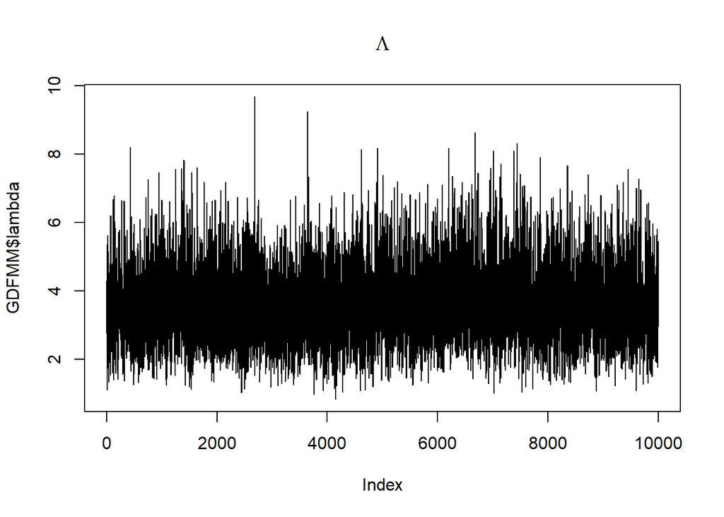

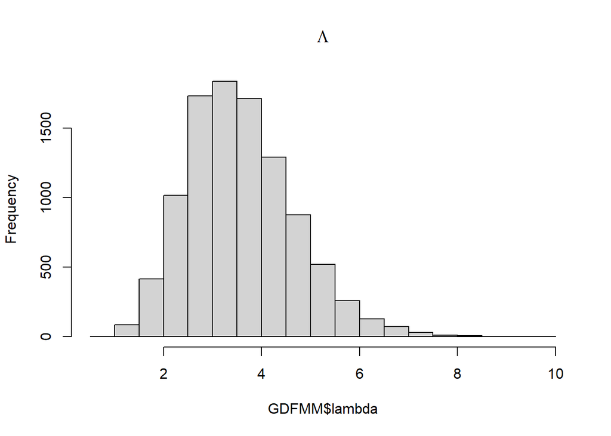

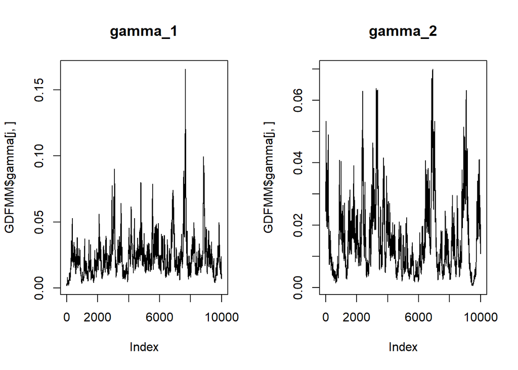

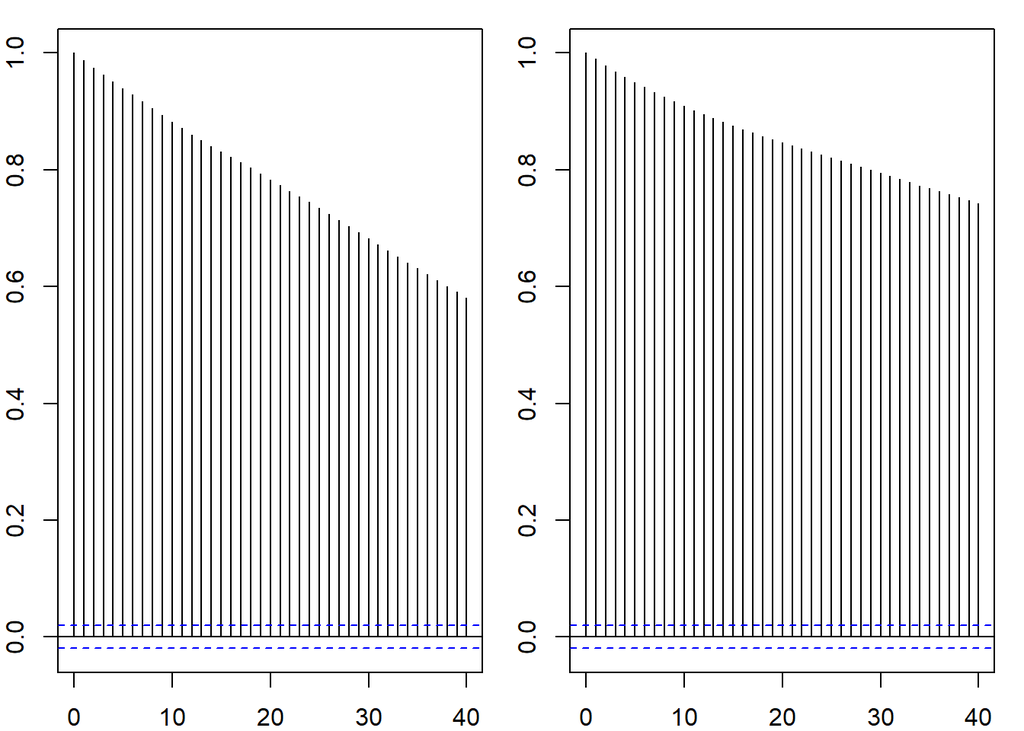

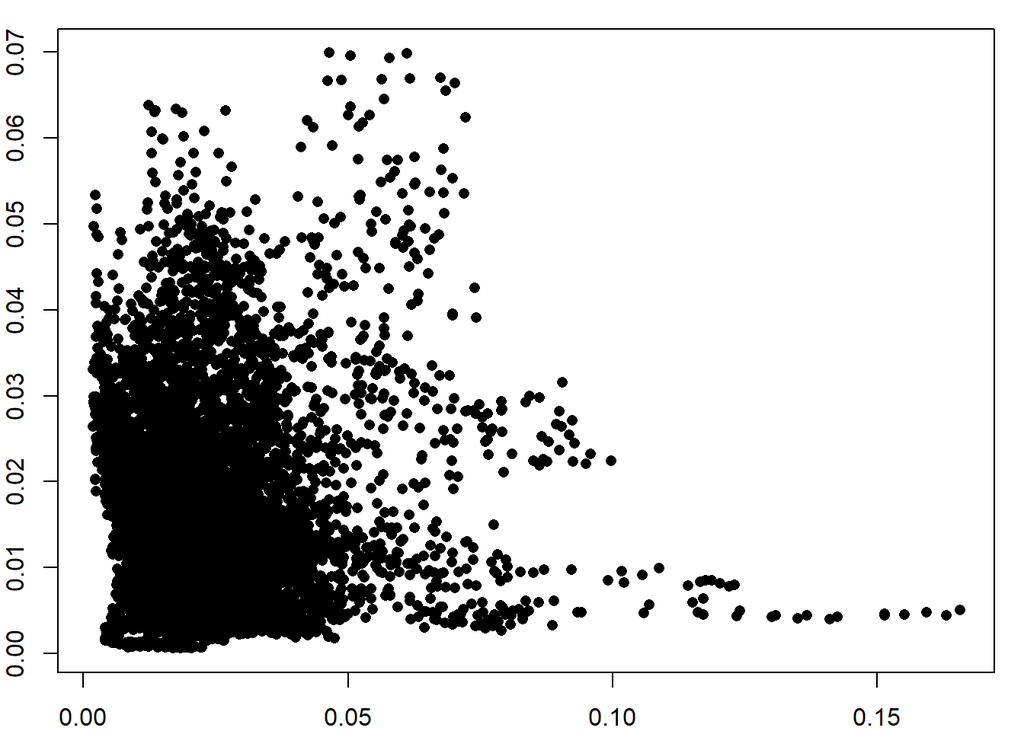

```
#> [1] 0.06818456
```

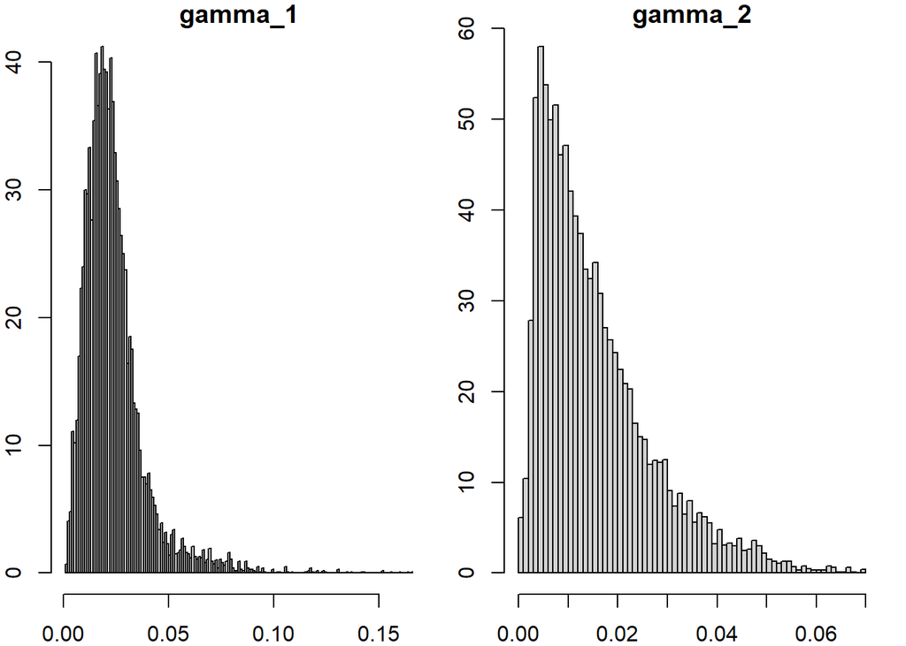

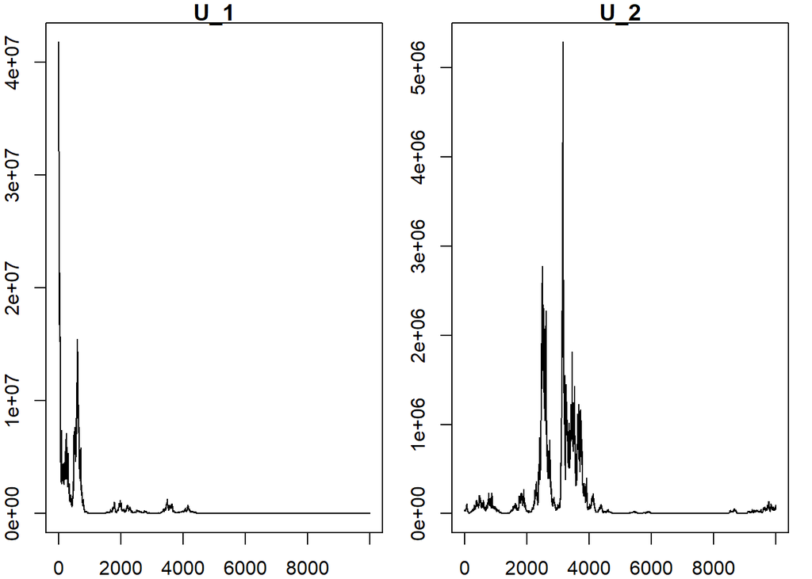

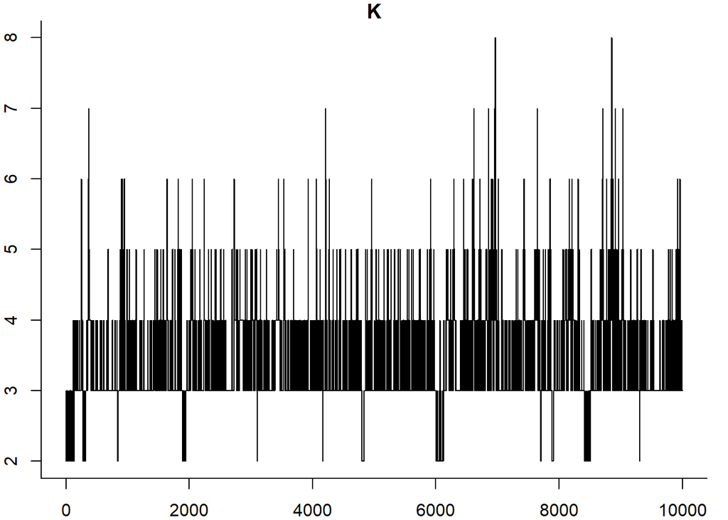

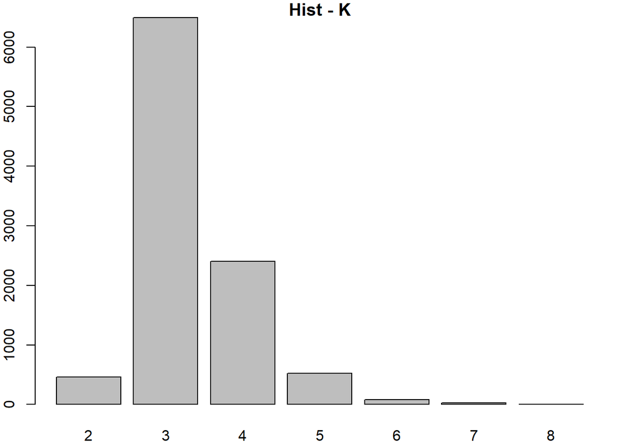

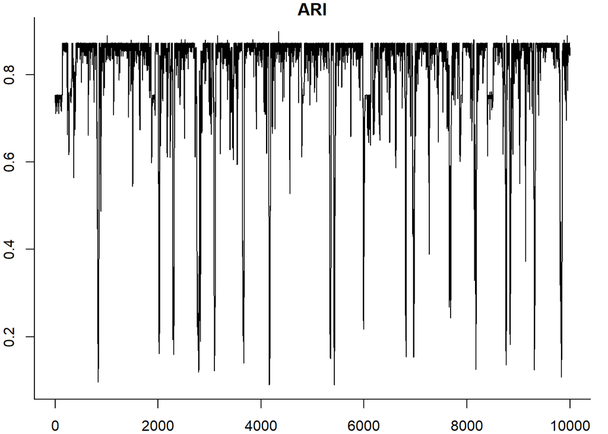

### Clustering

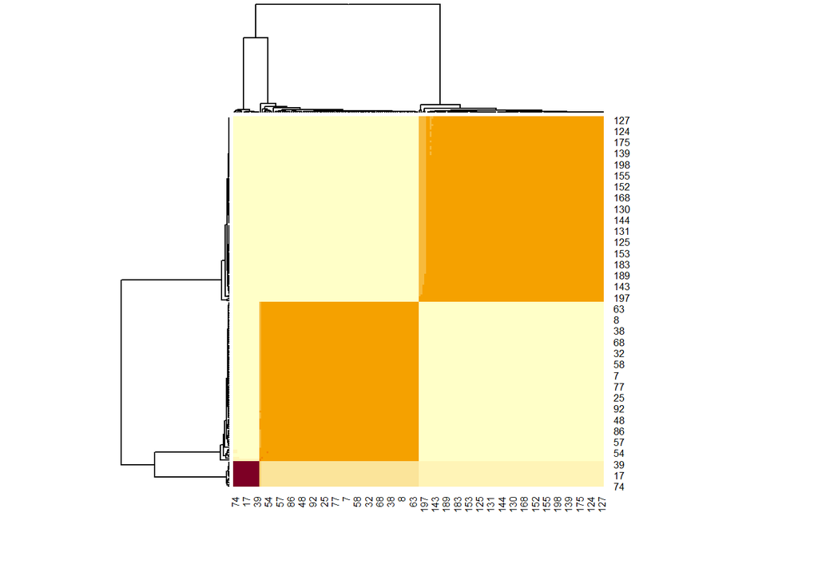

```r
# COMPUTE BINDER LOSS FUNCTION TO SELECT BEST PARTITION

# Get labels for each iterations for each data point
part_matrix <- GDFMM$Partition #GDFMM$Partition is a (n_iter x n_data) matrix

# Compute similarity matrix
sim_matrix <- psm(part_matrix)


heatmap(sim_matrix)
```

```r
binder_sara = minbinder(sim_matrix)
VI_sara = minVI(sim_matrix)

table(binder_sara$cl)
```

```
#>
#>   1   2   3
#>  86  14 100
```

```r
table(VI_sara$cl)
```

```
#>
#>   1   2   3
#>  86  14 100
```

```r
table(real_partition)
```

```
#> real_partition
#>  1  2  3
#> 14 93 93
```

```r
arandi(binder_sara$cl,real_partition)
```

```
#> [1] 0.8719571
```

```r
arandi(VI_sara$cl,real_partition)
```

```
#> [1] 0.8719571
```

### Density estimation

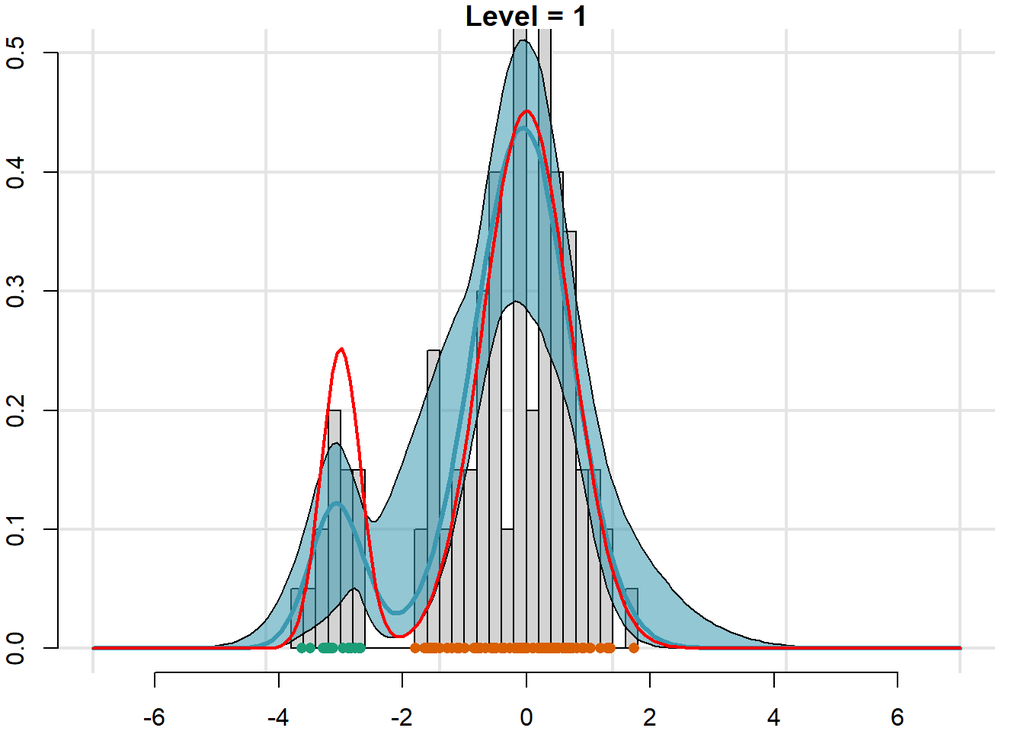

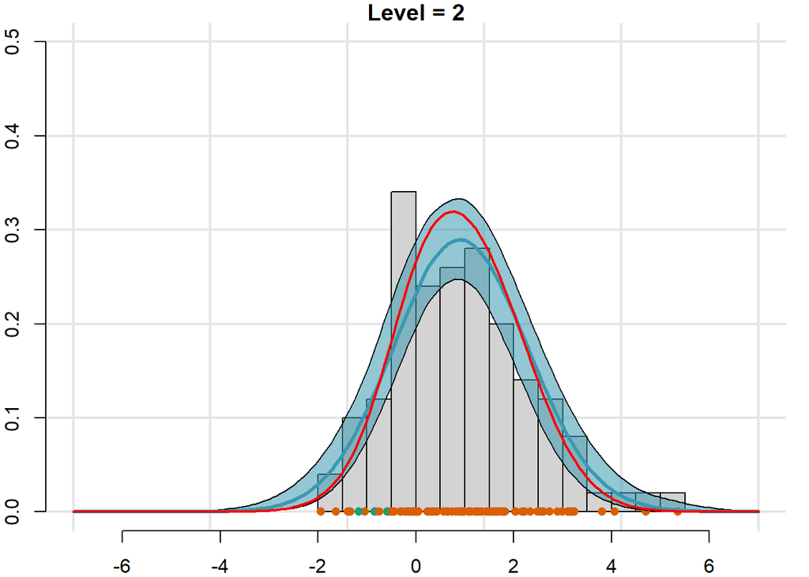

```r
xrange = c(-7,7)
l_grid = 200
grid = seq(xrange[1],xrange[2],length.out = l_grid)
# Predictive in all groups
Pred_all = predictive_marginal_all_groups(grid = grid, fit = GDFMM, burnin = 0, option = option)

# In questo plot sotto colori i pallini secondo il vero cluster.
idx_start = 1
idx_end = n_j[1]


#par(mfrow = c(1,d), mar = c(2,2,1,1))
par(mar = c(2,2,1,1), bty = "l")
for(j in 1:d){

  # set colors
  mycol_cluster = brewer.pal(n=K, name = "Dark2")
  mycol_points  = as.factor(real_partition[idx_start:idx_end])
  levels(mycol_points) = unique(mycol_cluster)
  mycol_points = as.character(mycol_points)


  # frequentist density
  dj = density(data[j,1:n_j[j]])
  yrange = range(Pred_all[[j]][3,]) + 0.001*max(Pred_all[[j]][3,])

  # Trick to add the grid below the plot
  plot.new()
  grid(lty = 1,lwd = 2,col = "gray90" )
  par(new = TRUE)

  # plot
  hist(data[j,1:n_j[j]], freq = F, breaks = n_j[j]/5,
       main = paste0("Level = ",j),
       ylim = c(0,0.5), xlim = xrange,
       ylab = "y-axis", xlab = "x-axis")
  points( x = data[j,1:n_j[j]], y = rep(0,n_j[j]),
          pch = 16, col = mycol_points)
  #lines(dj$x,dj$y, lwd = 3)
  #lines(x = grid, y = Pred_all[[j]][1,], col = "blue", lwd = 2, lty = 2) #0.025
  #lines(x = grid, y = Pred_all[[j]][3,], col = "blue", lwd = 2, lty = 2) #0.975
  polygon( c(grid, rev(grid)),
           c(Pred_all[[j]][1,], rev(Pred_all[[j]][3,])),
           col = ACutils::t_col(mycol[1], percent = 45))
  lines(x = grid, y = Pred_all[[j]][2,], col = mycol[1], lwd = 3) #0.5

  points(grid, dmix(x = grid, w_j = prob[j,], mu_vec = mu, sigma_vec = sd),
         col = "red", lwd = 2, type = "l")

  idx_start = idx_end + 1
    if(j<d){
    idx_end = idx_end + n_j[j+1]
  }
}
```

## Indexes

```r
Compute_coclust_error(real_partition, sim_matrix)
```

```
#> $coclust_err
#> [1] 0.09562127
#>
#> $coclust_err_star
#> [1] 0.06265
```

Compute the $L_1$ distance

```r
Pred_median = vector("list", length = d)
for(j in 1:d){
  Pred_median[[j]] = Pred_all[[j]][2,]
}

Compute_L1_dist(Pred = Pred_median,
                p_mix = prob, mu = mu, sigma = sd,
                grid = grid)
```

```
#> $L1err_per_level
#> [1] 0.1758325 0.1148293
#>
#> $L1err_average
#> [1] 0.1453309
```

Casarin calcola anche mediana e varianza della catena del numero di cluster

```r
median(GDFMM$K)
```

```
#> [1] 3
```

```r
var(GDFMM$K)
```

```
#> [1] 0.5092205
```

## Commenti

- In questo esempio, più che gli iperparametri di $P_0$ mi sembra fondamentale la scelta di $\Lambda$
- $\Lambda$ alto mixxa molto ma troppi cluster
- Con $\Lambda$ centrato su 3 e varianza bassa, ho i risultati migliori
- Ho visto che quando non funziona, spesso mi ritrovo $\gamma_1$ troppo alto. Quindi ho ridotto a priori mettendo $b_\gamma=10$ e va molto meglio
- $b_\gamma=10$ compensa bene la variabilità di $\Lambda$, così va bene anche lasciando varianza 1
- $b_\gamma=100$ fa oscillare molto meno il RI
- Però mettendo $varmu = 10, correction = 3, varsig2 = vardata^2$ e $b_\gamma=1$ i risultati finale erano come quelli con $b_\gamma=1$. Quello che cambia è che l’ARI è meno ballerino, si schiaccia più verso valori alti

# 3 - Sensibility wrt $P_0$

```r
suppressWarnings(suppressPackageStartupMessages(library(GDFMM)))
suppressWarnings(suppressPackageStartupMessages(library(ACutils)))
suppressWarnings(suppressPackageStartupMessages(library(tidyverse)))
suppressWarnings(suppressPackageStartupMessages(library(RColorBrewer)))
suppressWarnings(suppressPackageStartupMessages(library(salso)))
suppressWarnings(suppressPackageStartupMessages(library(wesanderson)))
suppressWarnings(suppressPackageStartupMessages(library(mcclust.ext)))
```

## 3.1 - Experiment Setup

Inizio variando un solo parametro alla volta. Qui, vario $\bar{\text{V}}_\mu$. La variabile di riferimento è $\texttt{varmu}$.

- $\bar{V}_\mu \text{ variabile}$
- $\bar{V}_{\sigma^2} = \text{Var}(data)^2$
- $\text{c} = 3$
- $b_\gamma = 1$
- $\text{E}[\Lambda] = 3$
- $\text{Var}(\Lambda) = 1$

```r
# Data generation
d = 2               # number of groups
K = 3               # number of global clusters
mu = c(-3,0,1)      # vectors of means
sd = c(sqrt(0.1), sqrt(0.5), sqrt(1.5) )     # vector of sd
prob <- matrix(c(0.2,0.8,  0,
                   0,0.1,0.9),nrow = d, ncol = K, byrow = T)

n_j = rep(100, d)  # set cardinality of the groups
seed = 20051131

#genD = generate_data_prob(d=d,p=prob, K=K, mu = mu, sd = sd, n_j = n_j, seed = seed)
genD = simulate_data(d=d,prob=prob, K=K, mu = mu, sd = sd, n_j = n_j, seed = seed)
data = genD$data
real_partition = genD$real_partition


#table(real_partition)
#table(real_partition[1:n_j[1]])
#table(real_partition[(n_j[1]+1):(n_j[1] + n_j[2])])


mycol = hcl.colors(n=3,palette = "Zissou1")
mycol_cluster = brewer.pal(n=K, name = "Dark2")


## Common parameters
vardata = var(as.vector(data), na.rm = T)
niter  <-  10000
burnin <-  6000
thin   <-  1


a_gamma <-   1; b_gamma  <- 1
mu_lambda  = 3
var_lambda = 1
a_lambda = (mu_lambda*mu_lambda)/var_lambda
b_lambda = mu_lambda/(var_lambda)


varmu_grid = c(1,vardata,vardata^2,10,50,100)
N_varmu = length(varmu_grid)
nomi_varmu_grid = c("Vmu=1","Vmu=Vdata","Vmu=Vdata^2","Vmu=10","Vmu=50","Vmu=100")

FinalResults = vector("list", length = N_varmu)
```

### Run simulations

```r
# Save
#save(FinalResults, file = "G:\\.shortcut-targets-by-id\\1Ck2MctcmCBWOueSMeW4Zr8IOvOaOzdqz\\BicoccaDrive\\TutoratoPoli2121_Group-dependent\\Test&Results\\SimCasarin_varsig2fix_exp1.Rdat")
```

### Leggo

```r
nu0s = unlist(lapply(FinalResults, FUN = function(x){
  x$P0_hyparam[3]
}))

k0s = unlist(lapply(FinalResults, FUN = function(x){
  x$P0_hyparam[2]
}))

sigma0s = unlist(lapply(FinalResults, FUN = function(x){
  x$P0_hyparam[4]
}))


names(nu0s) <- names(k0s) <- names(sigma0s) <- nomi_varmu_grid

round(nu0s, digits = 4)
```

```
#>       Vmu=1   Vmu=Vdata Vmu=Vdata^2      Vmu=10      Vmu=50     Vmu=100
#>      4.2222      4.2222      4.2222      4.2222      4.2222      4.2222
```

```r
round(k0s, digits = 4)
```

```
#>       Vmu=1   Vmu=Vdata Vmu=Vdata^2      Vmu=10      Vmu=50     Vmu=100
#>      0.7658      0.3333      0.1451      0.0766      0.0153      0.0077
```

```r
round(sigma0s, digits = 4)
```

```
#>       Vmu=1   Vmu=Vdata Vmu=Vdata^2      Vmu=10      Vmu=50     Vmu=100
#>       0.403       0.403       0.403       0.403       0.403       0.403
```

```r
PriorVar = unlist(lapply(FinalResults, FUN = function(x){
  x$Prior_marginal[2]
}))


names(PriorVar) <- nomi_varmu_grid
round(PriorVar, digits = 4)
```

```
#>       Vmu=1   Vmu=Vdata Vmu=Vdata^2      Vmu=10      Vmu=50     Vmu=100
#>      1.7658      3.0630      6.0433     10.7658     50.7658    100.7658
```

```r
Var_pred_in_cluster = matrix(0,nrow = N_varmu, ncol = K)
for(it in 1:N_varmu){
  Var_pred_in_cluster[it,] = FinalResults[[it]]$Post_marg_in_cluster[(K+1):(2*K)]
}

rownames(Var_pred_in_cluster) <- nomi_varmu_grid
colnames(Var_pred_in_cluster) <- paste0("Clus=", 1:K)

Var_pred_in_cluster
```

```
#>                Clus=1    Clus=2   Clus=3
#> Vmu=1       0.7037312 0.5845184 1.913288
#> Vmu=Vdata   0.4176738 0.5840710 1.910327
#> Vmu=Vdata^2 0.2873276 0.5838750 1.909030
#> Vmu=10      0.2389550 0.5838035 1.908556
#> Vmu=50      0.1952814 0.5837394 1.908132
#> Vmu=100     0.1897935 0.5837314 1.908079
```

```r
Lambda_mean = unlist(lapply(FinalResults, FUN = function(x){
  x$Lambda[1]
}))

Lambda_var = unlist(lapply(FinalResults, FUN = function(x){
  x$Lambda[3]
}))

names(Lambda_mean) <- names(Lambda_mean) <- nomi_varmu_grid

gamma_means = matrix(0,nrow = N_varmu, ncol = d)
for(it in 1:N_varmu){
  gamma_means[it,] = FinalResults[[it]]$gamma
}

rownames(gamma_means) <- nomi_varmu_grid
colnames(gamma_means) <- paste0("Lev=", 1:d)

Lambda_mean
```

```
#>       Vmu=1   Vmu=Vdata Vmu=Vdata^2      Vmu=10      Vmu=50     Vmu=100
#>    2.755143    2.728900    2.661586    2.928406    3.033095    3.027504
```

```r
Lambda_var
```

```
#>       var       var       var       var       var       var
#> 0.8202376 0.7822726 0.7397703 0.8670837 0.8931650 0.9277528
```

```r
gamma_means
```

```
#>                  Lev=1     Lev=2
#> Vmu=1       0.31007207 0.3125355
#> Vmu=Vdata   0.32634161 0.2685395
#> Vmu=Vdata^2 0.05324642 0.6855769
#> Vmu=10      0.86877363 0.1381213
#> Vmu=50      0.48786327 0.0963795
#> Vmu=100     0.38932845 0.2860359
```

```r
RI_Bin = unlist(lapply(FinalResults, FUN = function(x){
  x$RI[3]
}))

RI_VI = unlist(lapply(FinalResults, FUN = function(x){
  x$RI[4]
}))

CoClustering_error = unlist(lapply(FinalResults, FUN = function(x){
  x$CoClust[1]
}))

L1 = unlist(lapply(FinalResults, FUN = function(x){
  x$L1err
}))

Kest_VI = unlist(lapply(FinalResults, FUN = function(x){
  x$Kstats[4]
}))

Kest_Bin = unlist(lapply(FinalResults, FUN = function(x){
  x$Kstats[3]
}))

MC_Kest = unlist(lapply(FinalResults, FUN = function(x){
  x$Kstats[1]
}))

Kest_var = unlist(lapply(FinalResults, FUN = function(x){
  x$Kstats[2]
}))

MC_Kest_lv1 = unlist(lapply(FinalResults, FUN = function(x){
  x$Kstats_lv1[1]
}))

Kest_var_lv1 = unlist(lapply(FinalResults, FUN = function(x){
  x$Kstats_lv1[2]
}))

MC_Kest_lv2 = unlist(lapply(FinalResults, FUN = function(x){
  x$Kstats_lv2[1]
}))

Kest_var_lv2 = unlist(lapply(FinalResults, FUN = function(x){
  x$Kstats_lv2[2]
}))

names(RI_Bin) <- names(RI_VI) <- names(L1) <- names(Kest_VI) <- names(Kest_Bin) <- names(MC_Kest_lv1)<- names(MC_Kest_lv2)<- names(Kest_var_lv1) <- names(Kest_var_lv2) <- names(Kest_var) <- names(MC_Kest) <- names(CoClustering_error) <- nomi_varmu_grid


RI_Bin
```

```
#>       Vmu=1   Vmu=Vdata Vmu=Vdata^2      Vmu=10      Vmu=50     Vmu=100
#>   0.7529027   0.7529027   0.7529027   0.8719571   0.8719571   0.8719571
```

```r
RI_VI
```

```
#>       Vmu=1   Vmu=Vdata Vmu=Vdata^2      Vmu=10      Vmu=50     Vmu=100
#>   0.7529027   0.7529027   0.7529027   0.2073859   0.2073859   0.8719571
```

```r
CoClustering_error
```

```
#>       Vmu=1   Vmu=Vdata Vmu=Vdata^2      Vmu=10      Vmu=50     Vmu=100
#>   0.1640692   0.1635407   0.1749343   0.2830024   0.2483259   0.1999291
```

```r
L1
```

```
#>       Vmu=1   Vmu=Vdata Vmu=Vdata^2      Vmu=10      Vmu=50     Vmu=100
#>   0.3587700   0.3550043   0.3556470   0.2423704   0.1692399   0.1660621
```

```r
Kest_VI
```

```
#>       Vmu=1   Vmu=Vdata Vmu=Vdata^2      Vmu=10      Vmu=50     Vmu=100
#>           2           2           2           2           2           3
```

```r
Kest_Bin
```

```
#>       Vmu=1   Vmu=Vdata Vmu=Vdata^2      Vmu=10      Vmu=50     Vmu=100
#>           2           2           2           3           3           3
```

```r
MC_Kest
```

```
#>       Vmu=1   Vmu=Vdata Vmu=Vdata^2      Vmu=10      Vmu=50     Vmu=100
#>           2           2           2           3           3           3
```

```r
Kest_var
```

```
#>       Vmu=1   Vmu=Vdata Vmu=Vdata^2      Vmu=10      Vmu=50     Vmu=100
#>   0.5216585   0.5182108   0.4605958   1.8003172   1.1063305   1.2206098
```

```r
MC_Kest_lv1
```

```
#>       Vmu=1   Vmu=Vdata Vmu=Vdata^2      Vmu=10      Vmu=50     Vmu=100
#>           1           2           1           3           3           3
```

```r
Kest_var_lv1
```

```
#>       Vmu=1   Vmu=Vdata Vmu=Vdata^2      Vmu=10      Vmu=50     Vmu=100
#>   0.7051433   0.6485476   0.3394089   1.6916904   1.0128376   1.1328069
```

```r
MC_Kest_lv2
```

```
#>       Vmu=1   Vmu=Vdata Vmu=Vdata^2      Vmu=10      Vmu=50     Vmu=100
#>           1           2           2           1           1           2
```

```r
Kest_var_lv2
```

```
#>       Vmu=1   Vmu=Vdata Vmu=Vdata^2      Vmu=10      Vmu=50     Vmu=100
#>   0.4623282   0.4340626   0.4376875   0.4953918   0.4744446   0.6694618
```

## 3.2 - Experiment Setup

Inizio variando un solo parametro alla volta. Qui, vario $\bar{\text{V}}_{\sigma^2}$. La variabile di riferimento è $\texttt{varsig2}$.

```r
# Data generation
d = 2               # number of groups
K = 3               # number of global clusters
mu = c(-3,0,1)      # vectors of means
sd = c(sqrt(0.1), sqrt(0.5), sqrt(1.5) )     # vector of sd
prob <- matrix(c(0.2,0.8,  0,
                   0,0.1,0.9),nrow = d, ncol = K, byrow = T)

n_j = rep(100, d)  # set cardinality of the groups
seed = 20051131

#genD = generate_data_prob(d=d,p=prob, K=K, mu = mu, sd = sd, n_j = n_j, seed = seed)
genD = simulate_data(d=d,prob=prob, K=K, mu = mu, sd = sd, n_j = n_j, seed = seed)
data = genD$data
real_partition = genD$real_partition


#table(real_partition)
#table(real_partition[1:n_j[1]])
#table(real_partition[(n_j[1]+1):(n_j[1] + n_j[2])])


mycol = hcl.colors(n=3,palette = "Zissou1")
mycol_cluster = brewer.pal(n=K, name = "Dark2")


## Common parameters
vardata = var(as.vector(data), na.rm = T)
niter  <-  10000
burnin <-  6000
thin   <-  1


a_gamma <-   1; b_gamma  <- 1
mu_lambda  = 3
var_lambda = 1
a_lambda = (mu_lambda*mu_lambda)/var_lambda
b_lambda = mu_lambda/(var_lambda)


varsig2_grid = c(1,vardata,vardata^2,10*vardata,100)
N_varsig = length(varsig2_grid)
nomi_varsig2_grid = c("Vsig=1","Vsig=Vdata","Vsig=Vdata^2","Vsig=10Vdata","Vsig=100")

FinalResults = vector("list", length = N_varsig)
```

### Run simulations

```r
# Save
#save(FinalResults, file = "G:\\.shortcut-targets-by-id\\1Ck2MctcmCBWOueSMeW4Zr8IOvOaOzdqz\\BicoccaDrive\\TutoratoPoli2121_Group-dependent\\Test&Results\\SimCasarin_varsig2fix_exp1.Rdat")
```

### Leggo

```r
nu0s = unlist(lapply(FinalResults, FUN = function(x){
  x$P0_hyparam[3]
}))

k0s = unlist(lapply(FinalResults, FUN = function(x){
  x$P0_hyparam[2]
}))

sigma0s = unlist(lapply(FinalResults, FUN = function(x){
  x$P0_hyparam[4]
}))


names(nu0s) <- names(k0s) <- names(sigma0s) <- nomi_varsig2_grid

round(nu0s, digits = 4)
```

```
#>       Vsig=1   Vsig=Vdata Vsig=Vdata^2 Vsig=10Vdata     Vsig=100
#>       5.1728       4.5105       4.2222       4.0511       4.0117
```

```r
round(k0s, digits = 4)
```

```
#>       Vsig=1   Vsig=Vdata Vsig=Vdata^2 Vsig=10Vdata     Vsig=100
#>       0.0766       0.0766       0.0766       0.0766       0.0766
```

```r
round(sigma0s, digits = 4)
```

```
#>       Vsig=1   Vsig=Vdata Vsig=Vdata^2 Vsig=10Vdata     Vsig=100
#>       0.4697       0.4262       0.4030       0.3877       0.3840
```

```r
PriorVar = unlist(lapply(FinalResults, FUN = function(x){
  x$Prior_marginal[2]
}))


names(PriorVar) <- nomi_varsig2_grid
round(PriorVar, digits = 4)
```

```
#>       Vsig=1   Vsig=Vdata Vsig=Vdata^2 Vsig=10Vdata     Vsig=100
#>      10.7658      10.7658      10.7658      10.7658      10.7658
```

```r
Var_pred_in_cluster = matrix(0,nrow = N_varsig, ncol = K)
for(it in 1:N_varsig){
  Var_pred_in_cluster[it,] = FinalResults[[it]]$Post_marg_in_cluster[(K+1):(2*K)]
}

rownames(Var_pred_in_cluster) <- nomi_varsig2_grid
colnames(Var_pred_in_cluster) <- paste0("Clus=", 1:K)

Var_pred_in_cluster
```

```
#>                 Clus=1    Clus=2   Clus=3
#> Vsig=1       0.2711264 0.5856832 1.897343
#> Vsig=Vdata   0.2491033 0.5843775 1.905132
#> Vsig=Vdata^2 0.2389550 0.5838035 1.908556
#> Vsig=10Vdata 0.2327569 0.5834610 1.910600
#> Vsig=100     0.2313143 0.5833821 1.911070
```

```r
Lambda_mean = unlist(lapply(FinalResults, FUN = function(x){
  x$Lambda[1]
}))

Lambda_var = unlist(lapply(FinalResults, FUN = function(x){
  x$Lambda[3]
}))

names(Lambda_mean) <- names(Lambda_var) <- nomi_varsig2_grid

gamma_means = matrix(0,nrow = N_varsig, ncol = d)
for(it in 1:N_varsig){
  gamma_means[it,] = FinalResults[[it]]$gamma
}

rownames(gamma_means) <- nomi_varsig2_grid
colnames(gamma_means) <- paste0("Lev=", 1:d)

Lambda_mean
```

```
#>       Vsig=1   Vsig=Vdata Vsig=Vdata^2 Vsig=10Vdata     Vsig=100
#>     3.150482     2.973561     2.928406     2.856970     2.922529
```

```r
Lambda_var
```

```
#>       Vsig=1   Vsig=Vdata Vsig=Vdata^2 Vsig=10Vdata     Vsig=100
#>    1.0082809    0.9333506    0.8670837    0.8144857    0.8887777
```

```r
gamma_means
```

```
#>                  Lev=1      Lev=2
#> Vsig=1       0.9037070 0.21751625
#> Vsig=Vdata   0.9553839 0.06763261
#> Vsig=Vdata^2 0.8687736 0.13812131
#> Vsig=10Vdata 0.9136231 0.18220155
#> Vsig=100     0.6950445 0.19807310
```

```r
RI_Bin = unlist(lapply(FinalResults, FUN = function(x){
  x$RI[3]
}))

RI_VI = unlist(lapply(FinalResults, FUN = function(x){
  x$RI[4]
}))

CoClustering_error = unlist(lapply(FinalResults, FUN = function(x){
  x$CoClust[1]
}))

L1 = unlist(lapply(FinalResults, FUN = function(x){
  x$L1err
}))

Kest_VI = unlist(lapply(FinalResults, FUN = function(x){
  x$Kstats[4]
}))

Kest_Bin = unlist(lapply(FinalResults, FUN = function(x){
  x$Kstats[3]
}))

MC_Kest = unlist(lapply(FinalResults, FUN = function(x){
  x$Kstats[1]
}))

Kest_var = unlist(lapply(FinalResults, FUN = function(x){
  x$Kstats[2]
}))

MC_Kest_lv1 = unlist(lapply(FinalResults, FUN = function(x){
  x$Kstats_lv1[1]
}))

Kest_var_lv1 = unlist(lapply(FinalResults, FUN = function(x){
  x$Kstats_lv1[2]
}))

MC_Kest_lv2 = unlist(lapply(FinalResults, FUN = function(x){
  x$Kstats_lv2[1]
}))

Kest_var_lv2 = unlist(lapply(FinalResults, FUN = function(x){
  x$Kstats_lv2[2]
}))



names(RI_Bin) <- names(RI_VI) <- names(L1) <- names(Kest_VI) <- names(Kest_Bin) <- names(MC_Kest_lv1)<- names(MC_Kest_lv2)<- names(Kest_var_lv1) <- names(Kest_var_lv2) <- names(Kest_var) <- names(MC_Kest) <- names(CoClustering_error) <- nomi_varsig2_grid

RI_Bin
```

```
#>       Vsig=1   Vsig=Vdata Vsig=Vdata^2 Vsig=10Vdata     Vsig=100
#>    0.8631153    0.8719571    0.8719571    0.8719571    0.8719571
```

```r
RI_VI
```

```
#>       Vsig=1   Vsig=Vdata Vsig=Vdata^2 Vsig=10Vdata     Vsig=100
#>    0.2073859    0.2073859    0.2073859    0.2073859    0.2073859
```

```r
CoClustering_error
```

```
#>       Vsig=1   Vsig=Vdata Vsig=Vdata^2 Vsig=10Vdata     Vsig=100
#>    0.2810358    0.3035730    0.2830024    0.3060521    0.2787077
```

```r
L1
```

[output not shown]

```r
Kest_VI
```

```
#>       Vsig=1   Vsig=Vdata Vsig=Vdata^2 Vsig=10Vdata     Vsig=100
#>            2            2            2            2            2
```

```r
Kest_Bin
```

```
#>       Vsig=1   Vsig=Vdata Vsig=Vdata^2 Vsig=10Vdata     Vsig=100
#>            4            3            3            3            3
```

```r
MC_Kest
```

```
#>       Vsig=1   Vsig=Vdata Vsig=Vdata^2 Vsig=10Vdata     Vsig=100
#>            4            3            3            3            3
```

```r
Kest_var
```

```
#>       Vsig=1   Vsig=Vdata Vsig=Vdata^2 Vsig=10Vdata     Vsig=100
#>     2.926116     1.823929     1.800317     1.420479     1.650362
```

```r
MC_Kest_lv1
```

```
#>       Vsig=1   Vsig=Vdata Vsig=Vdata^2 Vsig=10Vdata     Vsig=100
#>            4            3            3            3            3
```

```r
Kest_var_lv1
```

```
#>       Vsig=1   Vsig=Vdata Vsig=Vdata^2 Vsig=10Vdata     Vsig=100
#>     2.797173     1.814552     1.691690     1.233372     1.638293
```

```r
MC_Kest_lv2
```

```
#>       Vsig=1   Vsig=Vdata Vsig=Vdata^2 Vsig=10Vdata     Vsig=100
#>            2            1            1            1            1
```

```r
Kest_var_lv2
```

```
#>       Vsig=1   Vsig=Vdata Vsig=Vdata^2 Vsig=10Vdata     Vsig=100
#>    0.7812559    0.2639190    0.4953918    0.4316639    0.4418281
```

## 3.3 - Experiment Setup

Inizio variando un solo parametro alla volta. Qui, vario $\text{c}$. La variabile di riferimento è $\texttt{correction}$.

- $\bar{V}_\mu = 10$
- $\bar{V}_{\sigma^2} = \text{Var}(data)^2$
- $\text{c} \text{ variabile}$
- $b_\gamma = 1$
- $\text{E}[\Lambda] = 3$
- $\text{Var}(\Lambda) = 1$

```r
# Data generation
d = 2               # number of groups
K = 3               # number of global clusters
mu = c(-3,0,1)      # vectors of means
sd = c(sqrt(0.1), sqrt(0.5), sqrt(1.5) )     # vector of sd
prob <- matrix(c(0.2,0.8,  0,
                   0,0.1,0.9),nrow = d, ncol = K, byrow = T)

n_j = rep(100, d)  # set cardinality of the groups
seed = 20051131

#genD = generate_data_prob(d=d,p=prob, K=K, mu = mu, sd = sd, n_j = n_j, seed = seed)
genD = simulate_data(d=d,prob=prob, K=K, mu = mu, sd = sd, n_j = n_j, seed = seed)
data = genD$data
real_partition = genD$real_partition


#table(real_partition)
#table(real_partition[1:n_j[1]])
#table(real_partition[(n_j[1]+1):(n_j[1] + n_j[2])])


mycol = hcl.colors(n=3,palette = "Zissou1")
mycol_cluster = brewer.pal(n=K, name = "Dark2")


## Common parameters
vardata = var(as.vector(data), na.rm = T)
niter  <-  10000
burnin <-  6000
thin   <-  1


a_gamma <-   1; b_gamma  <- 1
mu_lambda  = 3
var_lambda = 1
a_lambda = (mu_lambda*mu_lambda)/var_lambda
b_lambda = mu_lambda/(var_lambda)



correction_grid = c(1,3,5,10,50,100,sum(n_j))
N_correction = length(correction_grid)
nomi_correction_grid = c("c=1","c=3","c=5","c=10","c=50","c=100","c=200")

FinalResults = vector("list", length = N_correction)
```

### Run simulations

```r
# Save
#save(FinalResults, file = "G:\\.shortcut-targets-by-id\\1Ck2MctcmCBWOueSMeW4Zr8IOvOaOzdqz\\BicoccaDrive\\TutoratoPoli2121_Group-dependent\\Test&Results\\SimCasarin_varsig2fix_exp1.Rdat")
```

### Leggo

```r
nu0s = unlist(lapply(FinalResults, FUN = function(x){
  x$P0_hyparam[3]
}))

k0s = unlist(lapply(FinalResults, FUN = function(x){
  x$P0_hyparam[2]
}))

sigma0s = unlist(lapply(FinalResults, FUN = function(x){
  x$P0_hyparam[4]
}))


names(nu0s) <- names(k0s) <- names(sigma0s) <- nomi_correction_grid

round(nu0s, digits = 4)
```

```
#>    c=1    c=3    c=5   c=10   c=50  c=100  c=200
#> 6.0000 4.2222 4.0800 4.0200 4.0008 4.0002 4.0000
```

```r
round(k0s, digits = 4)
```

```
#>    c=1    c=3    c=5   c=10   c=50  c=100  c=200
#> 0.2297 0.0766 0.0459 0.0230 0.0046 0.0023 0.0011
```

```r
round(sigma0s, digits = 4)
```

```
#>    c=1    c=3    c=5   c=10   c=50  c=100  c=200
#> 1.5315 0.4030 0.2342 0.1154 0.0230 0.0115 0.0057
```

```r
PriorVar = unlist(lapply(FinalResults, FUN = function(x){
  x$Prior_marginal[2]
}))


names(PriorVar) <- nomi_correction_grid
round(PriorVar, digits = 4)
```

```
#>     c=1     c=3     c=5    c=10    c=50   c=100   c=200
#> 12.2973 10.7658 10.4595 10.2297 10.0459 10.0230 10.0115
```

```r
Var_pred_in_cluster = matrix(0,nrow = N_correction, ncol = K)
for(it in 1:N_correction){
  Var_pred_in_cluster[it,] = FinalResults[[it]]$Post_marg_in_cluster[(K+1):(2*K)]
}

rownames(Var_pred_in_cluster) <- nomi_correction_grid
colnames(Var_pred_in_cluster) <- paste0("Clus=", 1:K)

Var_pred_in_cluster
```

```
#>           Clus=1    Clus=2   Clus=3
#> c=1   0.75737678 0.6512788 1.952633
#> c=3   0.23895499 0.5838035 1.908556
#> c=5   0.16939228 0.5767141 1.903268
#> c=10  0.12053180 0.5718247 1.899081
#> c=50  0.08240354 0.5679617 1.895378
#> c=100 0.07765540 0.5674737 1.894885
#> c=200 0.07528106 0.5672290 1.894636
```

```r
Lambda_mean = unlist(lapply(FinalResults, FUN = function(x){
  x$Lambda[1]
}))

Lambda_var = unlist(lapply(FinalResults, FUN = function(x){
  x$Lambda[3]
}))

names(Lambda_mean) <- names(Lambda_var) <- nomi_correction_grid

gamma_means = matrix(0,nrow = N_correction, ncol = d)
for(it in 1:N_correction){
  gamma_means[it,] = FinalResults[[it]]$gamma
}

rownames(gamma_means) <- nomi_correction_grid
colnames(gamma_means) <- paste0("Lev=", 1:d)

Lambda_mean
```

```
#>      c=1      c=3      c=5     c=10     c=50    c=100    c=200
#> 3.323086 2.928406 2.841106 2.817255 2.570894 2.288683 2.298360
```

```r
Lambda_var
```

```
#>       c=1       c=3       c=5      c=10      c=50     c=100     c=200
#> 1.0856385 0.8670837 0.8579198 0.7628006 0.7570609 0.5882451 0.5700161
```

```r
gamma_means
```

```
#>           Lev=1     Lev=2
#> c=1   0.8081399 0.0313036
#> c=3   0.8687736 0.1381213
#> c=5   0.8845394 0.1043603
#> c=10  0.5556534 0.2345418
#> c=50  0.8921104 0.6674477
#> c=100 1.1968987 1.5614712
#> c=200 1.0554994 0.8200072
```

```r
RI_Bin = unlist(lapply(FinalResults, FUN = function(x){
  x$RI[3]
}))

RI_VI = unlist(lapply(FinalResults, FUN = function(x){
  x$RI[4]
}))

CoClustering_error = unlist(lapply(FinalResults, FUN = function(x){
  x$CoClust[1]
}))

L1 = unlist(lapply(FinalResults, FUN = function(x){
  x$L1err
}))

Kest_VI = unlist(lapply(FinalResults, FUN = function(x){
  x$Kstats[4]
}))

Kest_Bin = unlist(lapply(FinalResults, FUN = function(x){
  x$Kstats[3]
}))

MC_Kest = unlist(lapply(FinalResults, FUN = function(x){
  x$Kstats[1]
}))

Kest_var = unlist(lapply(FinalResults, FUN = function(x){
  x$Kstats[2]
}))

MC_Kest_lv1 = unlist(lapply(FinalResults, FUN = function(x){
  x$Kstats_lv1[1]
}))

Kest_var_lv1 = unlist(lapply(FinalResults, FUN = function(x){
  x$Kstats_lv1[2]
}))

MC_Kest_lv2 = unlist(lapply(FinalResults, FUN = function(x){
  x$Kstats_lv2[1]
}))

Kest_var_lv2 = unlist(lapply(FinalResults, FUN = function(x){
  x$Kstats_lv2[2]
}))



names(RI_Bin) <- names(RI_VI) <- names(L1) <- names(Kest_VI) <- names(Kest_Bin) <- names(MC_Kest_lv1)<- names(MC_Kest_lv2)<- names(Kest_var_lv1) <- names(Kest_var_lv2) <- names(Kest_var) <- names(MC_Kest) <- names(CoClustering_error) <- nomi_correction_grid

RI_Bin
```

```
#>       c=1       c=3       c=5      c=10      c=50     c=100     c=200
#> 0.5836522 0.8719571 0.2073859 0.2073859 0.2073859 0.0000000 0.0000000
```

```r
RI_VI
```

```
#>       c=1       c=3       c=5      c=10      c=50     c=100     c=200
#> 0.7529027 0.2073859 0.2073859 0.2073859 0.0000000 0.0000000 0.0000000
```

```r
CoClustering_error
```

```
#>       c=1       c=3       c=5      c=10      c=50     c=100     c=200
#> 0.2085674 0.2830024 0.3341388 0.3079024 0.4715703 0.5552607 0.5586092
```

```r
L1
```

```
#>       c=1       c=3       c=5      c=10      c=50     c=100     c=200
#> 0.2918346 0.2423704 0.3272040 0.2591653 0.4566196 0.5519633 0.5532755
```

```r
Kest_VI
```

```
#>   c=1   c=3   c=5  c=10  c=50 c=100 c=200
#>     2     2     2     2     1     1     1
```

```r
Kest_Bin
```

```
#>   c=1   c=3   c=5  c=10  c=50 c=100 c=200
#>    18     3     2     2     2     1     1
```

```r
MC_Kest
```

```
#>   c=1   c=3   c=5  c=10  c=50 c=100 c=200
#>     5     3     3     3     2     1     1
```

```r
Kest_var
```

```
#>       c=1       c=3       c=5      c=10      c=50     c=100     c=200
#> 2.9124590 1.8003172 1.2504906 0.8449282 0.9236488 0.1368897 0.1254492
```

```r
MC_Kest_lv1
```

```
#>   c=1   c=3   c=5  c=10  c=50 c=100 c=200
#>     4     3     3     2     2     1     1
```

```r
Kest_var_lv1
```

```
#>        c=1        c=3        c=5       c=10       c=50      c=100      c=200
#> 3.29968341 1.69169036 1.08258342 0.57306402 0.58152286 0.10064477 0.09295521
```

```r
MC_Kest_lv2
```

```
#>   c=1   c=3   c=5  c=10  c=50 c=100 c=200
#>     1     1     1     1     1     1     1
```

```r
Kest_var_lv2
```

```
#>        c=1        c=3        c=5       c=10       c=50      c=100      c=200
#> 0.31206472 0.49539185 0.30737918 0.45471103 0.19589059 0.02208537 0.02763195
```

## 3.4 - Experiment Setup

Faccio variare la media di $\Lambda$

- $\bar{V}_\mu = 10$
- $\bar{V}_{\sigma^2} = \text{Var}(data)^2$
- $\text{c} = 3$
- $b_\gamma = 1$
- $\text{E}[\Lambda] \text{ variabile}$
- $\text{Var}(\Lambda) = 1$

```r
# Data generation
d = 2               # number of groups
K = 3               # number of global clusters
mu = c(-3,0,1)      # vectors of means
sd = c(sqrt(0.1), sqrt(0.5), sqrt(1.5) )     # vector of sd
prob <- matrix(c(0.2,0.8,  0,
                   0,0.1,0.9),nrow = d, ncol = K, byrow = T)

n_j = rep(100, d)  # set cardinality of the groups
seed = 20051131

#genD = generate_data_prob(d=d,p=prob, K=K, mu = mu, sd = sd, n_j = n_j, seed = seed)
genD = simulate_data(d=d,prob=prob, K=K, mu = mu, sd = sd, n_j = n_j, seed = seed)
data = genD$data
real_partition = genD$real_partition


#table(real_partition)
#table(real_partition[1:n_j[1]])
#table(real_partition[(n_j[1]+1):(n_j[1] + n_j[2])])


mycol = hcl.colors(n=3,palette = "Zissou1")
mycol_cluster = brewer.pal(n=K, name = "Dark2")


## Common parameters
vardata = var(as.vector(data), na.rm = T)
niter  <-  10000
burnin <-  6000
thin   <-  1

a_gamma <-   1; b_gamma  <- 1
mean_Lambda_grid = c(1,3,5,10)
var_lambda = 1
nomi_meanL_grid = c("E[L]=1","E[L]=3","E[L]=5","E[L]=10")


N_Lambda = length(mean_Lambda_grid)

FinalResults = vector("list", length = N_Lambda)
```

### Run simulations

```r
# Save
#save(FinalResults, file = "G:\\.shortcut-targets-by-id\\1Ck2MctcmCBWOueSMeW4Zr8IOvOaOzdqz\\BicoccaDrive\\TutoratoPoli2121_Group-dependent\\Test&Results\\SimCasarin_varsig2fix_exp1.Rdat")
```

### Leggo

```r
c("mu0"=mu0,"k0"=k0,"nu0"=nu0,"sigma0"=sigma0)
```

```
#>        mu0         k0        nu0     sigma0
#> 0.22019064 0.07657621 4.22222222 0.40303267
```

```r
var_marginal
```

```
#> [1] 10.76576
```

```r
Lambda_mean = unlist(lapply(FinalResults, FUN = function(x){
  x$Lambda[1]
}))

Lambda_var = unlist(lapply(FinalResults, FUN = function(x){
  x$Lambda[3]
}))

names(Lambda_mean) <- names(Lambda_mean) <- nomi_meanL_grid

gamma_means = matrix(0,nrow = N_Lambda, ncol = d)
for(it in 1:N_Lambda){
  gamma_means[it,] = FinalResults[[it]]$gamma
}

rownames(gamma_means) <- nomi_meanL_grid
colnames(gamma_means) <- paste0("Lev=", 1:d)

Lambda_mean
```

```
#>   E[L]=1   E[L]=3   E[L]=5  E[L]=10
#> 1.405782 2.928406 4.944794 9.993624
```

```r
Lambda_var
```

```
#>       var       var       var       var
#> 1.1530760 0.8670837 0.9597325 1.0300845
```

```r
gamma_means
```

```
#>             Lev=1     Lev=2
#> E[L]=1  0.6887556 0.3198608
#> E[L]=3  0.8687736 0.1381213
#> E[L]=5  1.0720128 0.1233360
#> E[L]=10 1.1924973 0.0526674
```

```r
RI_Bin = unlist(lapply(FinalResults, FUN = function(x){
  x$RI[3]
}))

RI_VI = unlist(lapply(FinalResults, FUN = function(x){
  x$RI[4]
}))

CoClustering_error = unlist(lapply(FinalResults, FUN = function(x){
  x$CoClust[1]
}))

L1 = unlist(lapply(FinalResults, FUN = function(x){
  x$L1err
}))

Kest_VI = unlist(lapply(FinalResults, FUN = function(x){
  x$Kstats[4]
}))

Kest_Bin = unlist(lapply(FinalResults, FUN = function(x){
  x$Kstats[3]
}))

MC_Kest = unlist(lapply(FinalResults, FUN = function(x){
  x$Kstats[1]
}))

Kest_var = unlist(lapply(FinalResults, FUN = function(x){
  x$Kstats[2]
}))

MC_Kest_lv1 = unlist(lapply(FinalResults, FUN = function(x){
  x$Kstats_lv1[1]
}))

Kest_var_lv1 = unlist(lapply(FinalResults, FUN = function(x){
  x$Kstats_lv1[2]
}))

MC_Kest_lv2 = unlist(lapply(FinalResults, FUN = function(x){
  x$Kstats_lv2[1]
}))

Kest_var_lv2 = unlist(lapply(FinalResults, FUN = function(x){
  x$Kstats_lv2[2]
}))



names(RI_Bin) <- names(RI_VI) <- names(L1) <- names(Kest_VI) <- names(Kest_Bin) <- names(MC_Kest_lv1)<- names(MC_Kest_lv2)<- names(Kest_var_lv1) <- names(Kest_var_lv2) <- names(Kest_var) <- names(MC_Kest) <- names(CoClustering_error) <- nomi_meanL_grid

RI_Bin
```

```
#>    E[L]=1    E[L]=3    E[L]=5   E[L]=10
#> 0.8719571 0.8719571 0.8631153 0.4705011
```

```r
RI_VI
```

```
#>    E[L]=1    E[L]=3    E[L]=5   E[L]=10
#> 0.0000000 0.2073859 0.2073859 0.8202699
```

```r
CoClustering_error
```

```
#>    E[L]=1    E[L]=3    E[L]=5   E[L]=10
#> 0.2869159 0.2830024 0.2725857 0.2809258
```

```r
L1
```

```
#>    E[L]=1    E[L]=3    E[L]=5   E[L]=10
#> 0.2684844 0.2423704 0.1909015 0.1862725
```

```r
Kest_VI
```

```
#>  E[L]=1  E[L]=3  E[L]=5 E[L]=10
#>       1       2       2       3
```

```r
Kest_Bin
```

```
#>  E[L]=1  E[L]=3  E[L]=5 E[L]=10
#>       3       3       4      50
```

```r
MC_Kest
```

```
#>  E[L]=1  E[L]=3  E[L]=5 E[L]=10
#>       2       3       5      10
```

```r
Kest_var
```

```
#>    E[L]=1    E[L]=3    E[L]=5   E[L]=10
#>  1.204700  1.800317  3.669507 10.500458
```

```r
MC_Kest_lv1
```

```
#>  E[L]=1  E[L]=3  E[L]=5 E[L]=10
#>       2       3       4       9
```

```r
Kest_var_lv1
```

```
#>    E[L]=1    E[L]=3    E[L]=5   E[L]=10
#>  1.022532  1.691690  3.751414 10.850833
```

```r
MC_Kest_lv2
```

```
#>  E[L]=1  E[L]=3  E[L]=5 E[L]=10
#>       1       1       1       1
```

```r
Kest_var_lv2
```

```
#>    E[L]=1    E[L]=3    E[L]=5   E[L]=10
#> 0.3412588 0.4953918 0.7087669 1.3689346
```

## 3.5 - Experiment Setup

Faccio variare la varianza di $\Lambda$ (secondo me questo è un po’ imbrogliare)

```r
# Data generation
d = 2               # number of groups
K = 3               # number of global clusters
mu = c(-3,0,1)      # vectors of means
sd = c(sqrt(0.1), sqrt(0.5), sqrt(1.5) )     # vector of sd
prob <- matrix(c(0.2,0.8,  0,
                   0,0.1,0.9),nrow = d, ncol = K, byrow = T)

n_j = rep(100, d)  # set cardinality of the groups
seed = 20051131

#genD = generate_data_prob(d=d,p=prob, K=K, mu = mu, sd = sd, n_j = n_j, seed = seed)
genD = simulate_data(d=d,prob=prob, K=K, mu = mu, sd = sd, n_j = n_j, seed = seed)
data = genD$data
real_partition = genD$real_partition


#table(real_partition)
#table(real_partition[1:n_j[1]])
#table(real_partition[(n_j[1]+1):(n_j[1] + n_j[2])])


mycol = hcl.colors(n=3,palette = "Zissou1")
mycol_cluster = brewer.pal(n=K, name = "Dark2")


## Common parameters
vardata = var(as.vector(data), na.rm = T)
niter  <-  10000
burnin <-  6000
thin   <-  1

a_gamma <-   1; b_gamma  <- 1
mu_lambda = 3
var_lambda_grid = c(0.01,0.1,1,10)
nomi_varL_grid = c("V(L)=0.01","V(L)=0.1","V(L)=1","V(L)=10")

N_Lambda = length(var_lambda_grid)

FinalResults = vector("list", length = N_Lambda)
```

### Run simulations

```r
# Save
#save(FinalResults, file = "G:\\.shortcut-targets-by-id\\1Ck2MctcmCBWOueSMeW4Zr8IOvOaOzdqz\\BicoccaDrive\\TutoratoPoli2121_Group-dependent\\Test&Results\\SimCasarin_varsig2fix_exp1.Rdat")
```

### Leggo

```r
c("mu0"=mu0,"k0"=k0,"nu0"=nu0,"sigma0"=sigma0)
```

```
#>        mu0         k0        nu0     sigma0
#> 0.22019064 0.07657621 4.22222222 0.40303267
```

```r
var_marginal
```

```
#> [1] 10.76576
```

```r
Lambda_mean = unlist(lapply(FinalResults, FUN = function(x){
  x$Lambda[1]
}))

Lambda_var = unlist(lapply(FinalResults, FUN = function(x){
  x$Lambda[3]
}))

names(Lambda_mean) <- names(Lambda_mean) <- nomi_varL_grid

gamma_means = matrix(0,nrow = N_Lambda, ncol = d)
for(it in 1:N_Lambda){
  gamma_means[it,] = FinalResults[[it]]$gamma
}

rownames(gamma_means) <- nomi_varL_grid
colnames(gamma_means) <- paste0("Lev=", 1:d)

Lambda_mean
```

```
#> V(L)=0.01  V(L)=0.1    V(L)=1   V(L)=10
#>  3.000110  2.998669  2.928406  6.819406
```

```r
Lambda_var
```

```
#>          var          var          var          var
#> 9.934598e-03 9.584792e-02 8.670837e-01 1.934969e+02
```

```r
gamma_means
```

```
#>               Lev=1     Lev=2
#> V(L)=0.01 0.8834380 0.0672560
#> V(L)=0.1  0.5890656 0.2685271
#> V(L)=1    0.8687736 0.1381213
#> V(L)=10   0.8366584 0.6183062
```

```r
RI_Bin = unlist(lapply(FinalResults, FUN = function(x){
  x$RI[3]
}))

RI_VI = unlist(lapply(FinalResults, FUN = function(x){
  x$RI[4]
}))

CoClustering_error = unlist(lapply(FinalResults, FUN = function(x){
  x$CoClust[1]
}))

L1 = unlist(lapply(FinalResults, FUN = function(x){
  x$L1err
}))

Kest_VI = unlist(lapply(FinalResults, FUN = function(x){
  x$Kstats[4]
}))

Kest_Bin = unlist(lapply(FinalResults, FUN = function(x){
  x$Kstats[3]
}))

MC_Kest = unlist(lapply(FinalResults, FUN = function(x){
  x$Kstats[1]
}))

Kest_var = unlist(lapply(FinalResults, FUN = function(x){
  x$Kstats[2]
}))

MC_Kest_lv1 = unlist(lapply(FinalResults, FUN = function(x){
  x$Kstats_lv1[1]
}))

Kest_var_lv1 = unlist(lapply(FinalResults, FUN = function(x){
  x$Kstats_lv1[2]
}))

MC_Kest_lv2 = unlist(lapply(FinalResults, FUN = function(x){
  x$Kstats_lv2[1]
}))

Kest_var_lv2 = unlist(lapply(FinalResults, FUN = function(x){
  x$Kstats_lv2[2]
}))



names(RI_Bin) <- names(RI_VI) <- names(L1) <- names(Kest_VI) <- names(Kest_Bin) <- names(MC_Kest_lv1)<- names(MC_Kest_lv2)<- names(Kest_var_lv1) <- names(Kest_var_lv2) <- names(Kest_var) <- names(MC_Kest) <- names(CoClustering_error) <- nomi_varL_grid

RI_Bin
```

```
#> V(L)=0.01  V(L)=0.1    V(L)=1   V(L)=10
#> 0.2073859 0.8719571 0.8719571 0.8719571
```

```r
RI_VI
```

```
#> V(L)=0.01  V(L)=0.1    V(L)=1   V(L)=10
#> 0.2073859 0.8719571 0.2073859 0.7529027
```

```r
CoClustering_error
```

```
#> V(L)=0.01  V(L)=0.1    V(L)=1   V(L)=10
#> 0.3259269 0.2488196 0.2830024 0.2634952
```

```r
L1
```

```
#> V(L)=0.01  V(L)=0.1    V(L)=1   V(L)=10
#> 0.2777669 0.2090056 0.2423704 0.2539926
```

```r
Kest_VI
```

```
#> V(L)=0.01  V(L)=0.1    V(L)=1   V(L)=10
#>         2         3         2         2
```

```r
Kest_Bin
```

```
#> V(L)=0.01  V(L)=0.1    V(L)=1   V(L)=10
#>         2         3         3         3
```

```r
MC_Kest
```

```
#> V(L)=0.01  V(L)=0.1    V(L)=1   V(L)=10
#>         3         3         3         3
```

```r
Kest_var
```

```
#>  V(L)=0.01   V(L)=0.1     V(L)=1    V(L)=10
#>   1.730576   1.560175   1.800317 257.175025
```

```r
MC_Kest_lv1
```

```
#> V(L)=0.01  V(L)=0.1    V(L)=1   V(L)=10
#>         3         3         3         2
```

```r
Kest_var_lv1
```

```
#>  V(L)=0.01   V(L)=0.1     V(L)=1    V(L)=10
#>   1.606811   1.655560   1.691690 122.102428
```

```r
MC_Kest_lv2
```

```
#> V(L)=0.01  V(L)=0.1    V(L)=1   V(L)=10
#>         1         1         1         2
```

```r
Kest_var_lv2
```

```
#>   V(L)=0.01    V(L)=0.1      V(L)=1     V(L)=10
#>   0.3004098   0.6821197   0.4953918 137.7648931
```

## 3.6 - Experiment Setup

Ora invece faccio esperimenti al variare dei parametri di $\gamma$.

```r
# Data generation
d = 2               # number of groups
K = 3               # number of global clusters
mu = c(-3,0,1)      # vectors of means
sd = c(sqrt(0.1), sqrt(0.5), sqrt(1.5) )     # vector of sd
prob <- matrix(c(0.2,0.8,  0,
                   0,0.1,0.9),nrow = d, ncol = K, byrow = T)

n_j = rep(100, d)  # set cardinality of the groups
seed = 20051131

#genD = generate_data_prob(d=d,p=prob, K=K, mu = mu, sd = sd, n_j = n_j, seed = seed)
genD = simulate_data(d=d,prob=prob, K=K, mu = mu, sd = sd, n_j = n_j, seed = seed)
data = genD$data
real_partition = genD$real_partition


#table(real_partition)
#table(real_partition[1:n_j[1]])
#table(real_partition[(n_j[1]+1):(n_j[1] + n_j[2])])


mycol = hcl.colors(n=3,palette = "Zissou1")
mycol_cluster = brewer.pal(n=K, name = "Dark2")


## Common parameters
vardata = var(as.vector(data), na.rm = T)
niter  <-  10000
burnin <-  6000
thin   <-  1


# Lambda hyperparameters
mu_lambda  = 3
var_lambda = 1
a_lambda = (mu_lambda*mu_lambda)/var_lambda
b_lambda = mu_lambda/(var_lambda)

b_gamma_grid = c(1,5,10,100)
nomi_bgamma_grid = c("b=1","b=5","b=10","b=100")
N_gamma = length(b_gamma_grid)

FinalResults = vector("list", length = N_gamma)
```

### Run simulations

```r
# Save
#save(FinalResults, file = "G:\\.shortcut-targets-by-id\\1Ck2MctcmCBWOueSMeW4Zr8IOvOaOzdqz\\BicoccaDrive\\TutoratoPoli2121_Group-dependent\\Test&Results\\SimCasarin_varsig2fix_exp1.Rdat")
```

### Leggo

```r
c("mu0"=mu0,"k0"=k0,"nu0"=nu0,"sigma0"=sigma0)
```

```
#>        mu0         k0        nu0     sigma0
#> 0.22019064 0.07657621 4.22222222 0.40303267
```

```r
var_marginal
```

```
#> [1] 10.76576
```

```r
Lambda_mean = unlist(lapply(FinalResults, FUN = function(x){
  x$Lambda[1]
}))

Lambda_var = unlist(lapply(FinalResults, FUN = function(x){
  x$Lambda[3]
}))

names(Lambda_mean) <- names(Lambda_mean) <- nomi_bgamma_grid

gamma_means = matrix(0,nrow = N_gamma, ncol = d)
for(it in 1:N_gamma){
  gamma_means[it,] = FinalResults[[it]]$gamma
}

rownames(gamma_means) <-nomi_bgamma_grid
colnames(gamma_means) <- paste0("Lev=", 1:d)

Lambda_mean
```

```
#>      b=1      b=5     b=10    b=100
#> 2.928406 3.212122 3.224064 3.426465
```

```r
Lambda_var
```

```
#>       var       var       var       var
#> 0.8670837 0.9648580 1.0265417 1.1201432
```

```r
gamma_means
```

```
#>            Lev=1      Lev=2
#> b=1   0.86877363 0.13812131
#> b=5   0.25183403 0.14003720
#> b=10  0.15795602 0.02802884
#> b=100 0.01730141 0.01310460
```

```r
RI_Bin = unlist(lapply(FinalResults, FUN = function(x){
  x$RI[3]
}))

RI_VI = unlist(lapply(FinalResults, FUN = function(x){
  x$RI[4]
}))

CoClustering_error = unlist(lapply(FinalResults, FUN = function(x){
  x$CoClust[1]
}))

L1 = unlist(lapply(FinalResults, FUN = function(x){
  x$L1err
}))

Kest_VI = unlist(lapply(FinalResults, FUN = function(x){
  x$Kstats[4]
}))

Kest_Bin = unlist(lapply(FinalResults, FUN = function(x){
  x$Kstats[3]
}))

MC_Kest = unlist(lapply(FinalResults, FUN = function(x){
  x$Kstats[1]
}))

Kest_var = unlist(lapply(FinalResults, FUN = function(x){
  x$Kstats[2]
}))

MC_Kest_lv1 = unlist(lapply(FinalResults, FUN = function(x){
  x$Kstats_lv1[1]
}))

Kest_var_lv1 = unlist(lapply(FinalResults, FUN = function(x){
  x$Kstats_lv1[2]
}))

MC_Kest_lv2 = unlist(lapply(FinalResults, FUN = function(x){
  x$Kstats_lv2[1]
}))

Kest_var_lv2 = unlist(lapply(FinalResults, FUN = function(x){
  x$Kstats_lv2[2]
}))


names(RI_Bin) <- names(RI_VI) <- names(L1) <- names(Kest_VI) <- names(Kest_Bin) <- names(MC_Kest_lv1)<- names(MC_Kest_lv2)<- names(Kest_var_lv1) <- names(Kest_var_lv2) <- names(Kest_var) <- names(MC_Kest) <- names(CoClustering_error) <- nomi_bgamma_grid


RI_Bin
```

```
#>       b=1       b=5      b=10     b=100
#> 0.8719571 0.8719571 0.8719571 0.8719571
```

```r
RI_VI
```

```
#>       b=1       b=5      b=10     b=100
#> 0.2073859 0.8719571 0.8719571 0.7529027
```

```r
CoClustering_error
```

```
#>       b=1       b=5      b=10     b=100
#> 0.2830024 0.1932914 0.2007612 0.1038454
```

```r
L1
```

```
#>       b=1       b=5      b=10     b=100
#> 0.2423704 0.1653681 0.1646967 0.1862541
```

```r
Kest_VI
```

```
#>   b=1   b=5  b=10 b=100
#>     2     3     3     2
```

```r
Kest_Bin
```

```
#>   b=1   b=5  b=10 b=100
#>     3     3     3     3
```

```r
MC_Kest
```

```
#>   b=1   b=5  b=10 b=100
#>     3     4     3     3
```

```r
Kest_var
```

```
#>       b=1       b=5      b=10     b=100
#> 1.8003172 1.7601510 1.2622024 0.5277211
```

```r
MC_Kest_lv1
```

```
#>   b=1   b=5  b=10 b=100
#>     3     3     3     2
```

```r
Kest_var_lv1
```

```
#>       b=1       b=5      b=10     b=100
#> 1.6916904 1.6729517 1.3784882 0.5245504
```

```r
MC_Kest_lv2
```

```
#>   b=1   b=5  b=10 b=100
#>     1     2     1     1
```

```r
Kest_var_lv2
```

```
#>       b=1       b=5      b=10     b=100
#> 0.4953918 0.8518132 0.2367230 0.1668304
```

## 3.7 - Experiment Setup

Inizio lo studio congiunto facendo variare $\Lambda$ e $b_\gamma$

- $\bar{V}_\mu = 10$
- $\bar{V}_{\sigma^2} = \text{Var}(data)^2$
- $\text{c} = 3$
- $b_\gamma \text{ variabile}$
- $\text{E}[\Lambda] \text{ variabile}$
- $\text{Var}(\Lambda) = 1$

```r
# Data generation
d = 2               # number of groups
K = 3               # number of global clusters
mu = c(-3,0,1)      # vectors of means
sd = c(sqrt(0.1), sqrt(0.5), sqrt(1.5) )     # vector of sd
prob <- matrix(c(0.2,0.8,  0,
                   0,0.1,0.9),nrow = d, ncol = K, byrow = T)

n_j = rep(100, d)  # set cardinality of the groups
seed = 20051131

#genD = generate_data_prob(d=d,p=prob, K=K, mu = mu, sd = sd, n_j = n_j, seed = seed)
genD = simulate_data(d=d,prob=prob, K=K, mu = mu, sd = sd, n_j = n_j, seed = seed)
data = genD$data
real_partition = genD$real_partition


#table(real_partition)
#table(real_partition[1:n_j[1]])
#table(real_partition[(n_j[1]+1):(n_j[1] + n_j[2])])


mycol = hcl.colors(n=3,palette = "Zissou1")
mycol_cluster = brewer.pal(n=K, name = "Dark2")


## Common parameters
vardata = var(as.vector(data), na.rm = T)
niter  <-  10000
burnin <-  6000
thin   <-  1


# Lambda hyperparameters
mean_Lambda_grid = c(1,3,5,10)
var_lambda = 1
nomi_meanL_grid = c("E[L]=1","E[L]=3","E[L]=5","E[L]=10")
N_Lambda = length(mean_Lambda_grid)

# gamma
a_gamma = 1
b_gamma_grid = c(1,5,10,100)
nomi_bgamma_grid = c("b=1","b=5","b=10","b=100")

N_gamma = length(b_gamma_grid)



lists = vector("list", length = N_Lambda*N_gamma)

FinalResults = matrix(lists, nrow = N_Lambda, ncol = N_gamma, byrow = T)
```

### Run simulations

```r
# Save
#save(FinalResults, file = "G:\\.shortcut-targets-by-id\\1Ck2MctcmCBWOueSMeW4Zr8IOvOaOzdqz\\BicoccaDrive\\TutoratoPoli2121_Group-dependent\\Test&Results\\SimCasarin_varsig2fix_exp1.Rdat")
```

### Leggo

```r
nu0s = apply(FinalResults, c(1,2), FUN = function(x){
  x[[1]]$P0_hyparam[3]
})

k0s = apply(FinalResults, c(1,2), FUN = function(x){
  x[[1]]$P0_hyparam[2]
})

sigma0s = apply(FinalResults, c(1,2), FUN = function(x){
  x[[1]]$P0_hyparam[4]
})


rownames(nu0s) <- rownames(k0s) <- rownames(sigma0s) <- nomi_meanL_grid
colnames(nu0s) <- colnames(k0s) <- colnames(sigma0s) <- nomi_bgamma_grid

round(nu0s, digits = 4)
```

```
#>            b=1    b=5   b=10  b=100
#> E[L]=1  4.2222 4.2222 4.2222 4.2222
#> E[L]=3  4.2222 4.2222 4.2222 4.2222
#> E[L]=5  4.2222 4.2222 4.2222 4.2222
#> E[L]=10 4.2222 4.2222 4.2222 4.2222
```

```r
round(k0s, digits = 4)
```

```
#>            b=1    b=5   b=10  b=100
#> E[L]=1  0.0766 0.0766 0.0766 0.0766
#> E[L]=3  0.0766 0.0766 0.0766 0.0766
#> E[L]=5  0.0766 0.0766 0.0766 0.0766
#> E[L]=10 0.0766 0.0766 0.0766 0.0766
```

```r
round(sigma0s, digits = 4)
```

```
#>           b=1   b=5  b=10 b=100
#> E[L]=1  0.403 0.403 0.403 0.403
#> E[L]=3  0.403 0.403 0.403 0.403
#> E[L]=5  0.403 0.403 0.403 0.403
#> E[L]=10 0.403 0.403 0.403 0.403
```

```r
PriorVar = apply(FinalResults, c(1,2), FUN = function(x){
  x[[1]]$Prior_marginal[2]
})


rownames(PriorVar) <- nomi_meanL_grid
colnames(PriorVar) <- nomi_bgamma_grid

round(PriorVar, digits = 4)
```

```
#>             b=1     b=5    b=10   b=100
#> E[L]=1  10.7658 10.7658 10.7658 10.7658
#> E[L]=3  10.7658 10.7658 10.7658 10.7658
#> E[L]=5  10.7658 10.7658 10.7658 10.7658
#> E[L]=10 10.7658 10.7658 10.7658 10.7658
```

```r
Lambda_mean_mat = apply(FinalResults, c(1,2), FUN = function(x){
  x[[1]]$Lambda[1]
})

Lambda_var_mat = apply(FinalResults, c(1,2), FUN = function(x){
  x[[1]]$Lambda[3]
})

rownames(Lambda_mean_mat) <- rownames(Lambda_var_mat) <- nomi_meanL_grid
colnames(Lambda_mean_mat) <- colnames(Lambda_var_mat) <- nomi_bgamma_grid

Lambda_mean_mat
```

```
#>              b=1       b=5      b=10     b=100
#> E[L]=1  1.405782  1.583602  1.829774  2.757020
#> E[L]=3  2.928406  3.212122  3.224064  3.426465
#> E[L]=5  4.944794  5.035974  5.195162  5.296846
#> E[L]=10 9.993624 10.008766 10.017958 10.175770
```

```r
Lambda_var_mat
```

```
#>               b=1       b=5     b=10    b=100
#> E[L]=1  1.1530760 1.2287484 1.464841 2.867328
#> E[L]=3  0.8670837 0.9648580 1.026542 1.120143
#> E[L]=5  0.9597325 0.9851123 1.058556 1.054901
#> E[L]=10 1.0300845 1.0043695 1.022967 1.003253
```

```r
RI_mat_Bin = apply(FinalResults, c(1,2), FUN = function(x){
  x[[1]]$RI[3]
})

RI_mat_VI = apply(FinalResults, c(1,2), FUN = function(x){
  x[[1]]$RI[4]
})

L1_mat = apply(FinalResults, c(1,2), FUN = function(x){
  x[[1]]$L1err
})

Kest_VI_mat = apply(FinalResults, c(1,2), FUN = function(x){
  x[[1]]$Kstats[4]
})

Kest_Bin_mat = apply(FinalResults, c(1,2), FUN = function(x){
  x[[1]]$Kstats[3]
})

MC_Kest_mat = apply(FinalResults, c(1,2), FUN = function(x){
  x[[1]]$Kstats[1]
})

Kvar_mat = apply(FinalResults, c(1,2), FUN = function(x){
  x[[1]]$Kstats[2]
})

MC_Kest_lv1_mat = apply(FinalResults, c(1,2), FUN = function(x){
  x[[1]]$Kstats_lv1[1]
})

Kvar_lv1_mat = apply(FinalResults, c(1,2), FUN = function(x){
  x[[1]]$Kstats_lv1[2]
})

MC_Kest_lv2_mat = apply(FinalResults, c(1,2), FUN = function(x){
  x[[1]]$Kstats_lv2[1]
})

Kvar_lv2_mat = apply(FinalResults, c(1,2), FUN = function(x){
  x[[1]]$Kstats_lv2[2]
})


rownames(RI_mat_Bin) <- rownames(RI_mat_VI) <- rownames(L1_mat) <- rownames(Kest_VI_mat) <- rownames(Kest_Bin_mat) <- rownames(MC_Kest_lv1_mat) <- rownames(MC_Kest_lv2_mat) <- rownames(Kvar_lv1_mat) <- rownames(Kvar_lv2_mat) <- rownames(Kvar_mat) <- rownames(MC_Kest_mat) <- nomi_meanL_grid
colnames(RI_mat_Bin) <- colnames(RI_mat_VI) <- colnames(L1_mat) <- colnames(Kest_VI_mat) <- colnames(Kest_Bin_mat) <- colnames(MC_Kest_lv1_mat) <- colnames(MC_Kest_lv2_mat) <- colnames(Kvar_lv1_mat) <- colnames(Kvar_lv2_mat) <- colnames(Kvar_mat) <- colnames(MC_Kest_mat) <- nomi_bgamma_grid

RI_mat_Bin
```

```
#>               b=1       b=5      b=10     b=100
#> E[L]=1  0.8719571 0.8719571 0.8719571 0.8719571
#> E[L]=3  0.8719571 0.8719571 0.8719571 0.8719571
#> E[L]=5  0.8631153 0.8719571 0.8719571 0.8719571
#> E[L]=10 0.4705011 0.8719571 0.8719571 0.8719571
```

```r
RI_mat_VI
```

```
#>               b=1       b=5      b=10     b=100
#> E[L]=1  0.0000000 0.7529027 0.7529027 0.8719571
#> E[L]=3  0.2073859 0.8719571 0.8719571 0.7529027
#> E[L]=5  0.2073859 0.8719571 0.8719571 0.8719571
#> E[L]=10 0.8202699 0.8719571 0.8719571 0.8719571
```

```r
L1_mat
```

```
#>               b=1       b=5      b=10     b=100
#> E[L]=1  0.2684844 0.2399055 0.2318517 0.1778191
#> E[L]=3  0.2423704 0.1653681 0.1646967 0.1862541
#> E[L]=5  0.1909015 0.1682034 0.1541107 0.1599876
#> E[L]=10 0.1862725 0.1549936 0.1521354 0.1487618
```

```r
Kest_VI_mat
```

```
#>         b=1 b=5 b=10 b=100
#> E[L]=1    1   2    2     3
#> E[L]=3    2   3    3     2
#> E[L]=5    2   3    3     3
#> E[L]=10   3   3    3     3
```

```r
Kest_Bin_mat
```

```
#>         b=1 b=5 b=10 b=100
#> E[L]=1    3   3    3     3
#> E[L]=3    3   3    3     3
#> E[L]=5    4   3    3     3
#> E[L]=10  50   3    3     3
```

```r
MC_Kest_mat
```

```
#>         b=1 b=5 b=10 b=100
#> E[L]=1    2   3    3     3
#> E[L]=3    3   4    3     3
#> E[L]=5    5   5    5     3
#> E[L]=10  10   7    6     4
```

```r
Kvar_mat
```

```
#>               b=1       b=5      b=10     b=100
#> E[L]=1   1.204700 0.9936065 0.8742624 0.6725645
#> E[L]=3   1.800317 1.7601510 1.2622024 0.5277211
#> E[L]=5   3.669507 3.0467847 2.7888277 0.8633212
#> E[L]=10 10.500458 7.2477248 5.3751365 1.7591823
```

```r
MC_Kest_lv1_mat
```

```
#>         b=1 b=5 b=10 b=100
#> E[L]=1    2   2    2     2
#> E[L]=3    3   3    3     2
#> E[L]=5    4   4    4     2
#> E[L]=10   9   5    5     3
```

```r
Kvar_lv1_mat
```

```
#>               b=1      b=5     b=10     b=100
#> E[L]=1   1.022532 1.156272 1.050183 0.6789442
#> E[L]=3   1.691690 1.672952 1.378488 0.5245504
#> E[L]=5   3.751414 3.122348 2.839604 0.9078385
#> E[L]=10 10.850833 9.154783 5.320126 1.4801230
```

```r
MC_Kest_lv2_mat
```

```
#>         b=1 b=5 b=10 b=100
#> E[L]=1    1   1    1     1
#> E[L]=3    1   2    1     1
#> E[L]=5    1   2    1     1
#> E[L]=10   1   2    2     1
```

```r
Kvar_lv2_mat
```

```
#>               b=1       b=5      b=10     b=100
#> E[L]=1  0.3412588 0.3752254 0.3542497 0.1869864
#> E[L]=3  0.4953918 0.8518132 0.2367230 0.1668304
#> E[L]=5  0.7087669 1.0013158 0.7758713 0.1890495
#> E[L]=10 1.3689346 2.0193130 1.6050765 0.5252535
```

## 3.8 - Experiment Setup

- $\bar{V}_\mu = 10$
- $\bar{V}_{\sigma^2} \text{ variabile}$
- $ $
- $b_\gamma = 10$
- $\text{E}[\Lambda] = 3$
- $\text{Var}(\Lambda) = 1$

```r
# Data generation
d = 2               # number of groups
K = 3               # number of global clusters
mu = c(-3,0,1)      # vectors of means
sd = c(sqrt(0.1), sqrt(0.5), sqrt(1.5) )     # vector of sd
prob <- matrix(c(0.2,0.8,  0,
                   0,0.1,0.9),nrow = d, ncol = K, byrow = T)

n_j = rep(100, d)  # set cardinality of the groups
seed = 20051131

#genD = generate_data_prob(d=d,p=prob, K=K, mu = mu, sd = sd, n_j = n_j, seed = seed)
genD = simulate_data(d=d,prob=prob, K=K, mu = mu, sd = sd, n_j = n_j, seed = seed)
data = genD$data
real_partition = genD$real_partition


#table(real_partition)
#table(real_partition[1:n_j[1]])
#table(real_partition[(n_j[1]+1):(n_j[1] + n_j[2])])


mycol = hcl.colors(n=3,palette = "Zissou1")
mycol_cluster = brewer.pal(n=K, name = "Dark2")


## Common parameters
vardata = var(as.vector(data), na.rm = T)
niter  <-  10000
burnin <-  6000
thin   <-  1


a_gamma <-   1; b_gamma  <- 10

mu_lambda  = 3
var_lambda = 1
a_lambda = (mu_lambda*mu_lambda)/var_lambda
b_lambda = mu_lambda/(var_lambda)



correction_grid = c(3,5,10,50,100,sum(n_j))
N_corr = length(correction_grid)
nomi_correction_grid = c("c=3","c=5","c=10","c=50","c=100","c=200")

varsig2_grid = c(1,vardata,vardata^2,10*vardata,100)
N_varsd = length(varsig2_grid)
nomi_varsig2_grid = c("Vsig=1","Vsig=Vdata","Vsig=Vdata^2","Vsig=10Vdata","Vsig=100")


lists = vector("list", length = N_corr*N_varsd)

FinalResults = matrix(lists, nrow = N_corr, ncol = N_varsd, byrow = T)
```

### Run simulations

```r
# Save
# save(FinalResults, file = "G:\\.shortcut-targets-by-id\\1Ck2MctcmCBWOueSMeW4Zr8IOvOaOzdqz\\BicoccaDrive\\TutoratoPoli2121_Group-dependent\\Test&Results\\SimCasarin_muvar10_exp2.Rdat")
```

### Leggo

```r
nu0s = apply(FinalResults, c(1,2), FUN = function(x){
  x[[1]]$P0_hyparam[3]
})

k02 = apply(FinalResults, c(1,2), FUN = function(x){
  x[[1]]$P0_hyparam[2]
})

sigma02 = apply(FinalResults, c(1,2), FUN = function(x){
  x[[1]]$P0_hyparam[4]
})


rownames(nu0s) <- rownames(k02) <- rownames(sigma02) <- nomi_correction_grid
colnames(nu0s) <- colnames(k02) <- colnames(sigma02) <- nomi_varsig2_grid

round(nu0s, digits = 4)
```

```
#>       Vsig=1 Vsig=Vdata Vsig=Vdata^2 Vsig=10Vdata Vsig=100
#> c=3   5.1728     4.5105       4.2222       4.0511   4.0117
#> c=5   4.4222     4.1838       4.0800       4.0184   4.0042
#> c=10  4.1056     4.0459       4.0200       4.0046   4.0011
#> c=50  4.0042     4.0018       4.0008       4.0002   4.0000
#> c=100 4.0011     4.0005       4.0002       4.0000   4.0000
#> c=200 4.0003     4.0001       4.0000       4.0000   4.0000
```

```r
round(k02, digits = 4)
```

```
#>       Vsig=1 Vsig=Vdata Vsig=Vdata^2 Vsig=10Vdata Vsig=100
#> c=3   0.0766     0.0766       0.0766       0.0766   0.0766
#> c=5   0.0459     0.0459       0.0459       0.0459   0.0459
#> c=10  0.0230     0.0230       0.0230       0.0230   0.0230
#> c=50  0.0046     0.0046       0.0046       0.0046   0.0046
#> c=100 0.0023     0.0023       0.0023       0.0023   0.0023
#> c=200 0.0011     0.0011       0.0011       0.0011   0.0011
```

```r
round(sigma02, digits = 4)
```

```
#>       Vsig=1 Vsig=Vdata Vsig=Vdata^2 Vsig=10Vdata Vsig=100
#> c=3   0.4697     0.4262       0.4030       0.3877   0.3840
#> c=5   0.2517     0.2398       0.2342       0.2308   0.2300
#> c=10  0.1178     0.1162       0.1154       0.1150   0.1149
#> c=50  0.0230     0.0230       0.0230       0.0230   0.0230
#> c=100 0.0115     0.0115       0.0115       0.0115   0.0115
#> c=200 0.0057     0.0057       0.0057       0.0057   0.0057
```

```r
PriorVar = apply(FinalResults, c(1,2), FUN = function(x){
  x[[1]]$Prior_marginal[2]
})


rownames(PriorVar) <- nomi_correction_grid
colnames(PriorVar) <- nomi_varsig2_grid

round(PriorVar, digits = 4)
```

```
#>        Vsig=1 Vsig=Vdata Vsig=Vdata^2 Vsig=10Vdata Vsig=100
#> c=3   10.7658    10.7658      10.7658      10.7658  10.7658
#> c=5   10.4595    10.4595      10.4595      10.4595  10.4595
#> c=10  10.2297    10.2297      10.2297      10.2297  10.2297
#> c=50  10.0459    10.0459      10.0459      10.0459  10.0459
#> c=100 10.0230    10.0230      10.0230      10.0230  10.0230
#> c=200 10.0115    10.0115      10.0115      10.0115  10.0115
```

```r
Lambda_mean_mat = apply(FinalResults, c(1,2), FUN = function(x){
  x[[1]]$Lambda[1]
})

Lambda_var_mat = apply(FinalResults, c(1,2), FUN = function(x){
  x[[1]]$Lambda[3]
})

rownames(Lambda_mean_mat) <- rownames(Lambda_var_mat) <- nomi_correction_grid
colnames(Lambda_mean_mat) <- colnames(Lambda_var_mat) <- nomi_varsig2_grid

Lambda_mean_mat
```

```
#>         Vsig=1 Vsig=Vdata Vsig=Vdata^2 Vsig=10Vdata Vsig=100
#> c=3   3.365398   3.401868     3.224064     3.220299 3.275288
#> c=5   3.185915   3.212144     3.200339     3.173968 3.162658
#> c=10  3.122518   3.119585     3.179756     3.199458 3.237611
#> c=50  3.012664   3.000749     2.979431     2.927081 3.009107
#> c=100 2.791323   2.804488     2.804488     2.804488 2.804488
#> c=200 2.527529   2.527529     2.527529     2.527529 2.527529
```

```r
Lambda_var_mat
```

```
#>          Vsig=1 Vsig=Vdata Vsig=Vdata^2 Vsig=10Vdata  Vsig=100
#> c=3   1.0578709  1.1076832    1.0265417    1.0103074 1.0309635
#> c=5   0.9750966  0.9557233    0.9757871    0.9668960 0.9625758
#> c=10  0.9471991  0.9259095    0.9536821    0.9644511 0.9722613
#> c=50  0.9448506  0.9521821    0.8790944    0.9026185 0.9257772
#> c=100 0.8786962  0.8657007    0.8657007    0.8657007 0.8657007
#> c=200 0.7485433  0.7485433    0.7485433    0.7485433 0.7485433
```

```r
RI_mat_Bin = apply(FinalResults, c(1,2), FUN = function(x){
  x[[1]]$RI[3]
})

RI_mat_VI = apply(FinalResults, c(1,2), FUN = function(x){
  x[[1]]$RI[4]
})

L1_mat = apply(FinalResults, c(1,2), FUN = function(x){
  x[[1]]$L1err
})

Kest_VI_mat = apply(FinalResults, c(1,2), FUN = function(x){
  x[[1]]$Kstats[4]
})

Kest_Bin_mat = apply(FinalResults, c(1,2), FUN = function(x){
  x[[1]]$Kstats[3]
})

MC_Kest_mat = apply(FinalResults, c(1,2), FUN = function(x){
  x[[1]]$Kstats[1]
})

Kvar_mat = apply(FinalResults, c(1,2), FUN = function(x){
  x[[1]]$Kstats[2]
})

MC_Kest_lv1_mat = apply(FinalResults, c(1,2), FUN = function(x){
  x[[1]]$Kstats_lv1[1]
})

Kvar_lv1_mat = apply(FinalResults, c(1,2), FUN = function(x){
  x[[1]]$Kstats_lv1[2]
})

MC_Kest_lv2_mat = apply(FinalResults, c(1,2), FUN = function(x){
  x[[1]]$Kstats_lv2[1]
})

Kvar_lv2_mat = apply(FinalResults, c(1,2), FUN = function(x){
  x[[1]]$Kstats_lv2[2]
})


rownames(RI_mat_Bin) <- rownames(RI_mat_VI) <- rownames(L1_mat) <- rownames(Kest_VI_mat) <- rownames(Kest_Bin_mat) <- rownames(MC_Kest_lv1_mat) <- rownames(MC_Kest_lv2_mat) <- rownames(Kvar_lv1_mat) <- rownames(Kvar_lv2_mat) <- rownames(Kvar_mat) <- rownames(MC_Kest_mat) <- nomi_correction_grid
colnames(RI_mat_Bin) <- colnames(RI_mat_VI) <- colnames(L1_mat) <- colnames(Kest_VI_mat) <- colnames(Kest_Bin_mat) <- colnames(MC_Kest_lv1_mat) <- colnames(MC_Kest_lv2_mat) <- colnames(Kvar_lv1_mat) <- colnames(Kvar_lv2_mat) <- colnames(Kvar_mat) <- colnames(MC_Kest_mat) <- nomi_varsig2_grid

RI_mat_Bin
```

```
#>          Vsig=1 Vsig=Vdata Vsig=Vdata^2 Vsig=10Vdata  Vsig=100
#> c=3   0.8719571  0.8719571    0.8719571    0.8719571 0.8719571
#> c=5   0.8719571  0.8719571    0.8719571    0.8719571 0.8719571
#> c=10  0.8719571  0.8719571    0.8719571    0.8719571 0.8719571
#> c=50  0.2073859  0.2073859    0.2073859    0.2073859 0.2073859
#> c=100 0.0000000  0.0000000    0.0000000    0.0000000 0.0000000
#> c=200 0.0000000  0.0000000    0.0000000    0.0000000 0.0000000
```

```r
RI_mat_VI
```

```
#>          Vsig=1 Vsig=Vdata Vsig=Vdata^2 Vsig=10Vdata  Vsig=100
#> c=3   0.8719571  0.8719571    0.8719571    0.8719571 0.8719571
#> c=5   0.8719571  0.8719571    0.8719571    0.8719571 0.8719571
#> c=10  0.8719571  0.8719571    0.8719571    0.8719571 0.8719571
#> c=50  0.0000000  0.0000000    0.0000000    0.0000000 0.0000000
#> c=100 0.0000000  0.0000000    0.0000000    0.0000000 0.0000000
#> c=200 0.0000000  0.0000000    0.0000000    0.0000000 0.0000000
```

```r
L1_mat
```

```
#>          Vsig=1 Vsig=Vdata Vsig=Vdata^2 Vsig=10Vdata  Vsig=100
#> c=3   0.1669830  0.1597805    0.1646967    0.1675755 0.1642387
#> c=5   0.1372457  0.1359652    0.1421441    0.1445009 0.1420627
#> c=10  0.1371263  0.1306830    0.1316634    0.1304863 0.1322628
#> c=50  0.3809254  0.3736954    0.3948177    0.3926056 0.3646554
#> c=100 0.5160039  0.5123339    0.5123342    0.5123344 0.5123344
#> c=200 0.5516624  0.5516625    0.5516626    0.5516626 0.5516626
```

```r
Kest_VI_mat
```

```
#>       Vsig=1 Vsig=Vdata Vsig=Vdata^2 Vsig=10Vdata Vsig=100
#> c=3        3          3            3            3        3
#> c=5        3          3            3            3        3
#> c=10       3          3            3            3        3
#> c=50       1          1            1            1        1
#> c=100      1          1            1            1        1
#> c=200      1          1            1            1        1
```

```r
Kest_Bin_mat
```

```
#>       Vsig=1 Vsig=Vdata Vsig=Vdata^2 Vsig=10Vdata Vsig=100
#> c=3        3          3            3            3        3
#> c=5        3          3            3            3        3
#> c=10       3          3            3            3        3
#> c=50       2          2            2            2        2
#> c=100      1          1            1            1        1
#> c=200      1          1            1            1        1
```

```r
MC_Kest_mat
```

```
#>       Vsig=1 Vsig=Vdata Vsig=Vdata^2 Vsig=10Vdata Vsig=100
#> c=3        4          4            3            3        4
#> c=5        3          3            3            3        3
#> c=10       3          3            3            3        4
#> c=50       3          3            3            3        3
#> c=100      2          2            2            2        2
#> c=200      1          1            1            1        1
```

```r
Kvar_mat
```

```
#>          Vsig=1 Vsig=Vdata Vsig=Vdata^2 Vsig=10Vdata  Vsig=100
#> c=3   1.7781949  1.8331532    1.2622024    1.2210401 1.5629062
#> c=5   1.1146705  0.5923899    0.7400756    0.9170844 0.9132673
#> c=10  0.7960678  0.4869175    0.7990297    0.7785294 0.9244635
#> c=50  0.8336642  0.9567267    0.7847471    0.7503656 0.8341642
#> c=100 0.8201530  0.8298537    0.8298537    0.8298537 0.8298537
#> c=200 0.2474065  0.2474065    0.2474065    0.2474065 0.2474065
```

```r
MC_Kest_lv1_mat
```

```
#>       Vsig=1 Vsig=Vdata Vsig=Vdata^2 Vsig=10Vdata Vsig=100
#> c=3        3          3            3            3        3
#> c=5        3          2            2            3        3
#> c=10       3          2            3            3        3
#> c=50       2          2            2            2        2
#> c=100      2          2            2            2        2
#> c=200      1          1            1            1        1
```

```r
Kvar_lv1_mat
```

```
#>          Vsig=1 Vsig=Vdata Vsig=Vdata^2 Vsig=10Vdata  Vsig=100
#> c=3   1.8503449  1.7884020    1.3784882    1.4341086 1.9145638
#> c=5   1.0398012  0.5195680    0.7872058    0.9409677 0.8970353
#> c=10  0.7680526  0.5106523    0.7153291    0.7377128 0.9060624
#> c=50  0.4321871  0.4979492    0.4872265    0.4021912 0.4179978
#> c=100 0.5248881  0.5129133    0.5129133    0.5129133 0.5129133
#> c=200 0.1867297  0.1867297    0.1867297    0.1867297 0.1867297
```

```r
MC_Kest_lv2_mat
```

```
#>       Vsig=1 Vsig=Vdata Vsig=Vdata^2 Vsig=10Vdata Vsig=100
#> c=3        1          1            1            1        1
#> c=5        1          1            1            1        1
#> c=10       1          1            1            1        1
#> c=50       1          1            1            1        1
#> c=100      1          1            1            1        1
#> c=200      1          1            1            1        1
```

```r
Kvar_lv2_mat
```

```
#>           Vsig=1 Vsig=Vdata Vsig=Vdata^2 Vsig=10Vdata   Vsig=100
#> c=3   0.55318876 0.71124671   0.23672303   0.29438908 0.37530853
#> c=5   0.61063830 0.45640963   0.45069211   0.30737505 0.49922288
#> c=10  0.33518296 0.28608461   0.48461125   0.47597535 0.58141350
#> c=50  0.30410512 0.40489288   0.28743350   0.29299330 0.31154794
#> c=100 0.22341110 0.24387363   0.24387363   0.24387363 0.24387363
#> c=200 0.05871362 0.05871362   0.05871362   0.05871362 0.05871362
```

## 3.9 - Experiment Setup

- $\bar{V}_\mu \text{ variabile}$
- $\bar{V}_{\sigma^2} = \text{Var}(data)^2$
- $\text{c} \text{ variabile}$
- $b_\gamma = 10$
- $\text{E}[\Lambda] = 3$
- $\text{Var}(\Lambda) = 1$

```r
# Data generation
d = 2               # number of groups
K = 3               # number of global clusters
mu = c(-3,0,1)      # vectors of means
sd = c(sqrt(0.1), sqrt(0.5), sqrt(1.5) )     # vector of sd
prob <- matrix(c(0.2,0.8,  0,
                   0,0.1,0.9),nrow = d, ncol = K, byrow = T)

n_j = rep(100, d)  # set cardinality of the groups
seed = 20051131

#genD = generate_data_prob(d=d,p=prob, K=K, mu = mu, sd = sd, n_j = n_j, seed = seed)
genD = simulate_data(d=d,prob=prob, K=K, mu = mu, sd = sd, n_j = n_j, seed = seed)
data = genD$data
real_partition = genD$real_partition


#table(real_partition)
#table(real_partition[1:n_j[1]])
#table(real_partition[(n_j[1]+1):(n_j[1] + n_j[2])])


mycol = hcl.colors(n=3,palette = "Zissou1")
mycol_cluster = brewer.pal(n=K, name = "Dark2")


## Common parameters
vardata = var(as.vector(data), na.rm = T)
niter  <-  10000
burnin <-  6000
thin   <-  1

# gamma
a_gamma <-   1; b_gamma  <- 10

# lambda
mu_lambda  = 3
var_lambda = 1
a_lambda = (mu_lambda*mu_lambda)/var_lambda
b_lambda = mu_lambda/(var_lambda)



correction_grid = c(3,5,10,50,100,sum(n_j))
N_corr = length(correction_grid)
nomi_correction_grid = c("c=3","c=5","c=10","c=50","c=100","c=200")

varmu_grid = c(1,vardata,vardata^2,10,50,100)
N_varmu = length(varmu_grid)
nomi_varmu_grid = c("Vmu=1","Vmu=Vdata","Vmu=Vdata^2","Vmu=10","Vmu=50","Vmu=100")


lists = vector("list", length = N_corr*N_varmu)

FinalResults = matrix(lists, nrow = N_corr, ncol = N_varmu, byrow = T)
```

### Run simulations

```r
# Save
#save(FinalResults, file = "G:\\.shortcut-targets-by-id\\1Ck2MctcmCBWOueSMeW4Zr8IOvOaOzdqz\\BicoccaDrive\\TutoratoPoli2121_Group-dependent\\Test&Results\\SimCasarin_varsig2fix_exp1.Rdat")
```

### Leggo

```r
nu0s = apply(FinalResults, c(1,2), FUN = function(x){
  x[[1]]$P0_hyparam[3]
})

k0s = apply(FinalResults, c(1,2), FUN = function(x){
  x[[1]]$P0_hyparam[2]
})

sigma0s = apply(FinalResults, c(1,2), FUN = function(x){
  x[[1]]$P0_hyparam[4]
})


rownames(nu0s) <- rownames(k0s) <- rownames(sigma0s) <- nomi_correction_grid
colnames(nu0s) <- colnames(k0s) <- colnames(sigma0s) <- nomi_varmu_grid

round(nu0s, digits = 4)
```

```
#>        Vmu=1 Vmu=Vdata Vmu=Vdata^2 Vmu=10 Vmu=50 Vmu=100
#> c=3   4.2222    4.2222      4.2222 4.2222 4.2222  4.2222
#> c=5   4.0800    4.0800      4.0800 4.0800 4.0800  4.0800
#> c=10  4.0200    4.0200      4.0200 4.0200 4.0200  4.0200
#> c=50  4.0008    4.0008      4.0008 4.0008 4.0008  4.0008
#> c=100 4.0002    4.0002      4.0002 4.0002 4.0002  4.0002
#> c=200 4.0000    4.0000      4.0000 4.0000 4.0000  4.0000
```

```r
round(k0s, digits = 4)
```

```
#>        Vmu=1 Vmu=Vdata Vmu=Vdata^2 Vmu=10 Vmu=50 Vmu=100
#> c=3   0.7658    0.3333      0.1451 0.0766 0.0153  0.0077
#> c=5   0.4595    0.2000      0.0871 0.0459 0.0092  0.0046
#> c=10  0.2297    0.1000      0.0435 0.0230 0.0046  0.0023
#> c=50  0.0459    0.0200      0.0087 0.0046 0.0009  0.0005
#> c=100 0.0230    0.0100      0.0044 0.0023 0.0005  0.0002
#> c=200 0.0115    0.0050      0.0022 0.0011 0.0002  0.0001
```

```r
round(sigma0s, digits = 4)
```

```
#>        Vmu=1 Vmu=Vdata Vmu=Vdata^2 Vmu=10 Vmu=50 Vmu=100
#> c=3   0.4030    0.4030      0.4030 0.4030 0.4030  0.4030
#> c=5   0.2342    0.2342      0.2342 0.2342 0.2342  0.2342
#> c=10  0.1154    0.1154      0.1154 0.1154 0.1154  0.1154
#> c=50  0.0230    0.0230      0.0230 0.0230 0.0230  0.0230
#> c=100 0.0115    0.0115      0.0115 0.0115 0.0115  0.0115
#> c=200 0.0057    0.0057      0.0057 0.0057 0.0057  0.0057
```

```r
PriorVar = apply(FinalResults, c(1,2), FUN = function(x){
  x[[1]]$Prior_marginal[2]
})


rownames(PriorVar) <- nomi_correction_grid
colnames(PriorVar) <- nomi_varmu_grid

round(PriorVar, digits = 4)
```

```
#>        Vmu=1 Vmu=Vdata Vmu=Vdata^2  Vmu=10  Vmu=50  Vmu=100
#> c=3   1.7658    3.0630      6.0433 10.7658 50.7658 100.7658
#> c=5   1.4595    2.7567      5.7370 10.4595 50.4595 100.4595
#> c=10  1.2297    2.5270      5.5073 10.2297 50.2297 100.2297
#> c=50  1.0459    2.3432      5.3235 10.0459 50.0459 100.0459
#> c=100 1.0230    2.3203      5.3005 10.0230 50.0230 100.0230
#> c=200 1.0115    2.3088      5.2890 10.0115 50.0115 100.0115
```

```r
Lambda_mean_mat = apply(FinalResults, c(1,2), FUN = function(x){
  x[[1]]$Lambda[1]
})

Lambda_var_mat = apply(FinalResults, c(1,2), FUN = function(x){
  x[[1]]$Lambda[3]
})

rownames(Lambda_mean_mat) <- rownames(Lambda_var_mat) <- nomi_correction_grid
colnames(Lambda_mean_mat) <- colnames(Lambda_var_mat) <- nomi_varmu_grid

Lambda_mean_mat
```

```
#>          Vmu=1 Vmu=Vdata Vmu=Vdata^2   Vmu=10   Vmu=50  Vmu=100
#> c=3   2.980777  3.041595    3.104848 3.224064 3.241612 3.237208
#> c=5   2.919364  2.944934    3.185932 3.200339 3.279262 3.255328
#> c=10  2.935919  3.098474    3.114437 3.179756 3.208605 3.212516
#> c=50  2.912314  2.903446    2.984499 2.979431 2.918080 2.913804
#> c=100 2.748107  2.784824    2.758912 2.804488 2.702327 2.568613
#> c=200 2.620065  2.606637    2.544707 2.527529 2.594871 2.674993
```

```r
Lambda_var_mat
```

```
#>           Vmu=1 Vmu=Vdata Vmu=Vdata^2    Vmu=10    Vmu=50   Vmu=100
#> c=3   0.9081959 0.9197214   0.9735507 1.0265417 0.9839700 0.9747541
#> c=5   0.8925357 0.8927002   0.9514998 0.9757871 1.0128509 1.0028069
#> c=10  0.9131553 0.9549824   0.9480749 0.9536821 0.9912551 0.9861990
#> c=50  0.9308617 0.9109434   0.9466815 0.8790944 0.9142410 0.9055900
#> c=100 0.8284336 0.8563492   0.8839792 0.8657007 0.8423771 0.7596238
#> c=200 0.7748030 0.7849718   0.7364364 0.7485433 0.7846655 0.8109808
```

```r
RI_mat_Bin = apply(FinalResults, c(1,2), FUN = function(x){
  x[[1]]$RI[3]
})

RI_mat_VI = apply(FinalResults, c(1,2), FUN = function(x){
  x[[1]]$RI[4]
})

L1_mat = apply(FinalResults, c(1,2), FUN = function(x){
  x[[1]]$L1err
})
Kest_VI_mat = apply(FinalResults, c(1,2), FUN = function(x){
  x[[1]]$Kstats[4]
})

Kest_Bin_mat = apply(FinalResults, c(1,2), FUN = function(x){
  x[[1]]$Kstats[3]
})

MC_Kest_mat = apply(FinalResults, c(1,2), FUN = function(x){
  x[[1]]$Kstats[1]
})

Kvar_mat = apply(FinalResults, c(1,2), FUN = function(x){
  x[[1]]$Kstats[2]
})

MC_Kest_lv1_mat = apply(FinalResults, c(1,2), FUN = function(x){
  x[[1]]$Kstats_lv1[1]
})

Kvar_lv1_mat = apply(FinalResults, c(1,2), FUN = function(x){
  x[[1]]$Kstats_lv1[2]
})

MC_Kest_lv2_mat = apply(FinalResults, c(1,2), FUN = function(x){
  x[[1]]$Kstats_lv2[1]
})

Kvar_lv2_mat = apply(FinalResults, c(1,2), FUN = function(x){
  x[[1]]$Kstats_lv2[2]
})


rownames(RI_mat_Bin) <- rownames(RI_mat_VI) <- rownames(L1_mat) <- rownames(Kest_VI_mat) <- rownames(Kest_Bin_mat) <- rownames(MC_Kest_lv1_mat) <- rownames(MC_Kest_lv2_mat) <- rownames(Kvar_lv1_mat) <- rownames(Kvar_lv2_mat) <- rownames(Kvar_mat) <- rownames(MC_Kest_mat) <- nomi_correction_grid
colnames(RI_mat_Bin) <- colnames(RI_mat_VI) <- colnames(L1_mat) <- colnames(Kest_VI_mat) <- colnames(Kest_Bin_mat) <- colnames(MC_Kest_lv1_mat) <- colnames(MC_Kest_lv2_mat) <- colnames(Kvar_lv1_mat) <- colnames(Kvar_lv2_mat) <- colnames(Kvar_mat) <- colnames(MC_Kest_mat) <- nomi_varmu_grid

RI_mat_Bin
```

```
#>           Vmu=1 Vmu=Vdata Vmu=Vdata^2    Vmu=10    Vmu=50   Vmu=100
#> c=3   0.7529027 0.7529027   0.8719571 0.8719571 0.8719571 0.8719571
#> c=5   0.7529027 0.7529027   0.8719571 0.8719571 0.8719571 0.8719571
#> c=10  0.7529027 0.8719571   0.8719571 0.8719571 0.8719571 0.8719571
#> c=50  0.2073859 0.2073859   0.2073859 0.2073859 0.2073859 0.2073859
#> c=100 0.2073859 0.0000000   0.0000000 0.0000000 0.0000000 0.0000000
#> c=200 0.0000000 0.0000000   0.0000000 0.0000000 0.0000000 0.0000000
```

```r
RI_mat_VI
```

```
#>           Vmu=1 Vmu=Vdata Vmu=Vdata^2    Vmu=10    Vmu=50   Vmu=100
#> c=3   0.7529027 0.7529027   0.7529027 0.8719571 0.8719571 0.8719571
#> c=5   0.7529027 0.7529027   0.8719571 0.8719571 0.8719571 0.8719571
#> c=10  0.7529027 0.8719571   0.8719571 0.8719571 0.8719571 0.8719571
#> c=50  0.0000000 0.0000000   0.0000000 0.0000000 0.0000000 0.0000000
#> c=100 0.0000000 0.0000000   0.0000000 0.0000000 0.0000000 0.0000000
#> c=200 0.0000000 0.0000000   0.0000000 0.0000000 0.0000000 0.0000000
```

```r
L1_mat
```

```
#>           Vmu=1 Vmu=Vdata Vmu=Vdata^2    Vmu=10    Vmu=50   Vmu=100
#> c=3   0.3559925 0.3489101   0.2649748 0.1646967 0.1449423 0.1473482
#> c=5   0.3556555 0.3441372   0.1500250 0.1421441 0.1352753 0.1321727
#> c=10  0.3504726 0.1563428   0.1359183 0.1316634 0.1310565 0.1269405
#> c=50  0.3974576 0.3958826   0.3691383 0.3948177 0.4351840 0.4329105
#> c=100 0.4426254 0.4794218   0.5105723 0.5123342 0.5429471 0.5411893
#> c=200 0.5479197 0.5512805   0.5521609 0.5516626 0.5512823 0.5495157
```

```r
Kest_VI_mat
```

```
#>       Vmu=1 Vmu=Vdata Vmu=Vdata^2 Vmu=10 Vmu=50 Vmu=100
#> c=3       2         2           2      3      3       3
#> c=5       2         2           3      3      3       3
#> c=10      2         3           3      3      3       3
#> c=50      1         1           1      1      1       1
#> c=100     1         1           1      1      1       1
#> c=200     1         1           1      1      1       1
```

```r
Kest_Bin_mat
```

```
#>       Vmu=1 Vmu=Vdata Vmu=Vdata^2 Vmu=10 Vmu=50 Vmu=100
#> c=3       2         2           3      3      3       3
#> c=5       2         2           3      3      3       3
#> c=10      2         3           3      3      3       3
#> c=50      2         2           2      2      2       2
#> c=100     2         1           1      1      1       1
#> c=200     1         1           1      1      1       1
```

```r
MC_Kest_mat
```

```
#>       Vmu=1 Vmu=Vdata Vmu=Vdata^2 Vmu=10 Vmu=50 Vmu=100
#> c=3       2         3           3      3      3       4
#> c=5       2         2           3      3      4       3
#> c=10      2         3           3      3      3       3
#> c=50      2         2           3      3      2       2
#> c=100     2         2           2      2      1       1
#> c=200     1         1           1      1      1       1
```

```r
Kvar_mat
```

```
#>           Vmu=1 Vmu=Vdata Vmu=Vdata^2    Vmu=10    Vmu=50   Vmu=100
#> c=3   0.4818721 0.9414207   0.8121202 1.2622024 0.9290929 1.0107986
#> c=5   0.4691647 0.4380562   0.9619438 0.7400756 0.9719704 0.7650343
#> c=10  0.3956120 0.6778092   0.7753058 0.7990297 0.8565496 0.6055418
#> c=50  0.6304870 0.6129003   0.8333824 0.7847471 0.9124460 1.0346932
#> c=100 0.4758045 0.7158392   0.7459098 0.8298537 0.6420494 0.4841844
#> c=200 0.2735864 0.2142355   0.2337077 0.2474065 0.2974275 0.4970493
```

```r
MC_Kest_lv1_mat
```

```
#>       Vmu=1 Vmu=Vdata Vmu=Vdata^2 Vmu=10 Vmu=50 Vmu=100
#> c=3       1         1           2      3      3       3
#> c=5       1         1           3      2      3       3
#> c=10      1         2           2      3      3       2
#> c=50      2         2           2      2      2       2
#> c=100     2         2           2      2      1       1
#> c=200     1         1           1      1      1       1
```

```r
Kvar_lv1_mat
```

```
#>           Vmu=1 Vmu=Vdata Vmu=Vdata^2    Vmu=10    Vmu=50   Vmu=100
#> c=3   0.5412636 0.9553294   0.8735753 1.3784882 0.7556343 1.0224374
#> c=5   0.5535513 0.4982361   0.9647272 0.7872058 0.8879465 0.6281338
#> c=10  0.5177373 0.6197057   0.6579400 0.7153291 0.7267675 0.5891149
#> c=50  0.3912678 0.3625116   0.4451643 0.4872265 0.4673430 0.5185757
#> c=100 0.3891061 0.4139538   0.5134591 0.5129133 0.3266231 0.4096925
#> c=200 0.2153974 0.1335311   0.1432081 0.1867297 0.1684232 0.2709691
```

```r
MC_Kest_lv2_mat
```

```
#>       Vmu=1 Vmu=Vdata Vmu=Vdata^2 Vmu=10 Vmu=50 Vmu=100
#> c=3       1         1           1      1      1       1
#> c=5       1         1           1      1      1       1
#> c=10      1         1           1      1      2       1
#> c=50      1         1           1      1      1       1
#> c=100     1         1           1      1      1       1
#> c=200     1         1           1      1      1       1
```

```r
Kvar_lv2_mat
```

```
#>            Vmu=1  Vmu=Vdata Vmu=Vdata^2     Vmu=10    Vmu=50    Vmu=100
#> c=3   0.32373637 0.58364572  0.35433427 0.23672303 0.6778594 0.49891500
#> c=5   0.34306947 0.29714647  0.42368713 0.45069211 0.6131508 0.69060362
#> c=10  0.31550959 0.28564215  0.41649684 0.48461125 0.6438019 0.39851121
#> c=50  0.12877807 0.09980898  0.31239043 0.28743350 0.3496381 0.37903989
#> c=100 0.03835695 0.13305370  0.14107007 0.24387363 0.2727082 0.06446261
#> c=200 0.06256226 0.08307967  0.09590875 0.05871362 0.1261774 0.21446344
```

## 3.10 - Experiment Setup

- $\bar{V}_\mu \text{ variabile}$
- $\bar{V}_{\sigma^2} \text{ variabile}$
- $ $
- $b_\gamma = 10$
- $\text{E}[\Lambda] = 3$
- $\text{Var}(\Lambda) = 1$

```r
# Data generation
d = 2               # number of groups
K = 3               # number of global clusters
mu = c(-3,0,1)      # vectors of means
sd = c(sqrt(0.1), sqrt(0.5), sqrt(1.5) )     # vector of sd
prob <- matrix(c(0.2,0.8,  0,
                   0,0.1,0.9),nrow = d, ncol = K, byrow = T)

n_j = rep(100, d)  # set cardinality of the groups
seed = 20051131

#genD = generate_data_prob(d=d,p=prob, K=K, mu = mu, sd = sd, n_j = n_j, seed = seed)
genD = simulate_data(d=d,prob=prob, K=K, mu = mu, sd = sd, n_j = n_j, seed = seed)
data = genD$data
real_partition = genD$real_partition


#table(real_partition)
#table(real_partition[1:n_j[1]])
#table(real_partition[(n_j[1]+1):(n_j[1] + n_j[2])])


mycol = hcl.colors(n=3,palette = "Zissou1")
mycol_cluster = brewer.pal(n=K, name = "Dark2")


## Common parameters
vardata = var(as.vector(data), na.rm = T)
niter  <-  10000
burnin <-  6000
thin   <-  1


# gamma
a_gamma <-   1; b_gamma  <- 10

# lambda
mu_lambda  = 3
var_lambda = 1
a_lambda = (mu_lambda*mu_lambda)/var_lambda
b_lambda = mu_lambda/(var_lambda)


varmu_grid = c(1,vardata,vardata^2,10,50,100)
N_varmu = length(varmu_grid)
nomi_varmu_grid = c("Vmu=1","Vmu=Vdata","Vmu=Vdata^2","Vmu=10","Vmu=50","Vmu=100")

varsig2_grid = c(1,vardata,vardata^2,10*vardata,100)
N_varsd = length(varsig2_grid)
nomi_varsig2_grid = c("Vsig=1","Vsig=Vdata","Vsig=Vdata^2","Vsig=10Vdata","Vsig=100")


lists = vector("list", length = N_varsd*N_varmu)

FinalResults = matrix(lists, nrow = N_varsd, ncol = N_varmu, byrow = T)
```

### Run simulations

```r
# Save
#save(FinalResults, file = "G:\\.shortcut-targets-by-id\\1Ck2MctcmCBWOueSMeW4Zr8IOvOaOzdqz\\BicoccaDrive\\TutoratoPoli2121_Group-dependent\\Test&Results\\SimCasarin_varsig2fix_exp1.Rdat")
```

### Leggo

```r
nu0s = apply(FinalResults, c(1,2), FUN = function(x){
  x[[1]]$P0_hyparam[3]
})

k0s = apply(FinalResults, c(1,2), FUN = function(x){
  x[[1]]$P0_hyparam[2]
})

sigma0s = apply(FinalResults, c(1,2), FUN = function(x){
  x[[1]]$P0_hyparam[4]
})


rownames(nu0s) <- rownames(k0s) <- rownames(sigma0s) <- nomi_varsig2_grid
colnames(nu0s) <- colnames(k0s) <- colnames(sigma0s) <- nomi_varmu_grid

round(nu0s, digits = 4)
```

```
#>               Vmu=1 Vmu=Vdata Vmu=Vdata^2 Vmu=10 Vmu=50 Vmu=100
#> Vsig=1       5.1728    5.1728      5.1728 5.1728 5.1728  5.1728
#> Vsig=Vdata   4.5105    4.5105      4.5105 4.5105 4.5105  4.5105
#> Vsig=Vdata^2 4.2222    4.2222      4.2222 4.2222 4.2222  4.2222
#> Vsig=10Vdata 4.0511    4.0511      4.0511 4.0511 4.0511  4.0511
#> Vsig=100     4.0117    4.0117      4.0117 4.0117 4.0117  4.0117
```

```r
round(k0s, digits = 4)
```

```
#>               Vmu=1 Vmu=Vdata Vmu=Vdata^2 Vmu=10 Vmu=50 Vmu=100
#> Vsig=1       0.7658    0.3333      0.1451 0.0766 0.0153  0.0077
#> Vsig=Vdata   0.7658    0.3333      0.1451 0.0766 0.0153  0.0077
#> Vsig=Vdata^2 0.7658    0.3333      0.1451 0.0766 0.0153  0.0077
#> Vsig=10Vdata 0.7658    0.3333      0.1451 0.0766 0.0153  0.0077
#> Vsig=100     0.7658    0.3333      0.1451 0.0766 0.0153  0.0077
```

```r
round(sigma0s, digits = 4)
```

```
#>               Vmu=1 Vmu=Vdata Vmu=Vdata^2 Vmu=10 Vmu=50 Vmu=100
#> Vsig=1       0.4697    0.4697      0.4697 0.4697 0.4697  0.4697
#> Vsig=Vdata   0.4262    0.4262      0.4262 0.4262 0.4262  0.4262
#> Vsig=Vdata^2 0.4030    0.4030      0.4030 0.4030 0.4030  0.4030
#> Vsig=10Vdata 0.3877    0.3877      0.3877 0.3877 0.3877  0.3877
#> Vsig=100     0.3840    0.3840      0.3840 0.3840 0.3840  0.3840
```

```r
PriorVar = apply(FinalResults, c(1,2), FUN = function(x){
  x[[1]]$Prior_marginal[2]
})


rownames(PriorVar) <- nomi_varsig2_grid
colnames(PriorVar) <- nomi_varmu_grid

round(PriorVar, digits = 4)
```

```
#>               Vmu=1 Vmu=Vdata Vmu=Vdata^2  Vmu=10  Vmu=50  Vmu=100
#> Vsig=1       1.7658     3.063      6.0433 10.7658 50.7658 100.7658
#> Vsig=Vdata   1.7658     3.063      6.0433 10.7658 50.7658 100.7658
#> Vsig=Vdata^2 1.7658     3.063      6.0433 10.7658 50.7658 100.7658
#> Vsig=10Vdata 1.7658     3.063      6.0433 10.7658 50.7658 100.7658
#> Vsig=100     1.7658     3.063      6.0433 10.7658 50.7658 100.7658
```

```r
Lambda_mean_mat = apply(FinalResults, c(1,2), FUN = function(x){
  x[[1]]$Lambda[1]
})

Lambda_var_mat = apply(FinalResults, c(1,2), FUN = function(x){
  x[[1]]$Lambda[3]
})

rownames(Lambda_mean_mat) <- rownames(Lambda_var_mat) <- nomi_varsig2_grid
colnames(Lambda_mean_mat) <- colnames(Lambda_var_mat) <- nomi_varmu_grid

Lambda_mean_mat
```

```
#>                 Vmu=1 Vmu=Vdata Vmu=Vdata^2   Vmu=10   Vmu=50  Vmu=100
#> Vsig=1       3.054068  2.853362    3.210515 3.365398 3.417510 3.382934
#> Vsig=Vdata   2.860227  2.980011    3.335994 3.401868 3.322293 3.283827
#> Vsig=Vdata^2 2.980777  3.041595    3.104848 3.224064 3.241612 3.237208
#> Vsig=10Vdata 2.959629  3.038708    3.117532 3.220299 3.332298 3.130699
#> Vsig=100     2.886733  2.924323    3.179305 3.275288 3.315091 3.308070
```

```r
Lambda_var_mat
```

```
#>                  Vmu=1 Vmu=Vdata Vmu=Vdata^2   Vmu=10   Vmu=50   Vmu=100
#> Vsig=1       0.9671561 0.8522265   1.0285961 1.057871 1.091012 1.0584179
#> Vsig=Vdata   0.8370546 0.9096768   1.0794093 1.107683 1.019664 1.0264566
#> Vsig=Vdata^2 0.9081959 0.9197214   0.9735507 1.026542 0.983970 0.9747541
#> Vsig=10Vdata 0.8974089 0.9453751   0.9517970 1.010307 1.049795 0.9730329
#> Vsig=100     0.8326280 0.8962879   1.0130096 1.030963 1.044174 1.0327071
```

```r
RI_mat_Bin = apply(FinalResults, c(1,2), FUN = function(x){
  x[[1]]$RI[3]
})

RI_mat_VI = apply(FinalResults, c(1,2), FUN = function(x){
  x[[1]]$RI[4]
})

L1_mat = apply(FinalResults, c(1,2), FUN = function(x){
  x[[1]]$L1err
})

Kest_VI_mat = apply(FinalResults, c(1,2), FUN = function(x){
  x[[1]]$Kstats[4]
})

Kest_Bin_mat = apply(FinalResults, c(1,2), FUN = function(x){
  x[[1]]$Kstats[3]
})

MC_Kest_mat = apply(FinalResults, c(1,2), FUN = function(x){
  x[[1]]$Kstats[1]
})

Kvar_mat = apply(FinalResults, c(1,2), FUN = function(x){
  x[[1]]$Kstats[2]
})

MC_Kest_lv1_mat = apply(FinalResults, c(1,2), FUN = function(x){
  x[[1]]$Kstats_lv1[1]
})

Kvar_lv1_mat = apply(FinalResults, c(1,2), FUN = function(x){
  x[[1]]$Kstats_lv1[2]
})

MC_Kest_lv2_mat = apply(FinalResults, c(1,2), FUN = function(x){
  x[[1]]$Kstats_lv2[1]
})

Kvar_lv2_mat = apply(FinalResults, c(1,2), FUN = function(x){
  x[[1]]$Kstats_lv2[2]
})


rownames(RI_mat_Bin) <- rownames(RI_mat_VI) <- rownames(L1_mat) <- rownames(Kest_VI_mat) <- rownames(Kest_Bin_mat) <- rownames(MC_Kest_lv1_mat) <- rownames(MC_Kest_lv2_mat) <- rownames(Kvar_lv1_mat) <- rownames(Kvar_lv2_mat) <- rownames(Kvar_mat) <- rownames(MC_Kest_mat) <- nomi_varsig2_grid
colnames(RI_mat_Bin) <- colnames(RI_mat_VI) <- colnames(L1_mat) <- colnames(Kest_VI_mat) <- colnames(Kest_Bin_mat) <- colnames(MC_Kest_lv1_mat) <- colnames(MC_Kest_lv2_mat) <- colnames(Kvar_lv1_mat) <- colnames(Kvar_lv2_mat) <- colnames(Kvar_mat) <- colnames(MC_Kest_mat) <- nomi_varmu_grid

RI_mat_Bin
```

```
#>                  Vmu=1 Vmu=Vdata Vmu=Vdata^2    Vmu=10    Vmu=50   Vmu=100
#> Vsig=1       0.7529027 0.7529027   0.8719571 0.8719571 0.8719571 0.8719571
#> Vsig=Vdata   0.7529027 0.7529027   0.8719571 0.8719571 0.8719571 0.8719571
#> Vsig=Vdata^2 0.7529027 0.7529027   0.8719571 0.8719571 0.8719571 0.8719571
#> Vsig=10Vdata 0.7529027 0.7529027   0.8719571 0.8719571 0.8719571 0.8719571
#> Vsig=100     0.7529027 0.7529027   0.8719571 0.8719571 0.8719571 0.8719571
```

```r
RI_mat_VI
```

```
#>                  Vmu=1 Vmu=Vdata Vmu=Vdata^2    Vmu=10    Vmu=50   Vmu=100
#> Vsig=1       0.7529027 0.7529027   0.7529027 0.8719571 0.8719571 0.8719571
#> Vsig=Vdata   0.7529027 0.7529027   0.7529027 0.8719571 0.8719571 0.8719571
#> Vsig=Vdata^2 0.7529027 0.7529027   0.7529027 0.8719571 0.8719571 0.8719571
#> Vsig=10Vdata 0.7529027 0.7529027   0.7529027 0.8719571 0.8719571 0.8719571
#> Vsig=100     0.7529027 0.7529027   0.7529027 0.8719571 0.8719571 0.8719571
```

```r
L1_mat
```

```
#>                  Vmu=1 Vmu=Vdata Vmu=Vdata^2    Vmu=10    Vmu=50   Vmu=100
#> Vsig=1       0.3552735 0.3537978   0.2188820 0.1669830 0.1496891 0.1451566
#> Vsig=Vdata   0.3574848 0.3491826   0.2003197 0.1597805 0.1476861 0.1468509
#> Vsig=Vdata^2 0.3559925 0.3489101   0.2649748 0.1646967 0.1449423 0.1473482
#> Vsig=10Vdata 0.3584846 0.3498416   0.2170999 0.1675755 0.1419907 0.1481735
#> Vsig=100     0.3574423 0.3530780   0.2179808 0.1642387 0.1454381 0.1400333
```

```r
Kest_VI_mat
```

```
#>              Vmu=1 Vmu=Vdata Vmu=Vdata^2 Vmu=10 Vmu=50 Vmu=100
#> Vsig=1           2         2           2      3      3       3
#> Vsig=Vdata       2         2           2      3      3       3
#> Vsig=Vdata^2     2         2           2      3      3       3
#> Vsig=10Vdata     2         2           2      3      3       3
#> Vsig=100         2         2           2      3      3       3
```

```r
Kest_Bin_mat
```

```
#>              Vmu=1 Vmu=Vdata Vmu=Vdata^2 Vmu=10 Vmu=50 Vmu=100
#> Vsig=1           2         2           3      3      3       3
#> Vsig=Vdata       2         2           3      3      3       3
#> Vsig=Vdata^2     2         2           3      3      3       3
#> Vsig=10Vdata     2         2           3      3      3       3
#> Vsig=100         2         2           3      3      3       3
```

```r
MC_Kest_mat
```

```
#>              Vmu=1 Vmu=Vdata Vmu=Vdata^2 Vmu=10 Vmu=50 Vmu=100
#> Vsig=1           2         2           3      4      4       4
#> Vsig=Vdata       2         2           3      4      4       4
#> Vsig=Vdata^2     2         3           3      3      3       4
#> Vsig=10Vdata     2         2           3      3      4       3
#> Vsig=100         2         2           3      4      4       4
```

```r
Kvar_mat
```

```
#>                  Vmu=1 Vmu=Vdata Vmu=Vdata^2   Vmu=10    Vmu=50   Vmu=100
#> Vsig=1       0.5866521 0.2044432   1.5929271 1.778195 1.5442167 1.2751315
#> Vsig=Vdata   0.3806339 0.7387418   1.8902798 1.833153 1.4197098 1.1060044
#> Vsig=Vdata^2 0.4818721 0.9414207   0.8121202 1.262202 0.9290929 1.0107986
#> Vsig=10Vdata 0.4207611 0.7379332   1.2100166 1.221040 1.2716349 0.7916691
#> Vsig=100     0.3645449 0.5186008   1.4442110 1.562906 1.1921770 1.0325973
```

```r
MC_Kest_lv1_mat
```

```
#>              Vmu=1 Vmu=Vdata Vmu=Vdata^2 Vmu=10 Vmu=50 Vmu=100
#> Vsig=1           1         1           3      3      3       3
#> Vsig=Vdata       1         1           3      3      3       3
#> Vsig=Vdata^2     1         1           2      3      3       3
#> Vsig=10Vdata     1         1           3      3      3       3
#> Vsig=100         1         1           2      3      3       3
```

```r
Kvar_lv1_mat
```

```
#>                  Vmu=1 Vmu=Vdata Vmu=Vdata^2   Vmu=10    Vmu=50   Vmu=100
#> Vsig=1       0.5319906 0.2147110   1.7868775 1.850345 1.6155579 1.0719491
#> Vsig=Vdata   0.3849053 0.7144055   2.1335255 1.788402 1.4799459 1.1026328
#> Vsig=Vdata^2 0.5412636 0.9553294   0.8735753 1.378488 0.7556343 1.0224374
#> Vsig=10Vdata 0.3227683 0.8709241   1.4739971 1.434109 1.1845120 0.8723872
#> Vsig=100     0.4456922 0.6317332   1.6947896 1.914564 1.2805764 0.9181432
```

```r
MC_Kest_lv2_mat
```

```
#>              Vmu=1 Vmu=Vdata Vmu=Vdata^2 Vmu=10 Vmu=50 Vmu=100
#> Vsig=1           1         1           1      1      1       2
#> Vsig=Vdata       1         1           1      1      1       1
#> Vsig=Vdata^2     1         1           1      1      1       1
#> Vsig=10Vdata     1         1           1      1      1       1
#> Vsig=100         1         1           1      1      1       2
```

```r
Kvar_lv2_mat
```

```
#>                  Vmu=1 Vmu=Vdata Vmu=Vdata^2    Vmu=10    Vmu=50   Vmu=100
#> Vsig=1       0.4671058 0.1537369   0.5240552 0.5531888 0.6181004 0.8271039
#> Vsig=Vdata   0.3670465 0.5219605   0.5730288 0.7112467 0.6230235 0.5250520
#> Vsig=Vdata^2 0.3237364 0.5836457   0.3543343 0.2367230 0.6778594 0.4989150
#> Vsig=10Vdata 0.4303342 0.3449769   0.2964504 0.2943891 0.6673605 0.3707068
#> Vsig=100     0.2553513 0.2751758   0.4575720 0.3753085 0.4807840 0.7157906
```

## 3.11 - Experiment Setup

```r
# Data generation
d = 2               # number of groups
K = 3               # number of global clusters
mu = c(-3,0,1)      # vectors of means
sd = c(sqrt(0.1), sqrt(0.5), sqrt(1.5) )     # vector of sd
prob <- matrix(c(0.2,0.8,  0,
                   0,0.1,0.9),nrow = d, ncol = K, byrow = T)

n_j = rep(100, d)  # set cardinality of the groups
seed = 20051131

#genD = generate_data_prob(d=d,p=prob, K=K, mu = mu, sd = sd, n_j = n_j, seed = seed)
genD = simulate_data(d=d,prob=prob, K=K, mu = mu, sd = sd, n_j = n_j, seed = seed)
data = genD$data
real_partition = genD$real_partition


#table(real_partition)
#table(real_partition[1:n_j[1]])
#table(real_partition[(n_j[1]+1):(n_j[1] + n_j[2])])


mycol = hcl.colors(n=3,palette = "Zissou1")
mycol_cluster = brewer.pal(n=K, name = "Dark2")


## Common parameters
vardata = var(as.vector(data), na.rm = T)
niter  <-  10000
burnin <-  6000
thin   <-  1


# gamma
a_gamma <-   1; b_gamma  <- 10

# lambda
mu_lambda  = 3
var_lambda = 1
a_lambda = (mu_lambda*mu_lambda)/var_lambda
b_lambda = mu_lambda/(var_lambda)


varmu_grid = c(1,vardata,vardata^2,10,50,100)
N_varmu = length(varmu_grid)
nomi_varmu_grid = c("Vmu=1","Vmu=Vdata","Vmu=Vdata^2","Vmu=10","Vmu=50","Vmu=100")

b_gamma_grid = c(1,5,10,100)
nomi_bgamma_grid = c("b=1","b=5","b=10","b=100")
N_gamma = length(b_gamma_grid)



lists = vector("list", length = N_varmu*N_gamma)

FinalResults = matrix(lists, nrow = N_varmu, ncol = N_gamma, byrow = T)
```

### Run simulations

```r
# Save
#save(FinalResults, file = "G:\\.shortcut-targets-by-id\\1Ck2MctcmCBWOueSMeW4Zr8IOvOaOzdqz\\BicoccaDrive\\TutoratoPoli2121_Group-dependent\\Test&Results\\SimCasarin_varsig2fix_exp1.Rdat")
```

### Leggo

```r
nu0s = apply(FinalResults, c(1,2), FUN = function(x){
  x[[1]]$P0_hyparam[3]
})

k0s = apply(FinalResults, c(1,2), FUN = function(x){
  x[[1]]$P0_hyparam[2]
})

sigma0s = apply(FinalResults, c(1,2), FUN = function(x){
  x[[1]]$P0_hyparam[4]
})


rownames(nu0s) <- rownames(k0s) <- rownames(sigma0s) <- nomi_varmu_grid
colnames(nu0s) <- colnames(k0s) <- colnames(sigma0s) <- nomi_bgamma_grid

round(nu0s, digits = 4)
```

```
#>                b=1    b=5   b=10  b=100
#> Vmu=1       4.2222 4.2222 4.2222 4.2222
#> Vmu=Vdata   4.2222 4.2222 4.2222 4.2222
#> Vmu=Vdata^2 4.2222 4.2222 4.2222 4.2222
#> Vmu=10      4.2222 4.2222 4.2222 4.2222
#> Vmu=50      4.2222 4.2222 4.2222 4.2222
#> Vmu=100     4.2222 4.2222 4.2222 4.2222
```

```r
round(k0s, digits = 4)
```

```
#>                b=1    b=5   b=10  b=100
#> Vmu=1       0.7658 0.7658 0.7658 0.7658
#> Vmu=Vdata   0.3333 0.3333 0.3333 0.3333
#> Vmu=Vdata^2 0.1451 0.1451 0.1451 0.1451
#> Vmu=10      0.0766 0.0766 0.0766 0.0766
#> Vmu=50      0.0153 0.0153 0.0153 0.0153
#> Vmu=100     0.0077 0.0077 0.0077 0.0077
```

```r
round(sigma0s, digits = 4)
```

```
#>               b=1   b=5  b=10 b=100
#> Vmu=1       0.403 0.403 0.403 0.403
#> Vmu=Vdata   0.403 0.403 0.403 0.403
#> Vmu=Vdata^2 0.403 0.403 0.403 0.403
#> Vmu=10      0.403 0.403 0.403 0.403
#> Vmu=50      0.403 0.403 0.403 0.403
#> Vmu=100     0.403 0.403 0.403 0.403
```

```r
PriorVar = apply(FinalResults, c(1,2), FUN = function(x){
  x[[1]]$Prior_marginal[2]
})


rownames(PriorVar) <- nomi_varmu_grid
colnames(PriorVar) <- nomi_bgamma_grid

round(PriorVar, digits = 4)
```

```
#>                  b=1      b=5     b=10    b=100
#> Vmu=1         1.7658   1.7658   1.7658   1.7658
#> Vmu=Vdata     3.0630   3.0630   3.0630   3.0630
#> Vmu=Vdata^2   6.0433   6.0433   6.0433   6.0433
#> Vmu=10       10.7658  10.7658  10.7658  10.7658
#> Vmu=50       50.7658  50.7658  50.7658  50.7658
#> Vmu=100     100.7658 100.7658 100.7658 100.7658
```

```r
Lambda_mean_mat = apply(FinalResults, c(1,2), FUN = function(x){
  x[[1]]$Lambda[1]
})

Lambda_var_mat = apply(FinalResults, c(1,2), FUN = function(x){
  x[[1]]$Lambda[3]
})

rownames(Lambda_mean_mat) <- rownames(Lambda_var_mat) <- nomi_varmu_grid
colnames(Lambda_mean_mat) <- colnames(Lambda_var_mat) <- nomi_bgamma_grid

Lambda_mean_mat
```

```
#>                  b=1      b=5     b=10    b=100
#> Vmu=1       2.755143 2.857603 2.980777 3.225406
#> Vmu=Vdata   2.728900 2.931522 3.041595 3.221049
#> Vmu=Vdata^2 2.661586 3.161000 3.104848 3.337370
#> Vmu=10      2.928406 3.212122 3.224064 3.426465
#> Vmu=50      3.033095 3.220838 3.241612 3.478266
#> Vmu=100     3.027504 3.216405 3.237208 3.551043
```

```r
Lambda_var_mat
```

```
#>                   b=1       b=5      b=10    b=100
#> Vmu=1       0.8202376 0.8764460 0.9081959 1.048465
#> Vmu=Vdata   0.7822726 0.8821183 0.9197214 1.028342
#> Vmu=Vdata^2 0.7397703 1.0524346 0.9735507 1.110286
#> Vmu=10      0.8670837 0.9648580 1.0265417 1.120143
#> Vmu=50      0.8931650 0.9830112 0.9839700 1.137657
#> Vmu=100     0.9277528 0.9777878 0.9747541 1.122327
```

```r
RI_mat_Bin = apply(FinalResults, c(1,2), FUN = function(x){
  x[[1]]$RI[3]
})

RI_mat_VI = apply(FinalResults, c(1,2), FUN = function(x){
  x[[1]]$RI[4]
})

L1_mat = apply(FinalResults, c(1,2), FUN = function(x){
  x[[1]]$L1err
})

Kest_VI_mat = apply(FinalResults, c(1,2), FUN = function(x){
  x[[1]]$Kstats[4]
})

Kest_Bin_mat = apply(FinalResults, c(1,2), FUN = function(x){
  x[[1]]$Kstats[3]
})

MC_Kest_mat = apply(FinalResults, c(1,2), FUN = function(x){
  x[[1]]$Kstats[1]
})

Kvar_mat = apply(FinalResults, c(1,2), FUN = function(x){
  x[[1]]$Kstats[2]
})

MC_Kest_lv1_mat = apply(FinalResults, c(1,2), FUN = function(x){
  x[[1]]$Kstats_lv1[1]
})

Kvar_lv1_mat = apply(FinalResults, c(1,2), FUN = function(x){
  x[[1]]$Kstats_lv1[2]
})

MC_Kest_lv2_mat = apply(FinalResults, c(1,2), FUN = function(x){
  x[[1]]$Kstats_lv2[1]
})

Kvar_lv2_mat = apply(FinalResults, c(1,2), FUN = function(x){
  x[[1]]$Kstats_lv2[2]
})


rownames(RI_mat_Bin) <- rownames(RI_mat_VI) <- rownames(L1_mat) <- rownames(Kest_VI_mat) <- rownames(Kest_Bin_mat) <- rownames(MC_Kest_lv1_mat) <- rownames(MC_Kest_lv2_mat) <- rownames(Kvar_lv1_mat) <- rownames(Kvar_lv2_mat) <- rownames(Kvar_mat) <- rownames(MC_Kest_mat) <- nomi_varmu_grid
colnames(RI_mat_Bin) <- colnames(RI_mat_VI) <- colnames(L1_mat) <- colnames(Kest_VI_mat) <- colnames(Kest_Bin_mat) <- colnames(MC_Kest_lv1_mat) <- colnames(MC_Kest_lv2_mat) <- colnames(Kvar_lv1_mat) <- colnames(Kvar_lv2_mat) <- colnames(Kvar_mat) <- colnames(MC_Kest_mat) <- nomi_bgamma_grid

RI_mat_Bin
```

```
#>                   b=1       b=5      b=10     b=100
#> Vmu=1       0.7529027 0.7529027 0.7529027 0.7529027
#> Vmu=Vdata   0.7529027 0.7529027 0.7529027 0.7529027
#> Vmu=Vdata^2 0.7529027 0.8719571 0.8719571 0.7529027
#> Vmu=10      0.8719571 0.8719571 0.8719571 0.8719571
#> Vmu=50      0.8719571 0.8719571 0.8719571 0.8719571
#> Vmu=100     0.8719571 0.8719571 0.8719571 0.8719571
```

```r
RI_mat_VI
```

```
#>                   b=1       b=5      b=10     b=100
#> Vmu=1       0.7529027 0.7529027 0.7529027 0.7529027
#> Vmu=Vdata   0.7529027 0.7529027 0.7529027 0.7529027
#> Vmu=Vdata^2 0.7529027 0.7529027 0.7529027 0.7529027
#> Vmu=10      0.2073859 0.8719571 0.8719571 0.7529027
#> Vmu=50      0.2073859 0.8719571 0.8719571 0.8719571
#> Vmu=100     0.8719571 0.8719571 0.8719571 0.8719571
```

```r
L1_mat
```

```
#>                   b=1       b=5      b=10     b=100
#> Vmu=1       0.3587700 0.3589999 0.3559925 0.3589466
#> Vmu=Vdata   0.3550043 0.3495816 0.3489101 0.3546439
#> Vmu=Vdata^2 0.3556470 0.2217950 0.2649748 0.3357523
#> Vmu=10      0.2423704 0.1653681 0.1646967 0.1862541
#> Vmu=50      0.1692399 0.1503566 0.1449423 0.1453998
#> Vmu=100     0.1660621 0.1485419 0.1473482 0.1444604
```

```r
Kest_VI_mat
```

```
#>             b=1 b=5 b=10 b=100
#> Vmu=1         2   2    2     2
#> Vmu=Vdata     2   2    2     2
#> Vmu=Vdata^2   2   2    2     2
#> Vmu=10        2   3    3     2
#> Vmu=50        2   3    3     3
#> Vmu=100       3   3    3     3
```

```r
Kest_Bin_mat
```

```
#>             b=1 b=5 b=10 b=100
#> Vmu=1         2   2    2     2
#> Vmu=Vdata     2   2    2     2
#> Vmu=Vdata^2   2   3    3     2
#> Vmu=10        3   3    3     3
#> Vmu=50        3   3    3     3
#> Vmu=100       3   3    3     3
```

```r
MC_Kest_mat
```

```
#>             b=1 b=5 b=10 b=100
#> Vmu=1         2   2    2     2
#> Vmu=Vdata     2   2    3     2
#> Vmu=Vdata^2   2   3    3     2
#> Vmu=10        3   4    3     3
#> Vmu=50        3   4    3     3
#> Vmu=100       3   4    4     3
```

```r
Kvar_mat
```

```
#>                   b=1       b=5      b=10     b=100
#> Vmu=1       0.5216585 0.4125892 0.4818721 0.1361647
#> Vmu=Vdata   0.5182108 0.7102000 0.9414207 0.2263550
#> Vmu=Vdata^2 0.4605958 2.1132693 0.8121202 0.4752085
#> Vmu=10      1.8003172 1.7601510 1.2622024 0.5277211
#> Vmu=50      1.1063305 1.2264583 0.9290929 0.3719178
#> Vmu=100     1.2206098 1.3292039 1.0107986 0.3989996
```

```r
MC_Kest_lv1_mat
```

```
#>             b=1 b=5 b=10 b=100
#> Vmu=1         1   1    1     1
#> Vmu=Vdata     2   1    1     1
#> Vmu=Vdata^2   1   3    2     1
#> Vmu=10        3   3    3     2
#> Vmu=50        3   3    3     2
#> Vmu=100       3   3    3     2
```

```r
Kvar_lv1_mat
```

```
#>                   b=1       b=5      b=10      b=100
#> Vmu=1       0.7051433 0.4140692 0.5412636 0.09366328
#> Vmu=Vdata   0.6485476 0.7877403 0.9553294 0.21585903
#> Vmu=Vdata^2 0.3394089 2.3171501 0.8735753 0.41985475
#> Vmu=10      1.6916904 1.6729517 1.3784882 0.52455045
#> Vmu=50      1.0128376 1.2926333 0.7556343 0.40851436
#> Vmu=100     1.1328069 1.1870975 1.0224374 0.42078183
```

```r
MC_Kest_lv2_mat
```

```
#>             b=1 b=5 b=10 b=100
#> Vmu=1         1   1    1     1
#> Vmu=Vdata     2   1    1     1
#> Vmu=Vdata^2   2   1    1     1
#> Vmu=10        1   2    1     1
#> Vmu=50        1   1    1     1
#> Vmu=100       2   2    1     1
```

```r
Kvar_lv2_mat
```

```
#>                   b=1       b=5      b=10      b=100
#> Vmu=1       0.4623282 0.4258863 0.3237364 0.11295526
#> Vmu=Vdata   0.4340626 0.5126232 0.5836457 0.07897094
#> Vmu=Vdata^2 0.4376875 0.5708468 0.3543343 0.19102885
#> Vmu=10      0.4953918 0.8518132 0.2367230 0.16683044
#> Vmu=50      0.4744446 0.5006836 0.6778594 0.11038943
#> Vmu=100     0.6694618 0.8109619 0.4989150 0.17875964
```